# SSD Working Framework: Particles/L

Scott Coffin & Leah Thornton Hampton

4/21/2021

```r
# align by particles (report in particles/mL)
 'EC_env_p.particles.mL'
```

```
## [1] "EC_env_p.particles.mL"
```

```r
# # align by surface area (report in particles/mL)
'EC_poly_sa.particles.mL'
```

```
## [1] "EC_poly_sa.particles.mL"
```

```r
# # align by volume (report in particles/mL)
'EC_poly_v.particles.mL'
```

```
## [1] "EC_poly_v.particles.mL"
```

```r
# # align by mass (report in particles/mL)
'EC_poly_m.particles.mL'
```

```
## [1] "EC_poly_m.particles.mL"
```

```r
# # align by specific surface area (report in particles/mL)
'EC_poly_ssa.particles.mL'
```

```
## [1] "EC_poly_ssa.particles.mL"
```

```r
#define sizes for filtering and alignment
small_tier_lower_size <- 1 #um
small_tier_upper_size <- 100 #um
large_tier_lower_size <- 10 #um
large_tier_upper_size <- 5000 #um
```

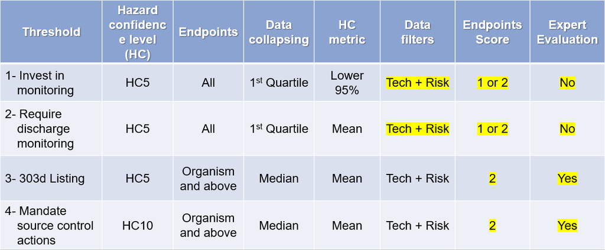

Agreed-upon framework

The figure above displays the working threshold framework for the ambient threshold group for the Microplastics Health Effects Workshop.

The current framework for generating SSDs includes the following parameters:

Data pertaining to only aquatic organisms are included (marine and freshwater).

All taxa are included with the exception of bacterium and plants.

HONEC (Highest Observed No Effect Concentration) are excluded.

Assessment factors are applied to convert all other effect metrics into NOECs:

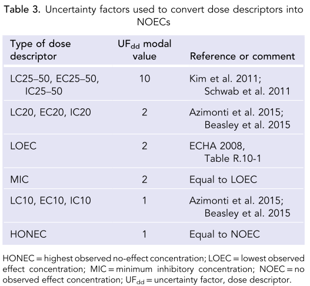

Reference: Wigger et al. 2020 (doi: 10.1002/ieam.4214)

Assessment factors are applied to convert acute data into chronic:

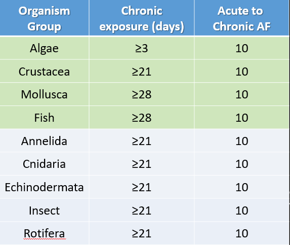

Green rows are from Wigger et al. 2020. Grey rows were agreed upon by the ambient threshold working group.

Reference: Wigger et al. 2020 (doi: 10.1002/ieam.4214)

Note: Values may be slightly different than those presented in the shiny app as concentrations are converted from particles/mL to particles/L ahead of calculations.

# 1 Illustrative Example

## 1.1 Re-scaling effect concentrations according to Ecological Relevent Metrics (ERMs)

### 1.1.1 Particles

A monodisperse effect concentration (e.g. 10 micron polyethylene fragments) may be re-scaled to a default size range (e.g. 1 - 5,000 microns) using methods described in Kooi et al (2021). Re-scaling to a default size range allows direct comparison to exposure concentrations for a default size range (which may also be re-scaled).

The effect concentration must first be corrected for bioavailability. If the suspected effect mechanism depends on ingestion of the particle, particles that are too large to be ingested by the organism of interest should be considered to not be bioavailable. Further, if toxicity depends on tissue translocation, particles too large to be translocated will be considered to be unavailable.

For an example, the tox database is queried to determine a real-world example. Studies in the database are filtered for all ‘red’ criteria, and only organismal and population-level biological organizations are considered, then default assessment metrics are applied.

```r
EC_mono <- aoc_z %>%
  filter(species == "magna") %>%
  filter(effect.metric == "NOEC") %>%
  filter(tier_zero_tech_f == "Red Criteria Passed",
         tier_zero_risk_f == "Red Criteria Passed",
         bio_f %in% c("Organism", "Population")) %>%
         mutate(dose_new = dose.particles.mL.master / (af.time * af.noec)) %>%
         drop_na(dose_new) %>%
         mutate(dose_new = dose_new * 1000) %>%
  summarize(min.NOEC.particles.L = min(dose_new)) %>%
  as.numeric()
```

The resulting real-life example of a *monodisperse* effect concentration is for a of a 40 um PE fragment for *C. Daphnia*. The minimum NOEC for acute mortality endpoints from these studies is:

```r
paste("40 um PE fragment Monodisperse Effect Concentration (C. Daphnia, acute mortality):", EC_mono, "(particles/L)")
```

```
## [1] "40 um PE fragment Monodisperse Effect Concentration (C. Daphnia, acute mortality): 1e+05 (particles/L)"
```

In order to convert the *monodisperse* effect concentration to a *polydisperse* mixture of microplastic particles, a correction must occur which takes into consideration the ecologically relevant metric (ERM) [(Koelmans et al 2017)](https://europepmc.org/article/med/28971682). For a given ERM, the threshold may be related to both mono- or polydisperse particles interchangeably so long as the total magnitude of ERM remains the same (Koelmans et al, 2020).

$EC_{poly} * \mu_{x,poly} = EC_{mono} * \mu_{x,mono}$

In this example of a monodisperse effect concentration for *C.Daphnia*, $EC_{mono}$ is in particle count per volume (i.e. 1e+05 particles/L), and $\mu_{x,mono}$ is the mean value of the ERM of interest in this study, which in the case of particle count, is 1.

```r
mu_x.mono = 1
```

Particles follow a power law regime in the marine environment, so $\mu_{x,poly}$ may be calculated using the following equation (equation 4, Kooi et al 2021):

$\mu_{x,poly} = \frac{1 - a_{x}}{2 - a_{x}} \frac{X^{2-a_x}_{UL} - X^{2-a_x}_{LL}}{X^{1-a_x}_{UL} - X^{1-a_x}_{LL}}$

Where $a_x$ relates to the power law distribution of microplastic particles in the marine environment (i.e. particle length; 2.07; Kooi et al 2021), and UL and LL are the upper and lower limits of bioavailability for this species/life stage/effect metric, respectively.

In this example, the organism of interest is *Cerodaphnia magna*, which has an average body length of 0.5 cm, and an estimated maximum ingestible size range of 115 um particles, $L_{UL,m}$ would be equivalent to 115 um, and $L_{LL,m}$ would be the lower size range of the bin for which the SSD is built- in this example, 1 um as a lower limit.

$\mu_{x,poly}$ for particles for the 1-115 um fraction in the marine environment is then calculated:

```r
###### if alpha does not equal 2 #####
mux.polyfnx = function(a.x,
                       x_UL,
                       x_LL){
  mux.poly = ((1-a.x)/(2-a.x)) * ((x_UL^(2-a.x) - x_LL^(2-a.x))/(x_UL^(1-a.x) - x_LL^(1-a.x)))
  return(mux.poly)}

#define parameters for C.daphnia
upper.ingestible.length.um = 115
lower.ingestible.length.um = 1

# marine surface water alpha for length
alpha = 2.07

#compute
mu_x.poly <- mux.polyfnx(a.x = alpha,
                         x_UL = upper.ingestible.length.um,
                         x_LL = lower.ingestible.length.um)
#report
paste("mu_x_poly:", round(mu_x.poly,2))
```

```
## [1] "mu_x_poly: 4.35"
```

Now that $\mu_{x,poly}$, $\mu_{x,mono}$, and $EC_{mono}$ are known for this example, the *bioavailable* *polydisperse* effect concentration $EC_{poly}$ may then be calculated using the equation:

$EC_{poly} = \frac{EC_{mono} * \mu_{x,mono}}{\mu_{x,poly}}$

```r
EC_poly <- (EC_mono * mu_x.mono)/mu_x.poly
paste("EC_poly:",signif(EC_poly,5), "particles/L")
```

```
## [1] "EC_poly: 23004 particles/L"
```

Now that the *bioavailable*, *polydisperse* effect concentration is known for this example, in order to relate this threshold effect concentration to an *environmentally relevant* (e.g. 1 - 5,000 um) range of particles ($EC_{env}$; particles/L) a further correction must occur using the following equation (equation 2; Kooi et al 2021):

$EC_{env} = EC_{poly} * CF_{bio}$

Where $CF_{bio}$ is a dimensionless correction factor for the bioavailable effect concentration. This equation rescales the bioavailable effect concentration (particles/L) to an environmentally relevant concentration for the microplastics default (D) size range (e.g. 1 to 5,000 um) according to the power law distribution for length (L) with slope $\alpha_L$ in Table S4 of Kooi et al (2021). $CF_{bio}$ is calculated as follows (Kooi et al 2021):

$CF_{bio} = \frac{L^{1-a}_{UL,D} - L^{1-a}_{LL,D}}{L^{1-a}_{UL,B} - L^{1-a}_{LL,B}}$

In this example, the organism of interest is *Cerodaphnia magna*, which has an average body length of 0.5 cm, and an estimated maximum ingestible size range of 115 um particles, $L_{UL,B}$ would be equivalent to 115 um, and $L_{LL,B}$ would be the lower size range of the bin for which the SSD is built- in this example, 1 um as a lower limit. Further, the upper limit (UL,D) and lower limit (LL,D) of the default size range are 5,000 and 1 um, respectively.

```r
#function to derive correction factor (CF) from Koelmans et al (equation 2)
CFfnx = function(a, #default alpha from Koelmans et al (2020)
                 x2D, #set detault values to convert ranges to (1-5,000 um) #5mm is upper defuault
                 x1D, #1 um is lower default size
                 x2M, x1M){

  CF = (x2D^(1-a)-x1D^(1-a))/(x2M^(1-a)-x1M^(1-a))

  return(CF)
}
### Define params for ###
alpha = alpha #table s4 for freshwater surface water
x2D_set = 5000
x1D_set = 1
x2M = 115
x1M = 1

# calculate CF_bio
CF_bio <- CFfnx(a = alpha,
                x2D = x2D_set,
                x1D = x1D_set,
                x1M = x1M,
                x2M = x2M)
paste("CF_bio = ",signif(CF_bio,4), "(unitless)")
```

```
## [1] "CF_bio =  1.006 (unitless)"
```

Finally, the $EC_{env}$ is calculated for particles/L as an ERM:

```r
EC_env <- EC_poly * CF_bio
paste("EC_env = ",signif(EC_env,4), "Particles/L (1-5,000 um; marine surface water )")
```

```
## [1] "EC_env =  23150 Particles/L (1-5,000 um; marine surface water )"
```

### 1.1.2 Volume

In the case of an ERM of interest being volume, $\mu_{x,mono}$ is equivalent to the average volume of a the monodisperse particle (i.e. $\mu_{v,mono}$), calculated as follows:

$\mu_{v,mono} = V_{i} = \frac{4}{3}\pi abc$

Where $V_i$ is the volume for a given particle *i*, and a, b, and c are radii along the principal axes, corresponding to one-half times the length, width, and height of an ellipsoid. Upper and lower limits of bioavailability for volume correspond to the maximum ingestible size of particles and the lower limit of the size range to be aligned to (typically 1 micron).

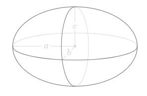

Image source: Wikipedia.com

The above equation can be applied to fragments, thin films, microbeads, spheres, or fibers given a known length to width ratios for such shapes, with the height assumed to be equivalent to 0.67 x width (Kooi et al 2021). Width to length ratios differ for microplastics differ by compartment, with averages ranging from 0.67 to 0.77 (Kooi et al 2021; Table S3). Averaged values may be used to estimate the volume of polydisperse environmental mixtures of microplastics.

Substituting $R_i$ for the length to width ratio of a particles, the formula simplifies to:

$V_i = 0.111667*pi*R_i^2*L_i^3$

Where $L_i$ is the length of the particle (um) and $R_i$ is the width:length ratio of the particle (unitless).

For the example of a 10 um PE fragment, the length was reported ($L_i = 10 \mu m$), however the width was not reported by the authors, so a default value of 0.77 is used, which is the average for marine surface water ($R_i = 0.77$).

$\mu_{v,mono}$ is calculated:

```r
volumefnx = function(R, L){
  volume = 0.111667 * pi * R^2 * L^3 #assumes height = 0.67 * Width, and Width:Length ratio is 'R' (compartment-specific)
  return(volume)}

mu_v.mono = volumefnx(R = 0.77,
                      L = 10)
paste("mu_v.mono = ", signif(mu_v.mono,3), "um^3")
```

```
## [1] "mu_v.mono =  208 um^3"
```

$\mu_{v,poly}$ is then calculated using the volume of particles that are bioaccessible (based on mouth opening and particle length), the volume of particles for the lower limit of the size range of interest.

As discussed above, for the example of an organism of interest of *Cerodaphnia magna*, the estimated maximum ingestible size range is 115 um particles, $L_{UL,m}$ would be equivalent to 115 um, and $L_{LL,m}$ would be the lower size range of the bin for which the SSD is built- in this example, 1 um as a lower limit. Volumetric limits are calculated:

```r
R.ave = 0.77

x_LL_v = volumefnx(R = R.ave,
                      L = lower.ingestible.length.um)
x_UL_v = volumefnx(R = R.ave,
                      L = upper.ingestible.length.um)

paste("x_UL_v = ",signif(x_UL_v,3), "um^3",
      ";x_LL_v = ", signif(x_LL_v,3), "um^3")
```

```
## [1] "x_UL_v =  316000 um^3 ;x_LL_v =  0.208 um^3"
```

$\mu_{v,poly}$ may now be calculated given these limits, using an alpha value of 1.48 for volume in the marine surface water environment (Kooi et al 2021):

```r
a.v = 1.48
#compute
mu_v.poly <- mux.polyfnx(a.x = a.v,
                         x_UL = x_UL_v,
                         x_LL = x_LL_v)
#report
paste("mu_v_poly:", round(mu_v.poly,2), "um^3")
```

```
## [1] "mu_v_poly: 314.91 um^3"
```

Now that $\mu_{v,poly}$, $\mu_{v,mono}$, and $EC_{mono}$ are known for this example for volume, the *bioavailable* *polydisperse* effect concentration $EC_{poly}$ for the volume ERM may then be calculated:

```r
EC_poly_v <- (EC_mono * mu_v.mono)/mu_v.poly
paste("EC_poly_v:",signif(EC_poly_v,5), "particles/L")
```

```
## [1] "EC_poly_v: 66050 particles/L"
```

Again, to relate this *bioavailable*, *polydisperse* effect threshold ($EC_{poly,v}$) to an environmentally relevant *polydisperse* mixture of particles for the volume ERM, an additional correction must be applied to rescale the threshold to the size range of interest (e.g. 1-5,000 um) using $CF_{bio}$, identical as for particles.

```r
EC_env_v <- EC_poly_v * CF_bio
paste("EC_env_v = ",signif(EC_env_v,4), "Particles/L (1-5,000 um; marine surface water )")
```

```
## [1] "EC_env_v =  66460 Particles/L (1-5,000 um; marine surface water )"
```

### 1.1.3 Surface Area

For surface area as an ERM, $\mu_{sa,mono}$ is equivalent to the average surface area ($SA$) of the *monodisperse* particle for the effect threshold, calculated as follows:

$\mu_{sa,mono} = SA = 4 \pi (\frac{(ab)^{1.6} + (ac)^{1.6} + (bc)^{1.6}}{3})^{1/1.6}$

With a, b, c being equal to 0.5x length, 0.5x width, and 0.5x height, respectively.

For the example of a 10 um PE fragment, the length was reported ($a = 0.5* 10 \mu m$), however the width was not reported by the authors, so a default value of 0.77 is used ($b = 0.5 * 0.77 * 10 \mu m$), which is the average for marine surface water, and height is assumed to be 0.67 times the width ($c = 0.5 * 0.77 * 0.67 * 10 \mu m$) (Kooi et al 2021). Surface area is calculated:

```r
#surface area equation
SAfnx = function(a,
                 b,
                 c){
  SA = 4*pi*(((a*b)^1.6 + (a*c)^1.6 + (b*c)^1.6) / 3)^(1/1.6)
    return(SA)}
#calculate for 10 um fragment
mu_sa.mono = SAfnx(a = 0.5 * 10,
                   b = 0.5 * 0.77 * 10,
                   c = 0.5 * 0.77 * 0.67 * 10)

paste("mu_sa.mono = ", signif(mu_sa.mono,3), "um^2")
```

```
## [1] "mu_sa.mono =  180 um^2"
```

Since the probability distribution of ERM $sa$ (surface area) follows a power law regime, the mean ERM value for the polydisperse particles, $\mu_{sa,poly}$, can be calculated. For surface area of environmentally disperse particles, UL and LL are calculated using the equation for the surface area of an ellipsoid (above).

```r
# calculate lower
x_LL_sa = SAfnx(a = 0.5 * lower.ingestible.length.um,
                b = 0.5 * 0.77 * lower.ingestible.length.um,
                c = 0.5 * 0.77 * 0.67 *lower.ingestible.length.um)

# calculate lower
x_UL_sa = SAfnx(a = 0.5 * upper.ingestible.length.um,
                b = 0.5 * 0.77 * upper.ingestible.length.um,
                c = 0.5 * 0.77 * 0.67 *upper.ingestible.length.um)

paste("x_UL = ",round(x_UL_sa,2), "um^2",
      ";x_LL = ", round(x_LL_sa,2), "um^2")
```

```
## [1] "x_UL =  23838.26 um^2 ;x_LL =  1.8 um^2"
```

```r
a.sa = 1.5
#compute
mu_sa.poly <- mux.polyfnx(a.x = a.sa,
                         x_UL = x_UL_sa,
                         x_LL = x_LL_sa)
#report
paste("mu_sa_poly:", round(mu_sa.poly,2), "um^2")
```

```
## [1] "mu_sa_poly: 207.29 um^2"
```

Now that $\mu_{v,poly}$, $\mu_{v,mono}$, and $EC_{mono}$ are known for this example for surface area, the *bioavailable* *polydisperse* effect concentration $EC_{poly}$ for the surface area ERM may then be calculated:

```r
EC_poly_sa <- (EC_mono * mu_sa.mono)/mu_sa.poly
paste("EC_poly_sa:",signif(EC_poly_sa,5), "particles/L")
```

```
## [1] "EC_poly_sa: 86957 particles/L"
```

Again, to relate this *bioavailable*, *polydisperse* effect threshold ($EC_{poly,sa}$) to an environmentally relevant *polydisperse* mixture of particles for the surface area ERM, an additional correction must be applied to rescale the threshold to the size range of interest (e.g. 1-5,000 um) using $CF_{bio}$, identical as for particles.

```r
EC_env_sa <- EC_poly_sa * CF_bio
paste("EC_env_sa = ",signif(EC_env_sa,4), "Particles/L (1-5,000 um; marine surface water )")
```

```
## [1] "EC_env_sa =  87490 Particles/L (1-5,000 um; marine surface water )"
```

### 1.1.4 Mass

In the case of an ERM of interest being total mass, $\mu_{x,mono}$ is equivalent to the average mass of a the monodisperse particle (i.e. $\mu_{m,mono}$), calculated as follows:

$\mu_{m,mono} = m = pV*\frac{1}{1e12}*1e6$

For the example of a 10 um polyethylene fragment, the volume was calculated above (~ $207 um^3$), and the density of polyethylene was is estimated to be 0.935 g/cm^3. $\mu_{x,mono}$ is calculated:

```r
massfnx = function(R, L, p){
  mass = p * #density (g/cm^3)
    0.111667 * pi * R^2 * L^3 * # volume (um^3): assumes height = 0.67 * Width, and Width:Length ratio is 'R' (compartment-specific)
    1/1e12 * 1e6 #correction factor
  return(mass)}

mu_m.mono <- massfnx(R = 0.77,  L = 10, p = 0.935)
paste("mu_m,mono:", signif(mu_m.mono,3),"ug")
```

```
## [1] "mu_m,mono: 0.000194 ug"
```

Since the probability distribution of ERM $m$ (mass) follows a power law regime, the mean ERM value for the polydisperse particles, $\mu_{m,poly}$, can be calculated by first calculating the lower and upper ingestible masses of particles based on the length of the ingestible particle. The UL and LL are respectively defined as the upper and lower limit in ERM $m$ (mass) for which the mean is calculated, and $a_m$ is the power law exponent of mass. In the case of marine surface water,an $a_m$ of 1.32 is utilized (Kooi et al 2021; Table S4).

For mass, UL and LL are mass-based upper and lower limits of bioaccessibility based on the width of particles, respectively. To estimate mass-based limits based on size, the volume of bioaccessible particles is first calculated using the equation for the volume of an ellipsoid, then multipied by the average density of particles in the 1-5,000 um distribution in the environmental compartment of interest (e.g.surface marine water: 1.10 g/cm^3) (Kooi et al 2021; table S3).

```r
p.ave = 1.1

#lower limit
x_LL_m = massfnx(R = R.ave, #width to length ratio
               L = lower.ingestible.length.um, #lower bioaccessible length
               p = p.ave) #average density
#upper limit
x_UL_m = massfnx(R = R.ave, #width to length ratio
               L = upper.ingestible.length.um, #upper bioaccessible length
               p = p.ave) #average density

paste("x_UL = ",signif(x_UL_m,2), "ug",
      ";x_LL = ", signif(x_LL_m,2), "ug")
```

```
## [1] "x_UL =  0.35 ug ;x_LL =  2.3e-07 ug"
```

$\mu_{m,poly}$ may now be calculated given these limits, using an alpha value of $a_m$ of 1.32 for the marine surface water environment (Kooi et al 2021):

```r
a.m = 1.32
#compute
mu_m.poly <- mux.polyfnx(a.x = a.m,
                         x_UL = x_UL_m,
                         x_LL = x_LL_m)
#report
paste("mu_m_poly:", signif(mu_m.poly,2), "ug")
```

```
## [1] "mu_m_poly: 0.0017 ug"
```

Now that $\mu_{m,poly}$, $\mu_{m,mono}$, and $EC_{mono}$ are known for this example for mass, the *bioavailable* *polydisperse* effect concentration $EC_{poly}$ for the mass ERM may then be calculated:

```r
EC_poly_m <- (EC_mono * mu_m.mono)/mu_m.poly
paste("EC_poly_m:",signif(EC_poly_m,5), "particles/L")
```

```
## [1] "EC_poly_m: 11179 particles/L"
```

Again, to relate this *bioavailable*, *polydisperse* effect threshold ($EC_{poly,sa}$) to an environmentally relevant *polydisperse* mixture of particles for the mass ERM, an additional correction must be applied to rescale the threshold to the size range of interest (e.g. 1-5,000 um) using $CF_{bio}$, identical as for particles.

```r
EC_env_m <- EC_poly_m * CF_bio
paste("EC_env_m = ",signif(EC_env_m,4), "Particles/L (1-5,000 um; marine surface water)")
```

```
## [1] "EC_env_m =  11250 Particles/L (1-5,000 um; marine surface water)"
```

### 1.1.5 Specific Surface Area

In the case of an ERM of interest being specific surface area, $\mu_{ssa,mono}$ is equivalent to the surface area of a 5 um PS sphere (i.e. $\mu_{sa,mono}$) divided by the mass (i.e. $\mu_{m,mono}$), calculated as follows:

$\mu_{sa,mono} = SSA = \frac{SA}{m}$

Where *SA* is the surface area (um^2) of the particle, and *m* is the mass (ug).

```r
mu_ssa.mono = mu_sa.mono/mu_m.mono
paste("mu_ssa,mono:", formatC(mu_ssa.mono,format = "e", digits = 2),"um^2/ug")
```

```
## [1] "mu_ssa,mono: 9.27e+05 um^2/ug"
```

Since the probability distribution of ERM $ssa$ (specific surface area) follows a power law regime, the mean ERM value for the polydisperse particles, $\mu_{ssa,poly}$, can be calculated, where UL and LL are respectively defined as the upper and lower limit in ERM $ssa$ (ssa) for which the mean is calculated, and $a_ssa$ is the power law exponent of specific surface area. For example, marine surface water has an $a_ssa$ of 1.98 (Kooi et al 2021; Table S4). For specific surface area, UL and LL are area/mass-based upper and lower limits of bioaccessibility based on the width of particles, respectively. To estimate area/mass-based limits based on size, the volume of bioaccessible particles is first calculated using the equation for the surface area of an ellipsoid, then divided by the lower and upper bioavailable mass of particles in the 1-5,000 um distribution in surface marine water, as calculated above.

```r
#max ingestible specific surface area
SSAfnx = function(sa,
                  m){
  SSA = sa/m
    return(SSA)}

#calculate
x_LL_ssa = SSAfnx(sa = x_LL_sa, m = x_LL_m)
x_UL_ssa = SSAfnx(sa = x_UL_sa, m = x_UL_m)

#report
paste("x_UL_ssa = ", signif(x_UL_ssa,3), "um^2/ug",
      ";x_LL_ssa = ", signif(x_LL_ssa,3), "um^2/ug")
```

```
## [1] "x_UL_ssa =  68500 um^2/ug ;x_LL_ssa =  7880000 um^2/ug"
```

$\mu_{m,poly}$ may now be calculated given these limits, using an alpha value of $a_ssa$ of 1.98 for the marine surface water environment (Kooi et al 2021):

```r
a.ssa = 1.98 # A_SSA for marine surface water

mu_ssa.poly <- mux.polyfnx(a.x = a.ssa,
            x_UL = x_UL_ssa,
            x_LL = x_LL_ssa)

paste("mu_ssa,poly =",signif(mu_ssa.poly,3), "um^2/ug")
```

```
## [1] "mu_ssa,poly = 337000 um^2/ug"
```

Now that $\mu_{ssa,poly}$, $\mu_{ssa,mono}$, and $EC_{mono}$ are known for this example for specific surface area, the *bioavailable* *polydisperse* effect concentration $EC_{poly}$ for the specific surface area ERM may then be calculated:

```r
EC_poly_ssa <- (EC_mono * mu_ssa.mono)/mu_ssa.poly
paste("EC_poly_ssa:",signif(EC_poly_ssa,5), "particles/L")
```

```
## [1] "EC_poly_ssa: 274710 particles/L"
```

Again, to relate this *bioavailable*, *polydisperse* effect threshold ($EC_{poly,ssa}$) to an environmentally relevant *polydisperse* mixture of particles for the specific surface area ERM, an additional correction must be applied to rescale the threshold to the size range of interest (e.g. 1-5,000 um) using $CF_{bio}$, identical as for particles.

```r
EC_env_ssa <- EC_poly_ssa * CF_bio
paste("EC_env_ssa = ",signif(EC_env_ssa,4), "Particles/L (1-5,000 um; marine surface water)")
```

```
## [1] "EC_env_ssa =  276400 Particles/L (1-5,000 um; marine surface water)"
```

## 1.2 Aligning Occurence Data for Risk Characterization

Given an upper limit (UL) and lower limit (LL) of the measured (M) and default size range (D), a dimensionless correction factor ($CF_{meas}$) for measured environmental concentrations may be calculated, which rescales the measured (M) number concentrations for a certain size range to the number concentration for the microplastics default (D) size range (e.g. 1 to 5,000 um) according to the power law distribution for length (L) with slope $\alpha_L$ in Table S4 of Kooi et al (2021).

The following equation for $CF_{meas}$ is identical for effect concentration ($CF_{Bio}$) except the bioavailable fraction of particles is denoted as UL,B and LL,B on the denominator (Koelmans et al., 2020; Kooi et al., 2021).

$CF_{Meas} = \frac{L^{1-a}_{UL,D} - L^{1-a}_{LL,D}}{L^{1-a}_{UL,M} - L^{1-a}_{LL,M}}$

For example, a marine surface water concentration of 10 particles/L for 300 - 5,000 um is used.

```r
C_meas = 10
paste("C_meas =",C_meas, "particles/L (300 - 5,000 um; marine surface water)")
```

```
## [1] "C_meas = 10 particles/L (300 - 5,000 um; marine surface water)"
```

To compare this concentration to the environmentally relevant (1 - 5,000 um) effect threshold (EC_env) in particles/L (calculated above), $CF_{meas}$ is first calculated.

```r
### Define params for ###
alpha = alpha #table s4 for freshwater surface water
x2D_set = 5000
x1D_set = 1
x2M = 5000
x1M = 300

# calculate CF_bio
CF_meas <- CFfnx(a = alpha,
                x2D = x2D_set,
                x1D = x1D_set,
                x1M = x1M,
                x2M = x2M)
paste("CF_meas = ",signif(CF_meas,4), "(unitless)")
```

```
## [1] "CF_meas =  470.3 (unitless)"
```

The resulting correction factor ($CF_{meas}$ (unitless) is then multiplied by the measured concentration ($C_{Meas}$) to obtain a rescaled exposure number concentration $C_{Env} = CF_{meas} x C_{meas}$.

```r
C_env <- CF_meas * C_meas
paste("C_env =",signif(C_env,4), "particles/L (1 - 5,000 um; marine surface water)")
```

```
## [1] "C_env = 4703 particles/L (1 - 5,000 um; marine surface water)"
```

This measured rescaled environmental concentration $C_{env}$ may then be directly compared to the rescaled effect thresholds for various ERM $EC_{env,x}$ to determine if risk is present using the traditional PNEC/PEC formula:

```r
risk <- tibble('ERM' = c("Particles", "Volume", "Surface Area", "Mass", "Specific Surface Area"),
               'EC_env' = c(EC_env, EC_env_v, EC_env_sa, EC_env_m, EC_env_ssa)) %>%
  mutate('PNEC/PEC' = EC_env / C_env)

# build gt table
full_val_range_1 <- risk %>%
    ungroup %>%
    select_if(is.numeric) %>%
    range

gt(risk) %>%
  tab_header(title = "1-5,000 um Thresholds (Aligned) Compared to Environmental Concentration
             (4,703 particles/L)",
             subtitle = "Thresholds presented in particles/L") %>%
  fmt_number(columns = vars(EC_env, 'PNEC/PEC'),
             n_sigfig = 2,
             use_seps = TRUE) %>%
    data_color(
    columns = names(risk)[2:3],
    colors = scales::col_numeric(
      palette = paletteer::paletteer_d(palette = "ggsci::teal_material") %>% as.character(),
      domain = full_val_range_1),
    alpha = 0.75) %>%
    tab_options(column_labels.hidden = FALSE) #%>%
```

1-5,000 um Thresholds (Aligned) Compared to Environmental Concentration (4,703 particles/L)

Thresholds presented in particles/L

| ERM | EC_env | PNEC/PEC |
| --- | --- | --- |
| Particles | 23,000 | 4.9 |
| Volume | 66,000 | 14 |
| Surface Area | 87,000 | 19 |
| Mass | 11,000 | 2.4 |
| Specific Surface Area | 280,000 | 59 |

```r
    #as_raw_html() # return as htmlk
```

The above approach used for particles as an ecologically relevent metric may be applied for any other ecologically relevent metric for which particle distributions are characterized in the environmental compartment of interest. Below are proofs for additional ERM, including surface area, volume, mass, and specific surface area.

# 2 ERM/SSD Calculations

The following script utilizes the above equations to calculate *a priori* effect thresholds for each of the ERM of interest for each species in the database, then calculates species sensitivity distributions using each ERM.

*Data Filtering by Quality*

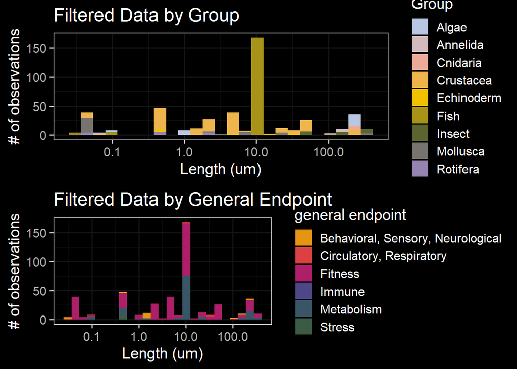

```r
## First filter data with global filters
aoc_intermediate <- aoc_z %>%
  filter(!environment %in% c("Terrestrial", "Not Reported"),
         org_f != "Bacterium",
         org_f != "Plant",
         effect.metric != "HONEC",
         tier_zero_tech_f == "Red Criteria Passed",
         tier_zero_risk_f == "Red Criteria Passed", #All thresholds must pass technical and risk red criteria
         risk.13 != 0) #Drop studies that received a score of 0 for endpoints criteria (this also drops studies that have not yet been scored) - KEEP THIS AFTER THE RED CRITERIA FILTERS
#### Ecologically Relevant Metric calculations ####

#examine available data as histogram
Group_size <- aoc_intermediate %>%
  ggplot(aes(x = size.length.um.used.for.conversions, fill = Group)) +
  geom_histogram(bins = 25) +
  scale_fill_manual(values = cal_palette(name = "superbloom1", type = "continuous", n = 9)) +
  labs(title = "Filtered Data by Group") +
  ylab("# of observations")+
  xlab("Length (um)") +
  theme.type +
  scale_x_log10()

endpoint_size <- aoc_intermediate %>%
  ggplot(aes(x = size.length.um.used.for.conversions, fill = lvl1_f)) +
  geom_histogram(bins = 25) +
   scale_fill_manual(name = "general endpoint", values = cal_palette(name = "superbloom3", type = "continuous", n = 9)) +
  xlab("Length (um)") +
  ylab("# of observations")+
  labs(title = "Filtered Data by General Endpoint") +
  theme.type +
  scale_x_log10()

#arrange histograms
grid.arrange(Group_size, endpoint_size)
```

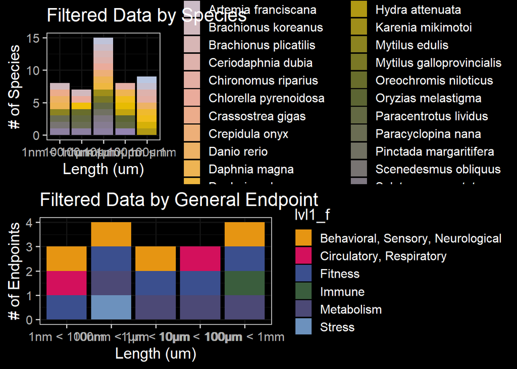

```r
#examine available data as bar plots
species_size_f <- aoc_intermediate %>%
  distinct(Species, size_f) %>%
  ggplot(aes(x = size_f, fill = Species)) +
  geom_bar() +
  scale_fill_manual(values = cal_palette(name = "superbloom1", type = "continuous", n = 34)) +
  labs(title = "Filtered Data by Species") +
  xlab("Length (um)") +
  ylab("# of Species")+
  theme.type


endpoint_size_f <- aoc_intermediate %>%
   distinct(lvl1_f, size_f) %>%
  ggplot(aes(x = size_f, fill = lvl1_f)) +
  geom_bar() +
  scale_fill_manual(values = cal_palette(name = "superbloom3", type = "continuous", n = 6)) +
  labs(title = "Filtered Data by General Endpoint") +
  ylab("# of Endpoints")+
  xlab("Length (um)") +
  theme.type

#arrange histograms
grid.arrange(species_size_f, endpoint_size_f)
```

Do these size bins make sense for the endpoints of interest? I.e.food dilution and ROS.

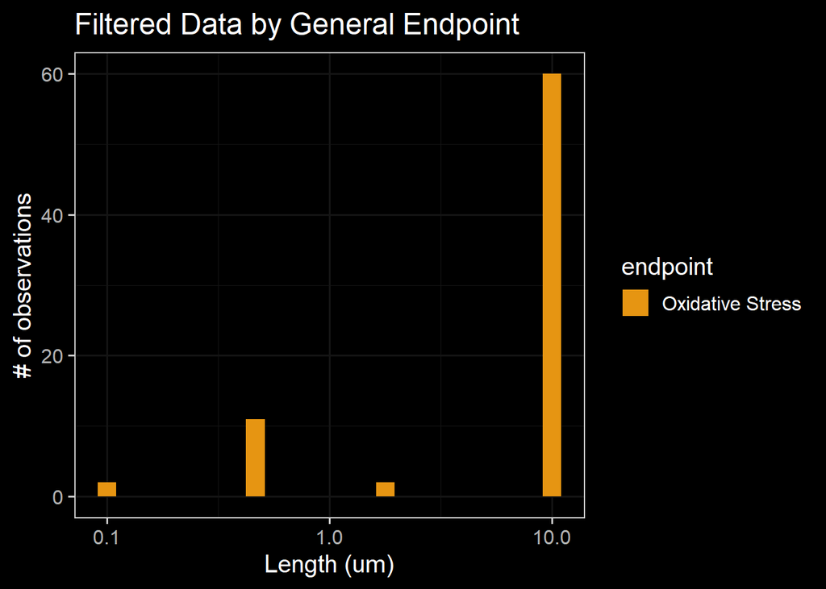

```r
# determine if ROS is shown for any studies (no filtering)
ROS_size <- aoc_intermediate %>%
  filter(lvl2_f %in% "Oxidative Stress") %>%
  ggplot(aes(x = size.length.um.used.for.conversions, fill = lvl2_f)) +
  geom_histogram(bins = 25) +
   scale_fill_manual(name = "endpoint", values = cal_palette(name = "superbloom3", type = "continuous", n = 9)) +
  xlab("Length (um)") +
  ylab("# of observations")+
  labs(title = "Filtered Data by General Endpoint") +
  theme.type +
  scale_x_log10()

ROS_size
```

*Data Alignments*

```r
###function to derive correction factor (CF) from Koelmans et al (equation 2)
CFfnx = function(a, #default alpha from Koelmans et al (2020)
                 x2D, #set detault values to convert ranges to (1-5,000 um) #5mm is upper defuault
                 x1D, #1 um is lower default size
                 x2M, x1M){
  CF = (x2D^(1-a)-x1D^(1-a))/(x2M^(1-a)-x1M^(1-a))
  return(CF)}

#### equations for mu_x_poly (note that there are three depending on certain alphas for limits of equation)
###### if alpha does not equal 2 #####
mux.polyfnx = function(a.x,
                       x_UL,
                       x_LL){
  mux.poly = ((1-a.x)/(2-a.x)) * ((x_UL^(2-a.x) - x_LL^(2-a.x))/(x_UL^(1-a.x) - x_LL^(1-a.x)))
  return(mux.poly)}

##### If alpha does equal 2 #####
mux.polyfnx.2 = function(x_UL,x_LL){
  mux.poly = (log(x_UL/x_LL))/(x_LL^(-1) - x_UL^-1)
  return(mux.poly)}

### Calculating max ingestible parameters ###
## function to calcualte min and max ingestible surface area ##
SAfnx = function(a, # a = 0.5 * length
                 b, # b = 0.5 * width
                 c # c = 0.5 * height (note that hieght is 0.67 * width)
){
  SA = 4*pi*(((a*b)^1.6 + (a*c)^1.6 + (b*c)^1.6) / 3)^(1/1.6)
  return(SA)}

## max ingestible volume ##
volumefnx = function(R, L){
  volume = 0.111667 * pi * R^2 * L^3 #assumes height = 0.67 * Width, and Width:Length ratio is 'R' (compartment-specific)
  return(volume)}

#max ingestible mass
massfnx = function(R, L, p){
  mass = p * #density (g/cm^3)
    0.111667 * pi * R^2 * L^3 * # volume (um^3): assumes height = 0.67 * Width, and Width:Length ratio is 'R' (compartment-specific)
    1/1e12 ### NOT SURE IF THIS IS CORREC
   1e6 #correction factor
  return(mass)}

#max ingestible specific surface area
SSAfnx = function(sa, #surface area, calcaulted elsewhere
                  m){ #mass, calculated elsewhere
  SSA = sa/m
    return(SSA)}

## parametrization ##
# Define params for correction #
alpha = 2.07 #table s4 for marine surface water. length
# define parameters for power law coefficients
a.sa = 1.5 #marine surface area power law
a.v = 1.48 #a_V for marine surface water volume
a.m = 1.32 # upper limit fora_m for mass for marine surface water in table S4
a.ssa = 1.98 # A_SSA for marine surface water

#define additional parameters for calculations based on averages in the environment
R.ave = 0.77 #average width to length ratio for microplastics in marine enviornment
p.ave = 1.10 #average density in marine surface water


##### SMALL TIER DATA ####
### Set size limits for tier
x2D_set = small_tier_upper_size #upper size range (default)
x1D_set = small_tier_lower_size #lower size range (default)
x1M_set = small_tier_lower_size #lower size range for measured

# calculate ERM for each species
aoc_final_small <- aoc_intermediate  %>%
  # define upper size length for ingestion
  mutate(x2M = 10) %>% #set to 10um for upper limit
 # calculate effect threshold for particles
  mutate(EC_mono_p.particles.mL = dose.particles.mL.master) %>%
  mutate(mu.p.mono = 1) %>% #mu_x_mono is always 1 for particles to particles
  mutate(mu.p.poly = mux.polyfnx(a.x = alpha, #alpha for particles
                                 x_UL= x2M, #upper ingestible size limit
                                 x_LL = x1M_set)) %>%
  # polydisperse effect threshold for particles
  mutate(EC_poly_p.particles.mL = (EC_mono_p.particles.mL * mu.p.mono)/mu.p.poly) %>%
   #calculate CF_bio for all conversions
  mutate(CF_bio = CFfnx(x1M = x1M_set,#lower size bin
                        x2M = x2M, #upper ingestible
                        x1D = x1D_set, #default
                        x2D = x2D_set,  #default
                        a = alpha)) %>%
  ## Calculate environmentally relevant effect threshold for particles
  mutate(EC_env_p.particles.mL = EC_poly_p.particles.mL * CF_bio) %>%  #aligned particle effect concentraiton (1-5000 um)

  #### Surface area ERM ####
  mutate(mu.sa.mono = particle.surface.area.um2) %>% #define mu_x_mono for alignment to ERM
  #calculate lower ingestible surface area
  mutate(x_LL_sa = SAfnx(a = 0.5 * x1D_set,
                         b = 0.5 * R.ave * x1D_set,
                         c = 0.5 * R.ave * 0.67 * x1D_set)) %>%
  #calculate upper ingestible surface area
  mutate(x_UL_sa = SAfnx(a = 0.5 * x2M,
                         b = 0.5 * R.ave *x2M,
                         c = 0.5 * R.ave * 0.67 * x2M)) %>%
  #calculate mu_x_poly for surface area
  mutate(mu.sa.poly = if(a.sa == 2){mux.polyfnx.2(x_UL_sa, x_LL_sa)} else if (a.sa != 2){mux.polyfnx(a.sa, x_UL_sa, x_LL_sa)}) %>%
  #calculate polydisperse effect concentration for surface area (particles/mL)
  mutate(EC_poly_sa.particles.mL = (EC_mono_p.particles.mL * mu.sa.mono)/mu.sa.poly) %>%
  #calculate environmentally realistic effect threshold
  mutate(EC_env_sa.particles.mL = EC_poly_sa.particles.mL * CF_bio) %>%

  #### volume ERM ####
#define mu_x_mono for alignment to ERM
  mutate(mu.v.mono = particle.volume.um3) %>%
  #calculate lower ingestible volume
  mutate(x_LL_v = volumefnx(R = R.ave,
                            L = x1D_set)) %>%
  #calculate maximum ingestible volume
  mutate(x_UL_v = volumefnx(R = R.ave,
                            L = x2M)) %>%
  # calculate mu.v.poly
  mutate(mu.v.poly = if(a.v == 2){mux.polyfnx.2(x_UL_v, x_LL_v)} else if (a.v != 2){mux.polyfnx(a.v, x_UL_v, x_LL_v)}) %>%
  #calculate polydisperse effect concentration for volume (particles/mL)
  mutate(EC_poly_v.particles.mL = (EC_mono_p.particles.mL * mu.v.mono)/mu.v.poly) %>%
    #calculate environmentally realistic effect threshold
  mutate(EC_env_v.particles.mL = EC_poly_v.particles.mL * CF_bio) %>%

  #### mass ERM ###
  #define mu_x_mono for alignment to ERM (ug)
  mutate(mu.m.mono = mass.per.particle.mg * 1000) %>%
  #calculate lower ingestible mass
  mutate(x_LL_m = massfnx(R = R.ave, L = x1D_set, p = p.ave)) %>%
  #calculate upper ingestible mass
  mutate(x_UL_m = massfnx(R = R.ave, L = x2M, p = p.ave)) %>%
  # calculate mu.m.poly
  mutate(mu.m.poly = if(a.m == 2){mux.polyfnx.2(x_UL_m, x_LL_m)} else if (a.m != 2){mux.polyfnx(a.m, x_UL_m, x_LL_m)}) %>%
  #calculate polydisperse effect concentration for volume (particles/mL)
  mutate(EC_poly_m.particles.mL = (EC_env_p.particles.mL * mu.m.mono)/mu.m.poly) %>%
  #calculate environmentally realistic effect threshold
  mutate(EC_env_m.particles.mL = EC_poly_m.particles.mL * CF_bio) %>%

  ##### specific surface area ERM ####
  mutate(mu.ssa.mono = mu.sa.mono/mu.m.mono) %>% #define mu_x_mono for alignment to ERM (um^2/ug)
  #calculate lower ingestible SSA
  mutate(x_LL_ssa = SSAfnx(sa = x_LL_sa, #surface area
                           m = x_LL_m) #mass
         ) %>%
  #calculate upper ingestible SSA  (um^2/ug)
  mutate(x_UL_ssa = SSAfnx(sa = x_UL_sa, #surface area
                           m = x_UL_m) #mass
         ) %>%
  #calculate mu_x_poly for specific surface area
  mutate(mu.ssa.poly = if(a.ssa == 2){mux.polyfnx.2(x_UL_ssa, x_LL_ssa)} else if (a.ssa != 2){mux.polyfnx(a.ssa, x_UL_ssa, x_LL_ssa)}) %>%
  #calculate polydisperse effect concentration for specific surface area (particles/mL)
  mutate(EC_poly_ssa.particles.mL = (EC_env_p.particles.mL * mu.ssa.mono)/mu.ssa.poly) %>%
  #calculate environmentally realistic effect threshold
  mutate(EC_env_ssa.particles.mL = EC_poly_ssa.particles.mL * CF_bio)
```

```r
##### SMALL TIER DATA ####
### Set size limits for tier
x2D_set = large_tier_upper_size #upper size range (default)
x1D_set = large_tier_lower_size #lower size range (default)
x1M_set = large_tier_lower_size #lower size range for measured
# calculate ERM for each species

aoc_final_large <- aoc_intermediate  %>%
  # define upper size length for ingestion
  mutate(x2M = max.size.ingest.mm * 1000) %>% #max size ingest in um
 # calculate effect threshold for particles
  mutate(EC_mono_p.particles.mL = dose.particles.mL.master) %>%
  mutate(mu.p.mono = 1) %>% #mu_x_mono is always 1 for particles to particles
  mutate(mu.p.poly = mux.polyfnx(a.x = alpha, #alpha for particles
                                 x_UL= x2M, #upper ingestible size limit
                                 x_LL = x1M_set)) %>%
  # polydisperse effect threshold for particles
  mutate(EC_poly_p.particles.mL = (EC_mono_p.particles.mL * mu.p.mono)/mu.p.poly) %>%
   #calculate CF_bio for all conversions
  mutate(CF_bio = CFfnx(x1M = x1M_set,#lower size bin
                        x2M = x2M, #upper ingestible
                        x1D = x1D_set, #default
                        x2D = x2D_set,  #default
                        a = alpha)) %>%
  ## Calculate environmentally relevant effect threshold for particles
  mutate(EC_env_p.particles.mL = EC_poly_p.particles.mL * CF_bio) %>%  #aligned particle effect concentraiton (1-5000 um)

  #### Surface area ERM ####
  mutate(mu.sa.mono = particle.surface.area.um2) %>% #define mu_x_mono for alignment to ERM
  #calculate lower ingestible surface area
  mutate(x_LL_sa = SAfnx(a = 0.5 * x1D_set,
                         b = 0.5 * R.ave * x1D_set,
                         c = 0.5 * R.ave * 0.67 * x1D_set)) %>%
  #calculate upper ingestible surface area
  mutate(x_UL_sa = SAfnx(a = 0.5 * x2M,
                         b = 0.5 * R.ave *x2M,
                         c = 0.5 * R.ave * 0.67 * x2M)) %>%
  #calculate mu_x_poly for surface area
  mutate(mu.sa.poly = if(a.sa == 2){mux.polyfnx.2(x_UL_sa, x_LL_sa)} else if (a.sa != 2){mux.polyfnx(a.sa, x_UL_sa, x_LL_sa)}) %>%
  #calculate polydisperse effect concentration for surface area (particles/mL)
  mutate(EC_poly_sa.particles.mL = (EC_mono_p.particles.mL * mu.sa.mono)/mu.sa.poly) %>%
  #calculate environmentally realistic effect threshold
  mutate(EC_env_sa.particles.mL = EC_poly_sa.particles.mL * CF_bio) %>%

  #### volume ERM ####
#define mu_x_mono for alignment to ERM
  mutate(mu.v.mono = particle.volume.um3) %>%
  #calculate lower ingestible volume
  mutate(x_LL_v = volumefnx(R = R.ave,
                            L = x1D_set)) %>%
  #calculate maximum ingestible volume
  mutate(x_UL_v = volumefnx(R = R.ave,
                            L = x2M)) %>%
  # calculate mu.v.poly
  mutate(mu.v.poly = if(a.v == 2){mux.polyfnx.2(x_UL_v, x_LL_v)} else if (a.v != 2){mux.polyfnx(a.v, x_UL_v, x_LL_v)}) %>%
  #calculate polydisperse effect concentration for volume (particles/mL)
  mutate(EC_poly_v.particles.mL = (EC_mono_p.particles.mL * mu.v.mono)/mu.v.poly) %>%
    #calculate environmentally realistic effect threshold
  mutate(EC_env_v.particles.mL = EC_poly_v.particles.mL * CF_bio) %>%

  #### mass ERM ###
  #define mu_x_mono for alignment to ERM (ug)
  mutate(mu.m.mono = mass.per.particle.mg * 1000) %>%
  #calculate lower ingestible mass
  mutate(x_LL_m = massfnx(R = R.ave, L = x1D_set, p = p.ave)) %>%
  #calculate upper ingestible mass
  mutate(x_UL_m = massfnx(R = R.ave, L = x2M, p = p.ave)) %>%
  # calculate mu.m.poly
  mutate(mu.m.poly = if(a.m == 2){mux.polyfnx.2(x_UL_m, x_LL_m)} else if (a.m != 2){mux.polyfnx(a.m, x_UL_m, x_LL_m)}) %>%
  #calculate polydisperse effect concentration for volume (particles/mL)
  mutate(EC_poly_m.particles.mL = (EC_env_p.particles.mL * mu.m.mono)/mu.m.poly) %>%
  #calculate environmentally realistic effect threshold
  mutate(EC_env_m.particles.mL = EC_poly_m.particles.mL * CF_bio) %>%

  ##### specific surface area ERM ####
  mutate(mu.ssa.mono = mu.sa.mono/mu.m.mono) %>% #define mu_x_mono for alignment to ERM (um^2/ug)
  #calculate lower ingestible SSA
  mutate(x_LL_ssa = SSAfnx(sa = x_LL_sa, #surface area
                           m = x_LL_m) #mass
         ) %>%
  #calculate upper ingestible SSA  (um^2/ug)
  mutate(x_UL_ssa = SSAfnx(sa = x_UL_sa, #surface area
                           m = x_UL_m) #mass
         ) %>%
  #calculate mu_x_poly for specific surface area
  mutate(mu.ssa.poly = if(a.ssa == 2){mux.polyfnx.2(x_UL_ssa, x_LL_ssa)} else if (a.ssa != 2){mux.polyfnx(a.ssa, x_UL_ssa, x_LL_ssa)}) %>%
  #calculate polydisperse effect concentration for specific surface area (particles/mL)
  mutate(EC_poly_ssa.particles.mL = (EC_env_p.particles.mL * mu.ssa.mono)/mu.ssa.poly) %>%
  #calculate environmentally realistic effect threshold
  mutate(EC_env_ssa.particles.mL = EC_poly_ssa.particles.mL * CF_bio)
```

```r
ERM <- "Unaligned"
```

### 2.1.1 Tiers 1 & 2

Tier 1 and 2 are the same SSD. A different HC metric is selected to differentiate between the tiers. Specifically, Tier 1 uses the 95% CI whereas Tier 2 uses the Mean. See below for more details of specific parameters.

Hazard Confidence Level = HC5

Endpoints = All

Levels of Biological Organization = All

HC Metric = 95% CI (Tier 1); Mean (Tier 2)

Data Quality = Pass Technical Quality Red Criteria

#### 2.1.1.1 Data Filtering

```r
tier1_2_large <- aoc_final_large %>%
         mutate(dose_new = dose.particles.mL.master / (af.time * af.noec)) %>%
         drop_na(dose_new) %>%
         mutate(dose_new = dose_new * 1000) %>%
  filter(size.length.um.used.for.conversions %in% (1:5000))

# Count observations and studies
tier1_2_large.obs <- tier1_2_large %>% summarize(n.obs = n(), n.studies = n_distinct(doi), n.taxa = n_distinct(org_f), n.species = n_distinct(species_f))

# ### 10 - 100 um
# tier1_2_medium <- tier1_2 %>%
#   filter(size_f %in% c("10µm < 100µm"))
#
# # Count observations and studies
# tier1_2_medium.obs <- tier1_2_medium %>% summarize(n.obs = n(), n.studies = n_distinct(doi), n.taxa = n_distinct(org_f), n.species = n_distinct(species_f))

### 1 - 100 um
tier1_2_small <- aoc_final_small %>%
         mutate(dose_new = dose.particles.mL.master / (af.time * af.noec)) %>%
         drop_na(dose_new) %>%
         mutate(dose_new = dose_new * 1000) %>%
  filter(size.length.um.used.for.conversions %in% (1:10))

# Count observations and studies
tier1_2_small.obs <- tier1_2_small %>% summarize(n.obs = n(), n.studies = n_distinct(doi), n.taxa = n_distinct(org_f), n.species = n_distinct(species_f))
```

#### 2.1.1.2 Endpoint Representation

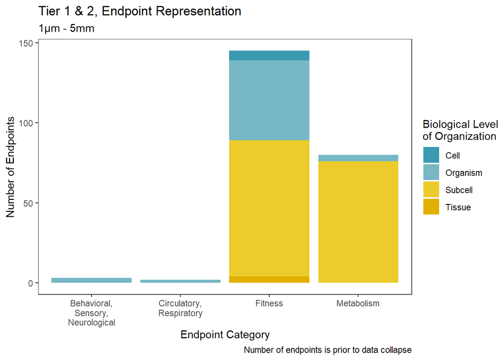

```r
#large
endpoints_tier1_2_large <- tier1_2_large %>%
  group_by(lvl1_f, bio_f) %>%
  mutate(lvl1_count = n()) %>%
  group_by(lvl1_f, lvl1_count, bio_f) %>%
  summarise() %>%
  ggplot(aes(x = lvl1_f, y=lvl1_count, fill = bio_f))+
  geom_bar(stat = "identity") +
  scale_fill_manual(values = wes_palette("Zissou1", 5, type = "continuous")) +
  labs(title = "Tier 1 & 2, Endpoint Representation", subtitle = "1µm - 5mm", x = "Endpoint Category", y = "Number of Endpoints", fill = "Biological Level\nof Organization", caption = "Number of endpoints is prior to data collapse") +
  theme_test() +
  scale_x_discrete(labels = wrap_format(10))


plot(endpoints_tier1_2_large)
```

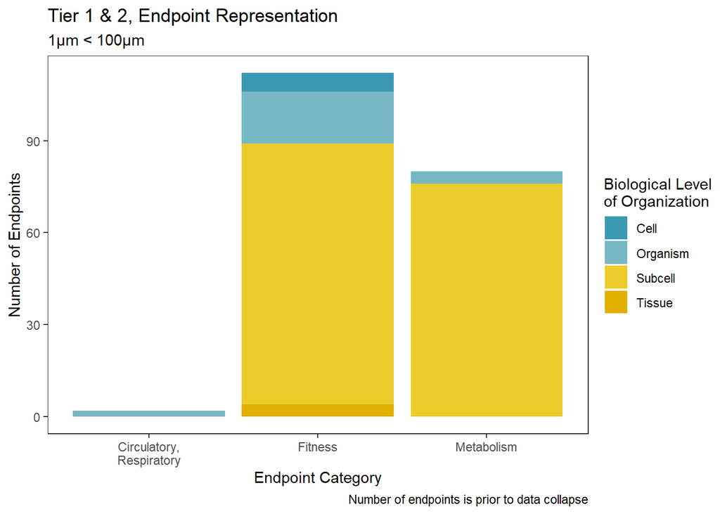

```r
#medium
# endpoints_tier1_2_medium <- tier1_2_medium %>%
#   group_by(lvl1_f, bio_f) %>%
#   mutate(lvl1_count = n()) %>%
#   group_by(lvl1_f, lvl1_count, bio_f) %>%
#   summarise() %>%
#   ggplot(aes(x = lvl1_f, y=lvl1_count, fill = bio_f))+
#   geom_bar(stat = "identity") +
#   scale_fill_manual(values = wes_palette("Zissou1", 5, type = "continuous")) +
#   labs(title = "Tier 1 & 2, Endpoint Representation", subtitle = "10µm < 100µm", x = "Endpoint Category", y = "Number of Endpoints", fill = "Biological Level\nof Organization", caption = "Number of endpoints is prior to data collapse") +
#   theme_test() +
#   scale_x_discrete(labels = wrap_format(10))
#
#
# plot(endpoints_tier1_2_medium)

#small
endpoints_tier1_2_small <- tier1_2_small %>%
  group_by(lvl1_f, bio_f) %>%
  mutate(lvl1_count = n()) %>%
  group_by(lvl1_f, lvl1_count, bio_f) %>%
  summarise() %>%
  ggplot(aes(x = lvl1_f, y=lvl1_count, fill = bio_f))+
  geom_bar(stat = "identity") +
  scale_fill_manual(values = wes_palette("Zissou1", 5, type = "continuous")) +
  labs(title = "Tier 1 & 2, Endpoint Representation", subtitle = "1µm < 100µm", x = "Endpoint Category", y = "Number of Endpoints", fill = "Biological Level\nof Organization", caption = "Number of endpoints is prior to data collapse") +
  theme_test() +
  scale_x_discrete(labels = wrap_format(10))


plot(endpoints_tier1_2_small)
```

```r
#First quartile large particles
tier1_2_large_1q <- tier1_2_large %>%
  group_by(Species, Group) %>%
  summarize(Conc = quantile(dose_new, 0.25))
#First quartile medium particles
# tier1_2_medium_1q <- tier1_2_medium %>%
#   group_by(Species, Group) %>%
#   summarize(Conc = quantile(dose_new, 0.25))

#First quartile small particles
tier1_2_small_1q <- tier1_2_small %>%
  group_by(Species, Group) %>%
  summarize(Conc = quantile(dose_new, 0.25))
```

##### 2.1.1.2.1 Large (100 - 5000 µm)

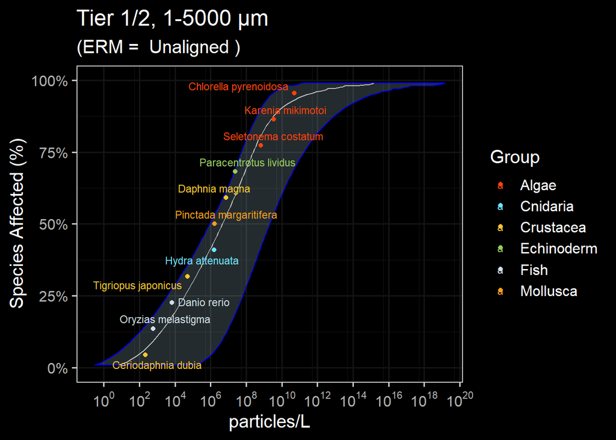

```r
###### --modelling ####
dists_tier1_2_large_1q <- ssd_fit_dists(tier1_2_large_1q, left = "Conc", dists = c("weibull", "llogis", "lnorm", "gamma", "lgumbel"), computable = FALSE, silent = FALSE)

#autoplot(dists_tier1_2_large_1q) #plots the distribution in ggplotier2
#### Goodness of fit ####
gof_tier1_2_large_1q <- as.data.frame(ssd_gof(dists_tier1_2_large_1q)) %>% mutate_if(is.numeric, ~ signif(., 3))

#### Prediction ####
set.seed(99)
pred_tier1_2_large_1q <- predict(dists_tier1_2_large_1q, average = TRUE, ic = "aicc", nboot = 10, ci= TRUE)

#order data
SSD_tier1_2_large_1q <- tier1_2_large_1q[order(tier1_2_large_1q$Conc), ]
SSD_tier1_2_large_1q$frac <- ppoints(tier1_2_large_1q$Conc, 0.5)

#add unique ID for multiplot
pred_tier1_2_large_1q_unaligned <- pred_tier1_2_large_1q
SSD_tier1_2_large_1q_unaligned <- SSD_tier1_2_large_1q

tier1_2_large_1q_lcl <- c(pred_tier1_2_large_1q$lcl[5]) #CI95
tier1_2_large_1q_hc5 <- c(pred_tier1_2_large_1q$est[5]) #HC5
pred_tier1_2_large_1q$est_format <-format(pred_tier1_2_large_1q$est, digits = 3, scientific = TRUE)

#ggplot
tier1_2_large_1q_ggplot <- ggplot(pred_tier1_2_large_1q,aes_string(x = "est")) +
      geom_xribbon(aes_string(xmin = "lcl", xmax = "ucl", y = "percent/100"), alpha = 0.2, color = "blue", fill = "lightblue") +
      geom_line(aes_string(y = "percent/100"), color = "gray") +
      geom_point(data = SSD_tier1_2_large_1q,aes(x = Conc, y =frac, color = Group)) +
      geom_text_repel(data = SSD_tier1_2_large_1q, aes(x = Conc, y = frac, label = Species, color = Group), nudge_x = 0.2, size = 3, segment.alpha = 0.5) +
      scale_y_continuous("Species Affected (%)", labels = scales::percent, limits = c(0,1)) +
  labs(title = "Microplastics Species Sensitivity Distribution",
             subtitle = paste("(ERM = ",ERM,")")) +
      coord_trans(x = "log10") +
      scale_x_continuous(breaks = scales::trans_breaks("log10", function(x) 10^x, n = 15),
                         labels = trans_format("log10", scales::math_format(10^.x))) +
  labs(title = "Tier 1/2, 1-5000 µm", x = "particles/L") +
      fill.type + #user-selected
      color.type + #user-selected
      theme.type #user theme

plot(tier1_2_large_1q_ggplot)
```

```r
# ###### --modelling ####
# dists_tier1_2_medium_1q <- ssd_fit_dists(tier1_2_medium_1q, left = "Conc", dists = c("weibull", "llogis", "lnorm", "gamma", "lgumbel"), computable = FALSE, silent = FALSE)
#
# #autoplot(dists_tier1_2_medium_1q) #plots the distribution in ggplotier2
# #### Goodness of fit ####
# gof_tier1_2_medium_1q <- as.data.frame(ssd_gof(dists_tier1_2_medium_1q)) %>% mutate_if(is.numeric, ~ signif(., 3))
#
# #### Prediction ####
# set.seed(99)
# pred_tier1_2_medium_1q <- predict(dists_tier1_2_medium_1q, average = TRUE, ic = "aicc", nboot = 10, ci= TRUE)
#
# #order data
# SSD_tier1_2_medium_1q <- tier1_2_medium_1q[order(tier1_2_medium_1q$Conc), ]
# SSD_tier1_2_medium_1q$frac <- ppoints(tier1_2_medium_1q$Conc, 0.5)
#
# tier1_2_medium_1q_lcl <- c(pred_tier1_2_medium_1q$lcl[5]) #CI95
# tier1_2_medium_1q_hc5 <- c(pred_tier1_2_medium_1q$est[5]) #HC5
# pred_tier1_2_medium_1q$est_format <-format(pred_tier1_2_medium_1q$est, digits = 3, scientific = TRUE)
#
# #ggplot
# tier1_2_medium_1q_ggplot <- ggplot(pred_tier1_2_medium_1q,aes_string(x = "est")) +
#       geom_xribbon(aes_string(xmin = "lcl", xmax = "ucl", y = "percent/100"), alpha = 0.2, color = "blue", fill = "lightblue") +
#       geom_line(aes_string(y = "percent/100"), color = "gray") +
#       geom_point(data = SSD_tier1_2_medium_1q,aes(x = Conc, y =frac, color = Group)) +
#       geom_text_repel(data = SSD_tier1_2_medium_1q, aes(x = Conc, y = frac, label = Species, color = Group), nudge_x = 0.2, size = 3, segment.alpha = 0.5) +
#       scale_y_continuous("Species Affected (%)", labels = scales::percent, limits = c(0,1)) +
#       coord_trans(x = "log10") +
#       scale_x_continuous(breaks = scales::trans_breaks("log10", function(x) 10^x, n = 15),
#                          labels = trans_format("log10", scales::math_format(10^.x))) +
#   labs(title = "Tier 1/2, 10-100 µm", x = "particles/L") +
#       fill.type + #user-selected
#       color.type + #user-selected
#       theme.type #user theme
#
# plot(tier1_2_medium_1q_ggplot)
```

##### 2.1.1.2.2 Small (1 - 100 µm)

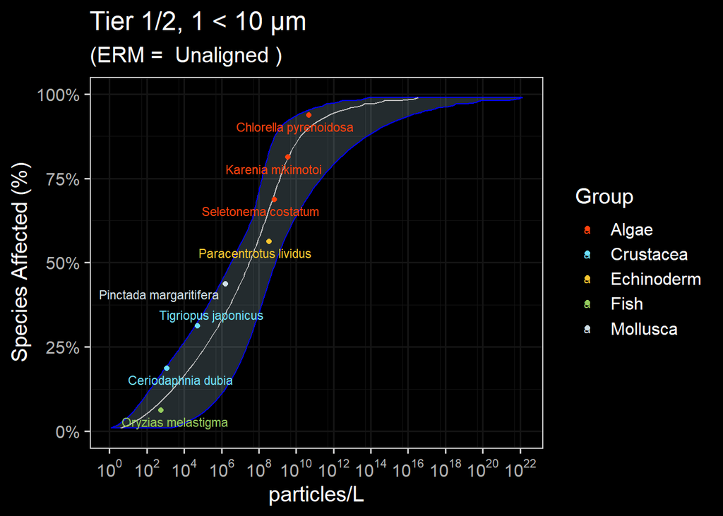

```r
###### --modelling ####
dists_tier1_2_small_1q <- ssd_fit_dists(tier1_2_small_1q, left = "Conc", dists = c("weibull", "llogis", "lnorm", "gamma", "lgumbel"), computable = FALSE, silent = FALSE)

#autoplot(dists_tier1_2_small_1q) #plots the distribution in ggplotier2
#### Goodness of fit ####
gof_tier1_2_small_1q <- as.data.frame(ssd_gof(dists_tier1_2_small_1q)) %>% mutate_if(is.numeric, ~ signif(., 3))

#### Prediction ####
set.seed(99)
pred_tier1_2_small_1q <- predict(dists_tier1_2_small_1q, average = TRUE, ic = "aicc", nboot = 10, ci= TRUE)

#order data
SSD_tier1_2_small_1q <- tier1_2_small_1q[order(tier1_2_small_1q$Conc), ]
SSD_tier1_2_small_1q$frac <- ppoints(tier1_2_small_1q$Conc, 0.5)

tier1_2_small_1q_lcl <- c(pred_tier1_2_small_1q$lcl[5]) #CI95
tier1_2_small_1q_hc5 <- c(pred_tier1_2_small_1q$est[5]) #HC5
pred_tier1_2_small_1q$est_format <-format(pred_tier1_2_small_1q$est, digits = 3, scientific = TRUE)

#ggplot
tier1_2_small_1q_ggplot <- ggplot(pred_tier1_2_small_1q,aes_string(x = "est")) +
      geom_xribbon(aes_string(xmin = "lcl", xmax = "ucl", y = "percent/100"), alpha = 0.2, color = "blue", fill = "lightblue") +
      geom_line(aes_string(y = "percent/100"), color = "gray") +
      geom_point(data = SSD_tier1_2_small_1q,aes(x = Conc, y =frac, color = Group)) +
      geom_text_repel(data = SSD_tier1_2_small_1q, aes(x = Conc, y = frac, label = Species, color = Group), nudge_x = 0.2, size = 3, segment.alpha = 0.5) +
      scale_y_continuous("Species Affected (%)", labels = scales::percent, limits = c(0,1)) +
  labs(title = "Microplastics Species Sensitivity Distribution",
             subtitle = paste("(ERM = ",ERM,")")) +
      coord_trans(x = "log10") +
      scale_x_continuous(breaks = scales::trans_breaks("log10", function(x) 10^x, n = 15),
                         labels = trans_format("log10", scales::math_format(10^.x))) +
  labs(title = "Tier 1/2, 1 < 10 µm", x = "particles/L") +
      fill.type + #user-selected
      color.type + #user-selected
      theme.type #user theme

plot(tier1_2_small_1q_ggplot)
```

#### 2.1.1.3 Tier 1 & 2 Summary Table

Hazard Confidence Level = HC5

Endpoints = All

Levels of Biological Organization = All

HC Metric = 95% CI (Tier 1); Mean (Tier 2)

Data Quality = Pass Technical Quality Red Criteria

```r
#save unique ID for ERM
tier1_large_p <- tier1_2_large_1q_lcl
tier2_large_p <- tier1_2_large_1q_hc5
tier1_small_p <- tier1_2_small_1q_lcl
tier2_small_p <- tier1_2_small_1q_hc5

larges <- list(tier1_2_large_1q_lcl, tier1_2_large_1q_hc5,
              tier1_2_large.obs[[1,1]], #n.obs
              tier1_2_large.obs[[1,2]], #n.studies
              tier1_2_large.obs[[1,3]], #n.taxa
              tier1_2_large.obs[[1,4]]) #n.species

# mediums <- list(tier1_2_medium_1q_lcl, tier1_2_medium_1q_hc5,
#               tier1_2_medium.obs[[1,1]], #n.obs
#               tier1_2_medium.obs[[1,2]], #n.studies
#               tier1_2_medium.obs[[1,3]], #n.taxa
#               tier1_2_medium.obs[[1,4]]) #n.species

smalls <- list(tier1_2_small_1q_lcl, tier1_2_small_1q_hc5,
              tier1_2_small.obs[[1,1]], #n.obs
              tier1_2_small.obs[[1,2]], #n.studies
              tier1_2_small.obs[[1,3]], #n.taxa
              tier1_2_small.obs[[1,4]]) #n.species

# Convert to data frames
largesdf <- data.frame(matrix(unlist(larges), ncol = 6))
# mediumsdf <- data.frame(matrix(unlist(mediums), ncol = 6))
smallsdf <- data.frame(matrix(unlist(smalls), ncol = 6))

# Rename columns
colnames(largesdf) <- c("Tier_1", "Tier_2", "N_Obs.", "N_Doi", "N_Taxa", "N_Species")
# colnames(mediumsdf) <- c("Tier_1", "Tier_2", "N_Obs.", "N_Doi", "N_Taxa", "N_Species")
colnames(smallsdf) <- c("Tier_1", "Tier_2", "N_Obs.", "N_Doi", "N_Taxa", "N_Species")

# Make tables

gt(largesdf) %>%
  tab_header(title = "Tier 1/2, 1µm - 5mm", paste("Thresholds presented in particles/L; ERM = ",ERM)) %>%
  fmt_number(columns = vars(Tier_1, Tier_2),decimals = 2, use_seps = TRUE)
```

Tier 1/2, 1µm - 5mm

Thresholds presented in particles/L; ERM = Unaligned

| Tier_1 | Tier_2 | N_Obs. | N_Doi | N_Taxa | N_Species |
| --- | --- | --- | --- | --- | --- |
| 5.14 | 107.97 | 230 | 12 | 6 | 11 |

```r
# gt(mediumsdf) %>%
#   tab_header(title = "Tier 1/2, 10-100 um", subtitle = "Thresholds presented in particles/L") %>%
#   fmt_number(columns = vars(Tier_1, Tier_2),decimals = 2, use_seps = TRUE)

gt(smallsdf) %>%
  tab_header(title = "Tier 1/2, 1 < 100 um", subtitle = paste("Thresholds presented in particles/L; ERM = ",ERM)
             ) %>%
  fmt_number(columns = vars(Tier_1, Tier_2),decimals = 2, use_seps = TRUE)
```

Tier 1/2, 1 < 100 um

Thresholds presented in particles/L; ERM = Unaligned

| Tier_1 | Tier_2 | N_Obs. | N_Doi | N_Taxa | N_Species |
| --- | --- | --- | --- | --- | --- |
| 12.96 | 84.86 | 194 | 8 | 5 | 8 |

## 2.2 ERM = Particles

```r
ERM <- "Particles"
```

### 2.2.1 Tiers 1 & 2

Tier 1 and 2 are the same SSD. A different HC metric is selected to differentiate between the tiers. Specifically, Tier 1 uses the 95% CI whereas Tier 2 uses the Mean. See below for more details of specific parameters.

Hazard Confidence Level = HC5

Endpoints = All

Levels of Biological Organization = All

HC Metric = 95% CI (Tier 1); Mean (Tier 2)

Data Quality = Pass Technical Quality Red Criteria

#### 2.2.1.1 Data Filtering

```r
tier1_2_large <- aoc_final_large %>%
         mutate(dose_new = EC_env_p.particles.mL / (af.time * af.noec)) %>%
         drop_na(dose_new) %>%
         mutate(dose_new = dose_new * 1000) %>%
  filter(size.length.um.used.for.conversions %in% (1:5000))

# Count observations and studies
tier1_2_large.obs <- tier1_2_large %>% summarize(n.obs = n(), n.studies = n_distinct(doi), n.taxa = n_distinct(org_f), n.species = n_distinct(species_f))

# ### 10 - 100 um
# tier1_2_medium <- tier1_2 %>%
#   filter(size_f %in% c("10µm < 100µm"))
#
# # Count observations and studies
# tier1_2_medium.obs <- tier1_2_medium %>% summarize(n.obs = n(), n.studies = n_distinct(doi), n.taxa = n_distinct(org_f), n.species = n_distinct(species_f))

### 1 - 100 um
tier1_2_small <- aoc_final_small %>%
         mutate(dose_new = EC_env_p.particles.mL / (af.time * af.noec)) %>%
         drop_na(dose_new) %>%
         mutate(dose_new = dose_new * 1000) %>%
  filter(size.length.um.used.for.conversions %in% (1:10))

# Count observations and studies
tier1_2_small.obs <- tier1_2_small %>% summarize(n.obs = n(), n.studies = n_distinct(doi), n.taxa = n_distinct(org_f), n.species = n_distinct(species_f))
```

#### 2.2.1.2 Endpoint Representation

```r
#large
endpoints_tier1_2_large <- tier1_2_large %>%
  group_by(lvl1_f, bio_f) %>%
  mutate(lvl1_count = n()) %>%
  group_by(lvl1_f, lvl1_count, bio_f) %>%
  summarise() %>%
  ggplot(aes(x = lvl1_f, y=lvl1_count, fill = bio_f))+
  geom_bar(stat = "identity") +
  scale_fill_manual(values = wes_palette("Zissou1", 5, type = "continuous")) +
  labs(title = "Tier 1 & 2, Endpoint Representation", subtitle = "1µm - 5mm", x = "Endpoint Category", y = "Number of Endpoints", fill = "Biological Level\nof Organization", caption = "Number of endpoints is prior to data collapse") +
  theme_test() +
  scale_x_discrete(labels = wrap_format(10))


# plot(endpoints_tier1_2_large)

#medium
# endpoints_tier1_2_medium <- tier1_2_medium %>%
#   group_by(lvl1_f, bio_f) %>%
#   mutate(lvl1_count = n()) %>%
#   group_by(lvl1_f, lvl1_count, bio_f) %>%
#   summarise() %>%
#   ggplot(aes(x = lvl1_f, y=lvl1_count, fill = bio_f))+
#   geom_bar(stat = "identity") +
#   scale_fill_manual(values = wes_palette("Zissou1", 5, type = "continuous")) +
#   labs(title = "Tier 1 & 2, Endpoint Representation", subtitle = "10µm < 100µm", x = "Endpoint Category", y = "Number of Endpoints", fill = "Biological Level\nof Organization", caption = "Number of endpoints is prior to data collapse") +
#   theme_test() +
#   scale_x_discrete(labels = wrap_format(10))
#
#
# plot(endpoints_tier1_2_medium)

#small
endpoints_tier1_2_small <- tier1_2_small %>%
  group_by(lvl1_f, bio_f) %>%
  mutate(lvl1_count = n()) %>%
  group_by(lvl1_f, lvl1_count, bio_f) %>%
  summarise() %>%
  ggplot(aes(x = lvl1_f, y=lvl1_count, fill = bio_f))+
  geom_bar(stat = "identity") +
  scale_fill_manual(values = wes_palette("Zissou1", 5, type = "continuous")) +
  labs(title = "Tier 1 & 2, Endpoint Representation", subtitle = "1µm < 100µm", x = "Endpoint Category", y = "Number of Endpoints", fill = "Biological Level\nof Organization", caption = "Number of endpoints is prior to data collapse") +
  theme_test() +
  scale_x_discrete(labels = wrap_format(10))


# plot(endpoints_tier1_2_small)
```

#### 2.2.1.3 SSD Build

##### 2.2.1.3.1 Data Collapse

```r
#First quartile large particles
tier1_2_large_1q <- tier1_2_large %>%
  group_by(Species, Group) %>%
  summarize(Conc = quantile(dose_new, 0.25))
#First quartile medium particles
# tier1_2_medium_1q <- tier1_2_medium %>%
#   group_by(Species, Group) %>%
#   summarize(Conc = quantile(dose_new, 0.25))

#First quartile small particles
tier1_2_small_1q <- tier1_2_small %>%
  group_by(Species, Group) %>%
  summarize(Conc = quantile(dose_new, 0.25))
```

##### 2.2.1.3.2 Large (100 - 5000 µm)

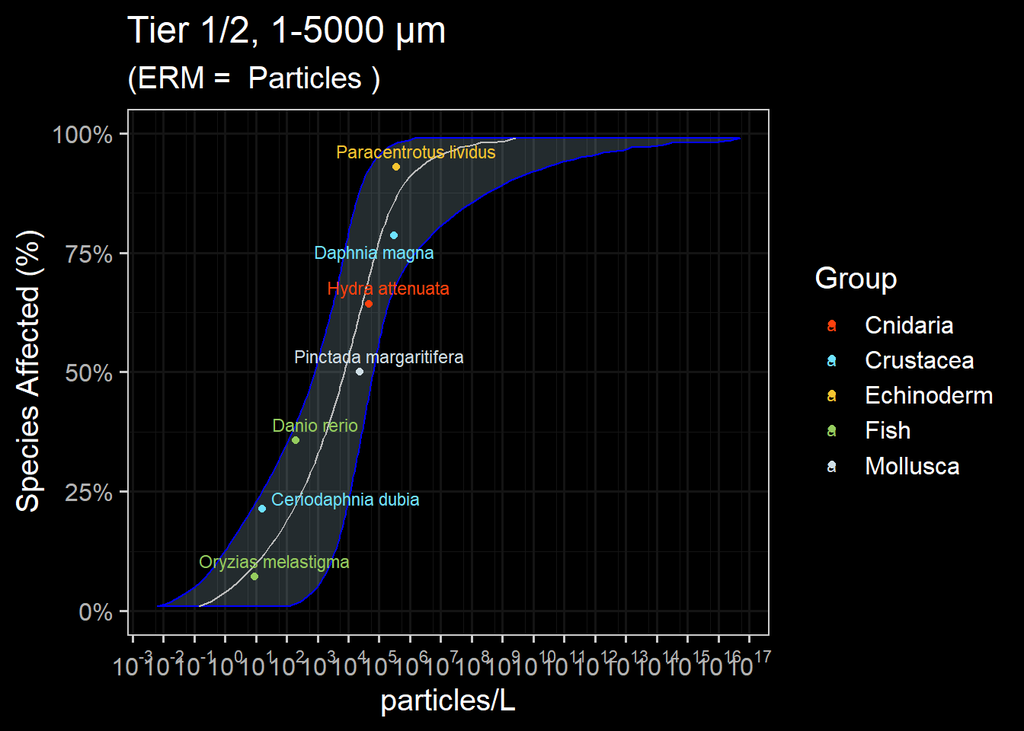

```r
###### --modelling ####
dists_tier1_2_large_1q <- ssd_fit_dists(tier1_2_large_1q, left = "Conc", dists = c("weibull", "llogis", "lnorm", "gamma", "lgumbel"), computable = FALSE, silent = FALSE)

#autoplot(dists_tier1_2_large_1q) #plots the distribution in ggplotier2
#### Goodness of fit ####
gof_tier1_2_large_1q <- as.data.frame(ssd_gof(dists_tier1_2_large_1q)) %>% mutate_if(is.numeric, ~ signif(., 3))

#### Prediction ####
set.seed(99)
pred_tier1_2_large_1q <- predict(dists_tier1_2_large_1q, average = TRUE, ic = "aicc", nboot = 10, ci= TRUE)

#order data
SSD_tier1_2_large_1q <- tier1_2_large_1q[order(tier1_2_large_1q$Conc), ]
SSD_tier1_2_large_1q$frac <- ppoints(tier1_2_large_1q$Conc, 0.5)

#add unique ID for multiplot
pred_tier1_2_large_1q_particles <- pred_tier1_2_large_1q
SSD_tier1_2_large_1q_particles <- SSD_tier1_2_large_1q

tier1_2_large_1q_lcl <- c(pred_tier1_2_large_1q$lcl[5]) #CI95
tier1_2_large_1q_hc5 <- c(pred_tier1_2_large_1q$est[5]) #HC5
pred_tier1_2_large_1q$est_format <-format(pred_tier1_2_large_1q$est, digits = 3, scientific = TRUE)

#ggplot
tier1_2_large_1q_ggplot <- ggplot(pred_tier1_2_large_1q,aes_string(x = "est")) +
      geom_xribbon(aes_string(xmin = "lcl", xmax = "ucl", y = "percent/100"), alpha = 0.2, color = "blue", fill = "lightblue") +
      geom_line(aes_string(y = "percent/100"), color = "gray") +
      geom_point(data = SSD_tier1_2_large_1q,aes(x = Conc, y =frac, color = Group)) +
      geom_text_repel(data = SSD_tier1_2_large_1q, aes(x = Conc, y = frac, label = Species, color = Group), nudge_x = 0.2, size = 3, segment.alpha = 0.5) +
      scale_y_continuous("Species Affected (%)", labels = scales::percent, limits = c(0,1)) +
  labs(title = "Microplastics Species Sensitivity Distribution",
             subtitle = paste("(ERM = ",ERM,")")) +
      coord_trans(x = "log10") +
      scale_x_continuous(breaks = scales::trans_breaks("log10", function(x) 10^x, n = 15),
                         labels = trans_format("log10", scales::math_format(10^.x))) +
  labs(title = "Tier 1/2, 1-5000 µm", x = "particles/L") +
      fill.type + #user-selected
      color.type + #user-selected
      theme.type #user theme

plot(tier1_2_large_1q_ggplot)
```

```r
# ###### --modelling ####
# dists_tier1_2_medium_1q <- ssd_fit_dists(tier1_2_medium_1q, left = "Conc", dists = c("weibull", "llogis", "lnorm", "gamma", "lgumbel"), computable = FALSE, silent = FALSE)
#
# #autoplot(dists_tier1_2_medium_1q) #plots the distribution in ggplotier2
# #### Goodness of fit ####
# gof_tier1_2_medium_1q <- as.data.frame(ssd_gof(dists_tier1_2_medium_1q)) %>% mutate_if(is.numeric, ~ signif(., 3))
#
# #### Prediction ####
# set.seed(99)
# pred_tier1_2_medium_1q <- predict(dists_tier1_2_medium_1q, average = TRUE, ic = "aicc", nboot = 10, ci= TRUE)
#
# #order data
# SSD_tier1_2_medium_1q <- tier1_2_medium_1q[order(tier1_2_medium_1q$Conc), ]
# SSD_tier1_2_medium_1q$frac <- ppoints(tier1_2_medium_1q$Conc, 0.5)
#
# tier1_2_medium_1q_lcl <- c(pred_tier1_2_medium_1q$lcl[5]) #CI95
# tier1_2_medium_1q_hc5 <- c(pred_tier1_2_medium_1q$est[5]) #HC5
# pred_tier1_2_medium_1q$est_format <-format(pred_tier1_2_medium_1q$est, digits = 3, scientific = TRUE)
#
# #ggplot
# tier1_2_medium_1q_ggplot <- ggplot(pred_tier1_2_medium_1q,aes_string(x = "est")) +
#       geom_xribbon(aes_string(xmin = "lcl", xmax = "ucl", y = "percent/100"), alpha = 0.2, color = "blue", fill = "lightblue") +
#       geom_line(aes_string(y = "percent/100"), color = "gray") +
#       geom_point(data = SSD_tier1_2_medium_1q,aes(x = Conc, y =frac, color = Group)) +
#       geom_text_repel(data = SSD_tier1_2_medium_1q, aes(x = Conc, y = frac, label = Species, color = Group), nudge_x = 0.2, size = 3, segment.alpha = 0.5) +
#       scale_y_continuous("Species Affected (%)", labels = scales::percent, limits = c(0,1)) +
#       coord_trans(x = "log10") +
#       scale_x_continuous(breaks = scales::trans_breaks("log10", function(x) 10^x, n = 15),
#                          labels = trans_format("log10", scales::math_format(10^.x))) +
#   labs(title = "Tier 1/2, 10-100 µm", x = "particles/L") +
#       fill.type + #user-selected
#       color.type + #user-selected
#       theme.type #user theme
#
# plot(tier1_2_medium_1q_ggplot)
```

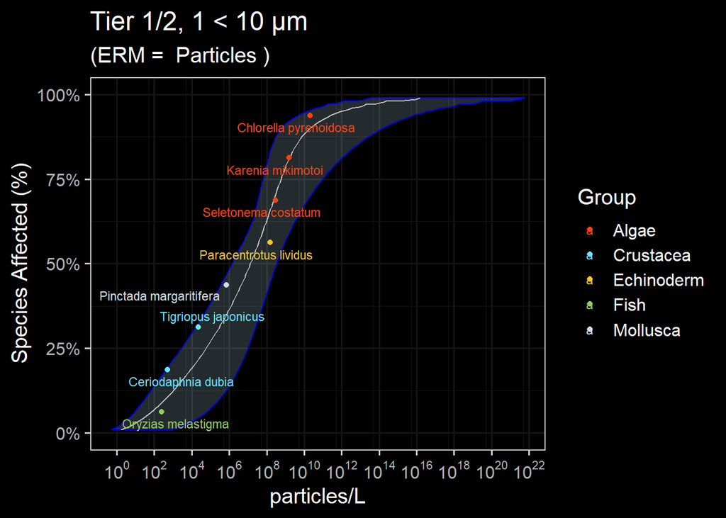

```r
###### --modelling ####
dists_tier1_2_small_1q <- ssd_fit_dists(tier1_2_small_1q, left = "Conc", dists = c("weibull", "llogis", "lnorm", "gamma", "lgumbel"), computable = FALSE, silent = FALSE)

#autoplot(dists_tier1_2_small_1q) #plots the distribution in ggplotier2
#### Goodness of fit ####
gof_tier1_2_small_1q <- as.data.frame(ssd_gof(dists_tier1_2_small_1q)) %>% mutate_if(is.numeric, ~ signif(., 3))

#### Prediction ####
set.seed(99)
pred_tier1_2_small_1q <- predict(dists_tier1_2_small_1q, average = TRUE, ic = "aicc", nboot = 10, ci= TRUE)

#order data
SSD_tier1_2_small_1q <- tier1_2_small_1q[order(tier1_2_small_1q$Conc), ]
SSD_tier1_2_small_1q$frac <- ppoints(tier1_2_small_1q$Conc, 0.5)

tier1_2_small_1q_lcl <- c(pred_tier1_2_small_1q$lcl[5]) #CI95
tier1_2_small_1q_hc5 <- c(pred_tier1_2_small_1q$est[5]) #HC5
pred_tier1_2_small_1q$est_format <-format(pred_tier1_2_small_1q$est, digits = 3, scientific = TRUE)

#ggplot
tier1_2_small_1q_ggplot <- ggplot(pred_tier1_2_small_1q,aes_string(x = "est")) +
      geom_xribbon(aes_string(xmin = "lcl", xmax = "ucl", y = "percent/100"), alpha = 0.2, color = "blue", fill = "lightblue") +
      geom_line(aes_string(y = "percent/100"), color = "gray") +
      geom_point(data = SSD_tier1_2_small_1q,aes(x = Conc, y =frac, color = Group)) +
      geom_text_repel(data = SSD_tier1_2_small_1q, aes(x = Conc, y = frac, label = Species, color = Group), nudge_x = 0.2, size = 3, segment.alpha = 0.5) +
      scale_y_continuous("Species Affected (%)", labels = scales::percent, limits = c(0,1)) +
  labs(title = "Microplastics Species Sensitivity Distribution",
             subtitle = paste("(ERM = ",ERM,")")) +
      coord_trans(x = "log10") +
      scale_x_continuous(breaks = scales::trans_breaks("log10", function(x) 10^x, n = 15),
                         labels = trans_format("log10", scales::math_format(10^.x))) +
  labs(title = "Tier 1/2, 1 < 10 µm", x = "particles/L") +
      fill.type + #user-selected
      color.type + #user-selected
      theme.type #user theme

plot(tier1_2_small_1q_ggplot)
```

#### 2.2.1.4 Tier 1 & 2 Summary Table

Hazard Confidence Level = HC5

Endpoints = All

Levels of Biological Organization = All

HC Metric = 95% CI (Tier 1); Mean (Tier 2)

Data Quality = Pass Technical Quality Red Criteria

```r
#save unique ID for ERM
tier1_large_p <- tier1_2_large_1q_lcl
tier2_large_p <- tier1_2_large_1q_hc5
tier1_small_p <- tier1_2_small_1q_lcl
tier2_small_p <- tier1_2_small_1q_hc5

larges <- list(tier1_2_large_1q_lcl, tier1_2_large_1q_hc5,
              tier1_2_large.obs[[1,1]], #n.obs
              tier1_2_large.obs[[1,2]], #n.studies
              tier1_2_large.obs[[1,3]], #n.taxa
              tier1_2_large.obs[[1,4]]) #n.species

# mediums <- list(tier1_2_medium_1q_lcl, tier1_2_medium_1q_hc5,
#               tier1_2_medium.obs[[1,1]], #n.obs
#               tier1_2_medium.obs[[1,2]], #n.studies
#               tier1_2_medium.obs[[1,3]], #n.taxa
#               tier1_2_medium.obs[[1,4]]) #n.species

smalls <- list(tier1_2_small_1q_lcl, tier1_2_small_1q_hc5,
              tier1_2_small.obs[[1,1]], #n.obs
              tier1_2_small.obs[[1,2]], #n.studies
              tier1_2_small.obs[[1,3]], #n.taxa
              tier1_2_small.obs[[1,4]]) #n.species

# Convert to data frames
largesdf <- data.frame(matrix(unlist(larges), ncol = 6))
# mediumsdf <- data.frame(matrix(unlist(mediums), ncol = 6))
smallsdf <- data.frame(matrix(unlist(smalls), ncol = 6))

# Rename columns
colnames(largesdf) <- c("Tier_1", "Tier_2", "N_Obs.", "N_Doi", "N_Taxa", "N_Species")
# colnames(mediumsdf) <- c("Tier_1", "Tier_2", "N_Obs.", "N_Doi", "N_Taxa", "N_Species")
colnames(smallsdf) <- c("Tier_1", "Tier_2", "N_Obs.", "N_Doi", "N_Taxa", "N_Species")

# Make tables

gt(largesdf) %>%
  tab_header(title = "Tier 1/2, 1µm - 5mm", paste("Thresholds presented in particles/L; ERM = ",ERM)) %>%
  fmt_number(columns = vars(Tier_1, Tier_2),decimals = 2, use_seps = TRUE)
```

Tier 1/2, 1µm - 5mm

Thresholds presented in particles/L; ERM = Particles

| Tier_1 | Tier_2 | N_Obs. | N_Doi | N_Taxa | N_Species |
| --- | --- | --- | --- | --- | --- |
| 0.10 | 1.64 | 220 | 8 | 5 | 7 |

```r
# gt(mediumsdf) %>%
#   tab_header(title = "Tier 1/2, 10-100 um", subtitle = "Thresholds presented in particles/L") %>%
#   fmt_number(columns = vars(Tier_1, Tier_2),decimals = 2, use_seps = TRUE)

gt(smallsdf) %>%
  tab_header(title = "Tier 1/2, 1 < 100 um", subtitle = paste("Thresholds presented in particles/L; ERM = ",ERM)
             ) %>%
  fmt_number(columns = vars(Tier_1, Tier_2),decimals = 2, use_seps = TRUE)
```

Tier 1/2, 1 < 100 um

Thresholds presented in particles/L; ERM = Particles

| Tier_1 | Tier_2 | N_Obs. | N_Doi | N_Taxa | N_Species |
| --- | --- | --- | --- | --- | --- |
| 5.66 | 37.05 | 194 | 8 | 5 | 8 |

### 2.2.2 Tiers 3 & 4

Hazard Confidence Level = HC5(Tier3)/HC10(Tier4)

Endpoints = All

Levels of Biological Organization = Organism and Population

HC Metric = Mean

Data Quality = Pass Technical & Risk Quality Red Criteria

#### 2.2.2.1 Data Filtering

```r
#### Size filters ####

### 100 - 5000 um
tier3_4_large <-  aoc_final_large %>%
  filter(risk.13 != 1, #Drop studies that only scored a 1 for endpoints criteria
         bio_f %in% c("Organism", "Population")) %>% #limit to endpoints measured at the organism or population level
         mutate(dose_new = EC_env_p.particles.mL / (af.time * af.noec)) %>%
         drop_na(dose_new) %>%
         mutate(dose_new = dose_new*1000) %>%
  filter(size.length.um.used.for.conversions %in% (1:5000))

# Count observations and studies
tier3_4_large.obs <- tier3_4_large %>% summarize(n.obs = n(), n.studies = n_distinct(doi), n.taxa = n_distinct(org_f), n.species = n_distinct(species_f))

# ### 10 - 100 um
# tier3_4_medium <- tier3_4 %>%
#   filter(size_f %in% c("10µm < 100µm"))
#
# # Count observations and studies
# tier3_4_medium.obs <- tier3_4_medium %>% summarize(n.obs = n(), n.studies = n_distinct(doi), n.taxa = n_distinct(org_f), n.species = n_distinct(species_f))

### 1 - 100 um
tier3_4_small <- aoc_final_small %>%
  filter(risk.13 != 1, #Drop studies that only scored a 1 for endpoints criteria
         bio_f %in% c("Organism", "Population")) %>% #limit to endpoints measured at the organism or population level
         mutate(dose_new = EC_env_p.particles.mL / (af.time * af.noec)) %>%
         drop_na(dose_new) %>%
         mutate(dose_new = dose_new*1000) %>%
  filter(size.length.um.used.for.conversions %in% (1:10))

# Count observations and studies
tier3_4_small.obs <- tier3_4_small %>% summarize(n.obs = n(), n.studies = n_distinct(doi), n.taxa = n_distinct(org_f), n.species = n_distinct(species_f))
```

#### 2.2.2.2 Endpoint Representation

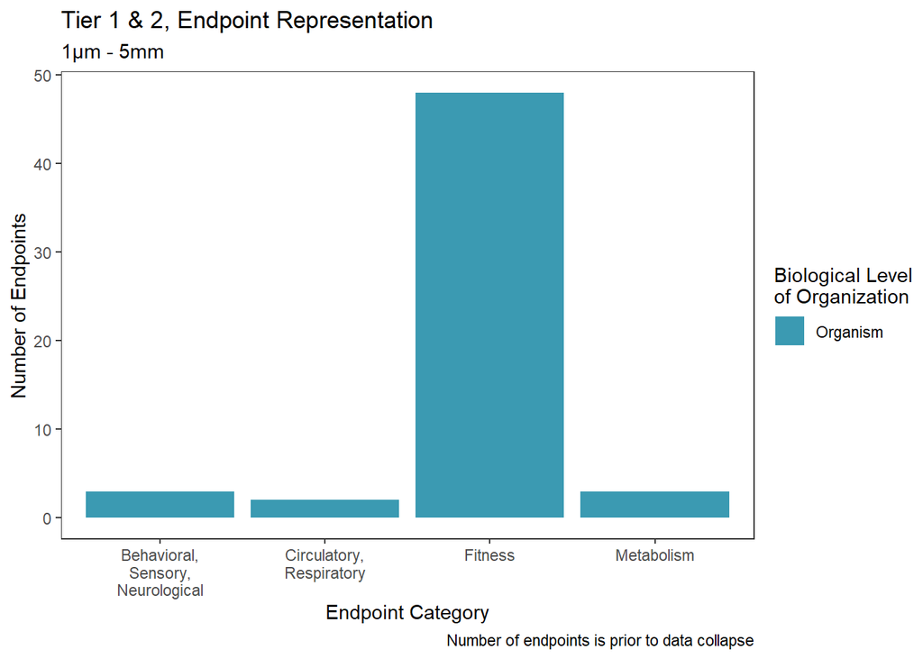

```r
#large
endpoints_tier3_4_large <- tier3_4_large %>%
  group_by(lvl1_f, bio_f) %>%
  mutate(lvl1_count = n()) %>%
  group_by(lvl1_f, lvl1_count, bio_f) %>%
  summarise() %>%
  ggplot(aes(x = lvl1_f, y=lvl1_count, fill = bio_f))+
  geom_bar(stat = "identity") +
  scale_fill_manual(values = wes_palette("Zissou1", 5, type = "continuous")) +
  labs(title = "Tier 1 & 2, Endpoint Representation", subtitle = "1µm - 5mm", x = "Endpoint Category", y = "Number of Endpoints", fill = "Biological Level\nof Organization", caption = "Number of endpoints is prior to data collapse") +
  theme_test() +
  scale_x_discrete(labels = wrap_format(10))


plot(endpoints_tier3_4_large)
```

```r
#medium
# endpoints_tier3_4_medium <- tier3_4_medium %>%
#   group_by(lvl1_f, bio_f) %>%
#   mutate(lvl1_count = n()) %>%
#   group_by(lvl1_f, lvl1_count, bio_f) %>%
#   summarise() %>%
#   ggplot(aes(x = lvl1_f, y=lvl1_count, fill = bio_f))+
#   geom_bar(stat = "identity") +
#   scale_fill_manual(values = wes_palette("Zissou1", 5, type = "continuous")) +
#   labs(title = "Tier 1 & 2, Endpoint Representation", subtitle = "10µm < 100µm", x = "Endpoint Category", y = "Number of Endpoints", fill = "Biological Level\nof Organization", caption = "Number of endpoints is prior to data collapse") +
#   theme_test() +
#   scale_x_discrete(labels = wrap_format(10))
#
#
# plot(endpoints_tier3_4_medium)

#small
endpoints_tier3_4_small <- tier3_4_small %>%
  group_by(lvl1_f, bio_f) %>%
  mutate(lvl1_count = n()) %>%
  group_by(lvl1_f, lvl1_count, bio_f) %>%
  summarise() %>%
  ggplot(aes(x = lvl1_f, y=lvl1_count, fill = bio_f))+
  geom_bar(stat = "identity") +
  scale_fill_manual(values = wes_palette("Zissou1", 5, type = "continuous")) +
  labs(title = "Tier 1 & 2, Endpoint Representation", subtitle = "1µm < 100µm", x = "Endpoint Category", y = "Number of Endpoints", fill = "Biological Level\nof Organization", caption = "Number of endpoints is prior to data collapse") +
  theme_test() +
  scale_x_discrete(labels = wrap_format(10))


plot(endpoints_tier3_4_small)
```

#### 2.2.2.3 SSD Build

##### 2.2.2.3.1 Data Collapse

```r
#First quartile large particles
tier3_4_large_median <- tier3_4_large %>%
  group_by(Species, Group) %>%
  summarize(Conc = median(dose_new))
#First quartile medium particles
# tier3_4_medium_median <- tier3_4_medium %>%
#   group_by(Species, Group) %>%
#   summarize(Conc = median(dose_new))

#First quartile small particles
tier3_4_small_median <- tier3_4_small %>%
  group_by(Species, Group) %>%
  summarize(Conc = median(dose_new))
```

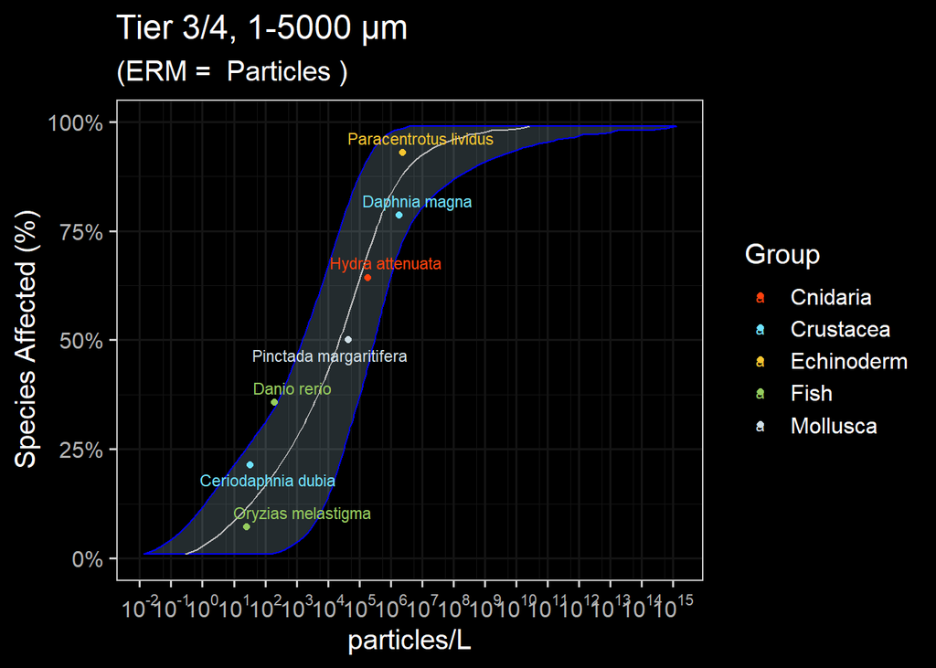

```r
###### --modelling ####
dists_tier3_4_large_median <- ssd_fit_dists(tier3_4_large_median, left = "Conc", dists = c("weibull", "llogis", "lnorm", "gamma", "lgumbel"), computable = FALSE, silent = FALSE)

#autoplot(dists_tier3_4_large_median) #plots the distribution in ggplotier2
#### Goodness of fit ####
gof_tier3_4_large_median <- as.data.frame(ssd_gof(dists_tier3_4_large_median)) %>% mutate_if(is.numeric, ~ signif(., 3))

#### Prediction ####
set.seed(99)
pred_tier3_4_large_median <- predict(dists_tier3_4_large_median, average = TRUE, ic = "aicc", nboot = 10, ci= TRUE)

#order data
SSD_tier3_4_large_median <- tier3_4_large_median[order(tier3_4_large_median$Conc), ]
SSD_tier3_4_large_median$frac <- ppoints(tier3_4_large_median$Conc, 0.5)

tier3_4_large_median_hc5 <- c(pred_tier3_4_large_median$est[5]) #HC5
tier3_4_large_median_hc10 <- c(pred_tier3_4_large_median$est[10]) #HC10
pred_tier3_4_large_median$est_format <-format(pred_tier3_4_large_median$est, digits = 3, scientific = TRUE)

#ggplot
tier3_4_large_median_ggplot <- ggplot(pred_tier3_4_large_median,aes_string(x = "est")) +
      geom_xribbon(aes_string(xmin = "lcl", xmax = "ucl", y = "percent/100"), alpha = 0.2, color = "blue", fill = "lightblue") +
      geom_line(aes_string(y = "percent/100"), color = "gray") +
      geom_point(data = SSD_tier3_4_large_median,aes(x = Conc, y =frac, color = Group)) +
      geom_text_repel(data = SSD_tier3_4_large_median, aes(x = Conc, y = frac, label = Species, color = Group), nudge_x = 0.2, size = 3, segment.alpha = 0.5) +
      scale_y_continuous("Species Affected (%)", labels = scales::percent, limits = c(0,1)) +
  labs(title = "Microplastics Species Sensitivity Distribution",
             subtitle = paste("(ERM = ",ERM,")")) +
      coord_trans(x = "log10") +
      scale_x_continuous(breaks = scales::trans_breaks("log10", function(x) 10^x, n = 15),
                         labels = trans_format("log10", scales::math_format(10^.x))) +
  labs(title = "Tier 3/4, 1-5000 µm", x = "particles/L") +
      fill.type + #user-selected
      color.type + #user-selected
      theme.type #user theme

plot(tier3_4_large_median_ggplot)
```

```r
###### --modelling ####
# dists_tier3_4_medium_median <- ssd_fit_dists(tier3_4_medium_median, left = "Conc", dists = c("weibull", "llogis", "lnorm", "gamma", "lgumbel"), computable = FALSE, silent = FALSE)
#
# #autoplot(dists_tier3_4_medium_median) #plots the distribution in ggplotier2
# #### Goodness of fit ####
# gof_tier3_4_medium_median <- as.data.frame(ssd_gof(dists_tier3_4_medium_median)) %>% mutate_if(is.numeric, ~ signif(., 3))
#
# #### Prediction ####
# set.seed(99)
# pred_tier3_4_medium_median <- predict(dists_tier3_4_medium_median, average = TRUE, ic = "aicc", nboot = 10, ci= TRUE)
#
# #order data
# SSD_tier3_4_medium_median <- tier3_4_medium_median[order(tier3_4_medium_median$Conc), ]
# SSD_tier3_4_medium_median$frac <- ppoints(tier3_4_medium_median$Conc, 0.5)
#
# tier3_4_medium_median_hc5 <- c(pred_tier3_4_medium_median$est[5]) #HC5
# tier3_4_medium_median_hc10 <- c(pred_tier3_4_medium_median$est[10]) #HC10
# pred_tier3_4_medium_median$est_format <-format(pred_tier3_4_medium_median$est, digits = 3, scientific = TRUE)
#
# #ggplot
# tier3_4_medium_median_ggplot <- ggplot(pred_tier3_4_medium_median,aes_string(x = "est")) +
#       geom_xribbon(aes_string(xmin = "lcl", xmax = "ucl", y = "percent/100"), alpha = 0.2, color = "blue", fill = "lightblue") +
#       geom_line(aes_string(y = "percent/100"), color = "gray") +
#       geom_point(data = SSD_tier3_4_medium_median,aes(x = Conc, y =frac, color = Group)) +
#       geom_text_repel(data = SSD_tier3_4_medium_median, aes(x = Conc, y = frac, label = Species, color = Group), nudge_x = 0.2, size = 3, segment.alpha = 0.5) +
#       scale_y_continuous("Species Affected (%)", labels = scales::percent, limits = c(0,1)) +
#       coord_trans(x = "log10") +
#       scale_x_continuous(breaks = scales::trans_breaks("log10", function(x) 10^x, n = 15),
#                          labels = trans_format("log10", scales::math_format(10^.x))) +
#   labs(title = "Tier 3/4, 10-100 µm", x = "particles/L") +
#       fill.type + #user-selected
#       color.type + #user-selected
#       theme.type #user theme
#
# tier3_4_medium_median_ggplot
```

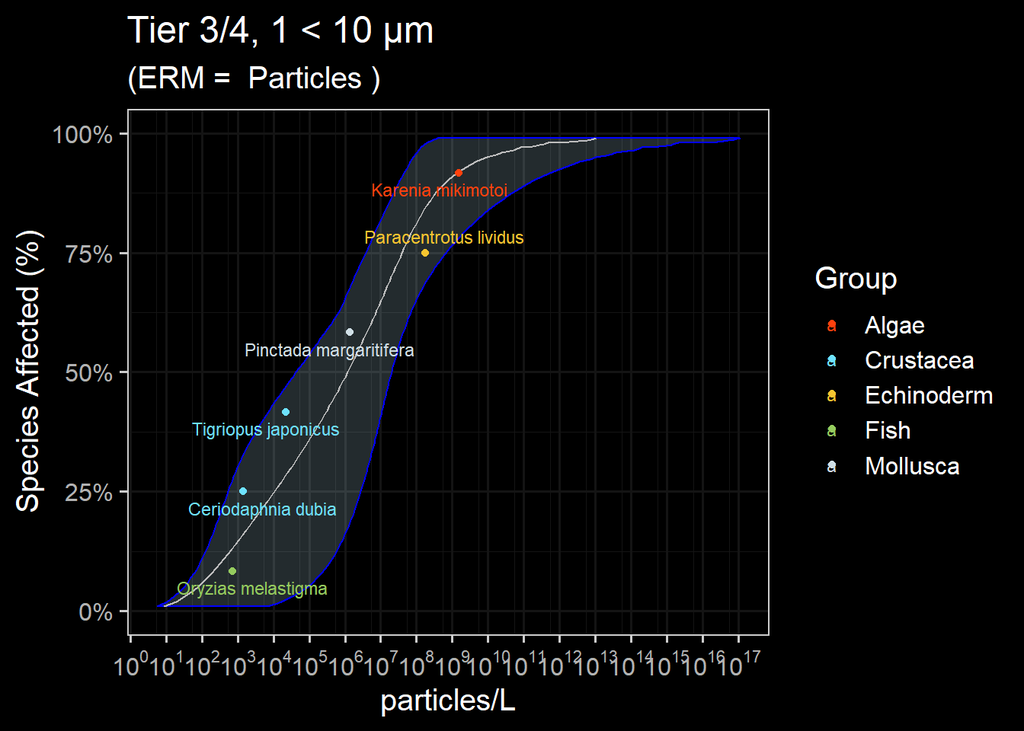

```r
###### --modelling ####
dists_tier3_4_small_median <- ssd_fit_dists(tier3_4_small_median, left = "Conc", dists = c("weibull", "llogis", "lnorm", "gamma", "lgumbel"), computable = FALSE, silent = FALSE)

#autoplot(dists_tier3_4_small_median) #plots the distribution in ggplotier2
#### Goodness of fit ####
gof_tier3_4_small_median <- as.data.frame(ssd_gof(dists_tier3_4_small_median)) %>% mutate_if(is.numeric, ~ signif(., 3))

#### Prediction ####
set.seed(99)
pred_tier3_4_small_median <- predict(dists_tier3_4_small_median, average = TRUE, ic = "aicc", nboot = 10, ci= TRUE)

#order data
SSD_tier3_4_small_median <- tier3_4_small_median[order(tier3_4_small_median$Conc), ]
SSD_tier3_4_small_median$frac <- ppoints(tier3_4_small_median$Conc, 0.5)

tier3_4_small_median_hc5 <- c(pred_tier3_4_small_median$est[5]) #HC5
tier3_4_small_median_hc10 <- c(pred_tier3_4_small_median$est[10]) #HC10
pred_tier3_4_small_median$est_format <-format(pred_tier3_4_small_median$est, digits = 3, scientific = TRUE)

#ggplot
tier3_4_small_median_ggplot <- ggplot(pred_tier3_4_small_median,aes_string(x = "est")) +
      geom_xribbon(aes_string(xmin = "lcl", xmax = "ucl", y = "percent/100"), alpha = 0.2, color = "blue", fill = "lightblue") +
      geom_line(aes_string(y = "percent/100"), color = "gray") +
      geom_point(data = SSD_tier3_4_small_median,aes(x = Conc, y =frac, color = Group)) +
      geom_text_repel(data = SSD_tier3_4_small_median, aes(x = Conc, y = frac, label = Species, color = Group), nudge_x = 0.2, size = 3, segment.alpha = 0.5) +
      scale_y_continuous("Species Affected (%)", labels = scales::percent, limits = c(0,1)) +
  labs(title = "Microplastics Species Sensitivity Distribution",
             subtitle = paste("(ERM = ",ERM,")")) +
      coord_trans(x = "log10") +
      scale_x_continuous(breaks = scales::trans_breaks("log10", function(x) 10^x, n = 15),
                         labels = trans_format("log10", scales::math_format(10^.x))) +
  labs(title = "Tier 3/4, 1 < 10 µm", x = "particles/L") +
      fill.type + #user-selected
      color.type + #user-selected
      theme.type #user theme

plot(tier3_4_small_median_ggplot)
```

##### 2.2.2.3.4 Tier 3 & 4 Summary Table

Hazard Confidence Level = HC5(Tier3)/HC10(Tier4)

Endpoints = All

Levels of Biological Organization = Organism and Population

HC Metric = Mean

Data Quality = Pass Technical & Risk Quality Red Criteria

```r
#save unique ID for ERM
tier3_large_p <- tier3_4_large_median_hc5
tier4_large_p <- tier3_4_large_median_hc10
tier3_small_p <- tier3_4_small_median_hc5
tier4_small_p <- tier3_4_small_median_hc10

larges <- list(tier3_4_large_median_hc5, tier3_4_large_median_hc10,
              tier3_4_large.obs[[1,1]], #n.obs
              tier3_4_large.obs[[1,2]], #n.studies
              tier3_4_large.obs[[1,3]], #n.taxa
              tier3_4_large.obs[[1,4]]) #n.species

# mediums <- list(tier3_4_medium_median_hc5, tier3_4_medium_median_hc10,
#               tier3_4_medium.obs[[1,1]], #n.obs
#               tier3_4_medium.obs[[1,2]], #n.studies
#               tier3_4_medium.obs[[1,3]], #n.taxa
#               tier3_4_medium.obs[[1,4]]) #n.species

smalls <- list(tier3_4_small_median_hc5, tier3_4_small_median_hc10,
              tier3_4_small.obs[[1,1]], #n.obs
              tier3_4_small.obs[[1,2]], #n.studies
              tier3_4_small.obs[[1,3]], #n.taxa
              tier3_4_small.obs[[1,4]]) #n.species

# Convert to data frames
largesdf <- data.frame(matrix(unlist(larges), ncol = 6))
# mediumsdf <- data.frame(matrix(unlist(mediums), ncol = 6))
smallsdf <- data.frame(matrix(unlist(smalls), ncol = 6))

# Rename columns
colnames(largesdf) <- c("Tier_3", "Tier_4", "N_Obs.", "N_Doi", "N_Taxa", "N_Species")
# colnames(mediumsdf) <- c("Tier_1", "Tier_2", "N_Obs.", "N_Doi", "N_Taxa", "N_Species")
colnames(smallsdf) <- c("Tier_3", "Tier_4", "N_Obs.", "N_Doi", "N_Taxa", "N_Species")

# Make tables

gt(largesdf) %>%
  tab_header(title = "Tier 3/4, 1-5000 µm", subtitle = "Thresholds presented in particles/L") %>%
  fmt_number(columns = vars(Tier_3, Tier_4),decimals = 2, use_seps = TRUE)
```

Tier 3/4, 1-5000 µm

Thresholds presented in particles/L

| Tier_3 | Tier_4 | N_Obs. | N_Doi | N_Taxa | N_Species |
| --- | --- | --- | --- | --- | --- |
| 2.80 | 15.92 | 56 | 8 | 5 | 7 |

```r
# gt(mediumsdf) %>%
#   tab_header(title = "Tier 3/4, 10-100 um", subtitle = "Thresholds presented in particles/L") %>%
#   fmt_number(columns = vars(Tier_3, Tier_4),decimals = 2, use_seps = TRUE)

gt(smallsdf) %>%
  tab_header(title = "Tier 3/4, 1-10µm ", subtitle = "Thresholds presented in particles/L") %>%
  fmt_number(columns = vars(Tier_3, Tier_4),decimals = 2, use_seps = TRUE)
```

Tier 3/4, 1-10µm

Thresholds presented in particles/L

| Tier_3 | Tier_4 | N_Obs. | N_Doi | N_Taxa | N_Species |
| --- | --- | --- | --- | --- | --- |
| 74.51 | 327.30 | 23 | 6 | 5 | 6 |

## 2.3 ERM = Volume

```r
ERM <- "Volume"
```

### 2.3.1 Tiers 1 & 2

Tier 1 and 2 are the same SSD. A different HC metric is selected to differentiate between the tiers. Specifically, Tier 1 uses the 95% CI whereas Tier 2 uses the Mean. See below for more details of specific parameters.

Hazard Confidence Level = HC5

Endpoints = All

Levels of Biological Organization = All

HC Metric = 95% CI (Tier 1); Mean (Tier 2)

Data Quality = Pass Technical Quality Red Criteria

#### 2.3.1.1 Data Filtering

```r
tier1_2_large <- aoc_final_large %>%
         mutate(dose_new = EC_env_v.particles.mL / (af.time * af.noec)) %>%
         drop_na(dose_new) %>%
         mutate(dose_new = dose_new * 1000) %>%
  filter(size.length.um.used.for.conversions %in% (1:5000))

# Count observations and studies
tier1_2_large.obs <- tier1_2_large %>% summarize(n.obs = n(), n.studies = n_distinct(doi), n.taxa = n_distinct(org_f), n.species = n_distinct(species_f))

# ### 10 - 100 um
# tier1_2_medium <- tier1_2 %>%
#   filter(size_f %in% c("10µm < 100µm"))
#
# # Count observations and studies
# tier1_2_medium.obs <- tier1_2_medium %>% summarize(n.obs = n(), n.studies = n_distinct(doi), n.taxa = n_distinct(org_f), n.species = n_distinct(species_f))

### 1 - 100 um
tier1_2_small <- aoc_final_small %>%
         mutate(dose_new = EC_env_v.particles.mL / (af.time * af.noec)) %>%
         drop_na(dose_new) %>%
         mutate(dose_new = dose_new * 1000) %>%
  filter(size.length.um.used.for.conversions %in% (1:10))

# Count observations and studies
tier1_2_small.obs <- tier1_2_small %>% summarize(n.obs = n(), n.studies = n_distinct(doi), n.taxa = n_distinct(org_f), n.species = n_distinct(species_f))
```

#### 2.3.1.2 Endpoint Representation

```r
#large
endpoints_tier1_2_large <- tier1_2_large %>%
  group_by(lvl1_f, bio_f) %>%
  mutate(lvl1_count = n()) %>%
  group_by(lvl1_f, lvl1_count, bio_f) %>%
  summarise() %>%
  ggplot(aes(x = lvl1_f, y=lvl1_count, fill = bio_f))+
  geom_bar(stat = "identity") +
  scale_fill_manual(values = wes_palette("Zissou1", 5, type = "continuous")) +
  labs(title = "Tier 1 & 2, Endpoint Representation", subtitle = "1µm - 5mm", x = "Endpoint Category", y = "Number of Endpoints", fill = "Biological Level\nof Organization", caption = "Number of endpoints is prior to data collapse") +
  theme_test() +
  scale_x_discrete(labels = wrap_format(10))


# plot(endpoints_tier1_2_large)

#medium
# endpoints_tier1_2_medium <- tier1_2_medium %>%
#   group_by(lvl1_f, bio_f) %>%
#   mutate(lvl1_count = n()) %>%
#   group_by(lvl1_f, lvl1_count, bio_f) %>%
#   summarise() %>%
#   ggplot(aes(x = lvl1_f, y=lvl1_count, fill = bio_f))+
#   geom_bar(stat = "identity") +
#   scale_fill_manual(values = wes_palette("Zissou1", 5, type = "continuous")) +
#   labs(title = "Tier 1 & 2, Endpoint Representation", subtitle = "10µm < 100µm", x = "Endpoint Category", y = "Number of Endpoints", fill = "Biological Level\nof Organization", caption = "Number of endpoints is prior to data collapse") +
#   theme_test() +
#   scale_x_discrete(labels = wrap_format(10))
#
#
# plot(endpoints_tier1_2_medium)

#small
endpoints_tier1_2_small <- tier1_2_small %>%
  group_by(lvl1_f, bio_f) %>%
  mutate(lvl1_count = n()) %>%
  group_by(lvl1_f, lvl1_count, bio_f) %>%
  summarise() %>%
  ggplot(aes(x = lvl1_f, y=lvl1_count, fill = bio_f))+
  geom_bar(stat = "identity") +
  scale_fill_manual(values = wes_palette("Zissou1", 5, type = "continuous")) +
  labs(title = "Tier 1 & 2, Endpoint Representation", subtitle = "1µm < 100µm", x = "Endpoint Category", y = "Number of Endpoints", fill = "Biological Level\nof Organization", caption = "Number of endpoints is prior to data collapse") +
  theme_test() +
  scale_x_discrete(labels = wrap_format(10))


# plot(endpoints_tier1_2_small)
```

#### 2.3.1.3 SSD Build

##### 2.3.1.3.1 Data Collapse

```r
#First quartile large particles
tier1_2_large_1q <- tier1_2_large %>%
  group_by(Species, Group) %>%
  summarize(Conc = quantile(dose_new, 0.25))
#First quartile medium particles
# tier1_2_medium_1q <- tier1_2_medium %>%
#   group_by(Species, Group) %>%
#   summarize(Conc = quantile(dose_new, 0.25))

#First quartile small particles
tier1_2_small_1q <- tier1_2_small %>%
  group_by(Species, Group) %>%
  summarize(Conc = quantile(dose_new, 0.25))
```

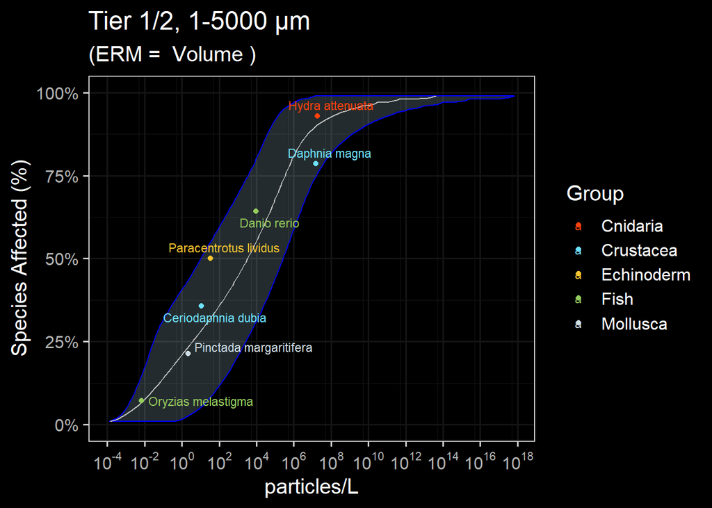

```r
###### --modelling ####
dists_tier1_2_large_1q <- ssd_fit_dists(tier1_2_large_1q, left = "Conc", dists = c("weibull", "llogis", "lnorm", "gamma", "lgumbel"), computable = FALSE, silent = FALSE)

#autoplot(dists_tier1_2_large_1q) #plots the distribution in ggplotier2
#### Goodness of fit ####
gof_tier1_2_large_1q <- as.data.frame(ssd_gof(dists_tier1_2_large_1q)) %>% mutate_if(is.numeric, ~ signif(., 3))

#### Prediction ####
set.seed(99)
pred_tier1_2_large_1q <- predict(dists_tier1_2_large_1q, average = TRUE, ic = "aicc", nboot = 10, ci= TRUE)

#order data
SSD_tier1_2_large_1q <- tier1_2_large_1q[order(tier1_2_large_1q$Conc), ]
SSD_tier1_2_large_1q$frac <- ppoints(tier1_2_large_1q$Conc, 0.5)

tier1_2_large_1q_lcl <- c(pred_tier1_2_large_1q$lcl[5]) #CI95
tier1_2_large_1q_hc5 <- c(pred_tier1_2_large_1q$est[5]) #HC5
pred_tier1_2_large_1q$est_format <-format(pred_tier1_2_large_1q$est, digits = 3, scientific = TRUE)


#add unique ID for multiplot
pred_tier1_2_large_1q_volume <- pred_tier1_2_large_1q
SSD_tier1_2_large_1q_volume <- SSD_tier1_2_large_1q

#ggplot
tier1_2_large_1q_ggplot <- ggplot(pred_tier1_2_large_1q,aes_string(x = "est")) +
      geom_xribbon(aes_string(xmin = "lcl", xmax = "ucl", y = "percent/100"), alpha = 0.2, color = "blue", fill = "lightblue") +
      geom_line(aes_string(y = "percent/100"), color = "gray") +
      geom_point(data = SSD_tier1_2_large_1q,aes(x = Conc, y =frac, color = Group)) +
      geom_text_repel(data = SSD_tier1_2_large_1q, aes(x = Conc, y = frac, label = Species, color = Group), nudge_x = 0.2, size = 3, segment.alpha = 0.5) +
      scale_y_continuous("Species Affected (%)", labels = scales::percent, limits = c(0,1)) +
  labs(title = "Microplastics Species Sensitivity Distribution",
             subtitle = paste("(ERM = ",ERM,")")) +
      coord_trans(x = "log10") +
      scale_x_continuous(breaks = scales::trans_breaks("log10", function(x) 10^x, n = 15),
                         labels = trans_format("log10", scales::math_format(10^.x))) +
  labs(title = "Tier 1/2, 1-5000 µm", x = "particles/L") +
      fill.type + #user-selected
      color.type + #user-selected
      theme.type #user theme

plot(tier1_2_large_1q_ggplot)
```

```r
# ###### --modelling ####
# dists_tier1_2_medium_1q <- ssd_fit_dists(tier1_2_medium_1q, left = "Conc", dists = c("weibull", "llogis", "lnorm", "gamma", "lgumbel"), computable = FALSE, silent = FALSE)
#
# #autoplot(dists_tier1_2_medium_1q) #plots the distribution in ggplotier2
# #### Goodness of fit ####
# gof_tier1_2_medium_1q <- as.data.frame(ssd_gof(dists_tier1_2_medium_1q)) %>% mutate_if(is.numeric, ~ signif(., 3))
#
# #### Prediction ####
# set.seed(99)
# pred_tier1_2_medium_1q <- predict(dists_tier1_2_medium_1q, average = TRUE, ic = "aicc", nboot = 10, ci= TRUE)
#
# #order data
# SSD_tier1_2_medium_1q <- tier1_2_medium_1q[order(tier1_2_medium_1q$Conc), ]
# SSD_tier1_2_medium_1q$frac <- ppoints(tier1_2_medium_1q$Conc, 0.5)
#
# tier1_2_medium_1q_lcl <- c(pred_tier1_2_medium_1q$lcl[5]) #CI95
# tier1_2_medium_1q_hc5 <- c(pred_tier1_2_medium_1q$est[5]) #HC5
# pred_tier1_2_medium_1q$est_format <-format(pred_tier1_2_medium_1q$est, digits = 3, scientific = TRUE)
#
# #ggplot
# tier1_2_medium_1q_ggplot <- ggplot(pred_tier1_2_medium_1q,aes_string(x = "est")) +
#       geom_xribbon(aes_string(xmin = "lcl", xmax = "ucl", y = "percent/100"), alpha = 0.2, color = "blue", fill = "lightblue") +
#       geom_line(aes_string(y = "percent/100"), color = "gray") +
#       geom_point(data = SSD_tier1_2_medium_1q,aes(x = Conc, y =frac, color = Group)) +
#       geom_text_repel(data = SSD_tier1_2_medium_1q, aes(x = Conc, y = frac, label = Species, color = Group), nudge_x = 0.2, size = 3, segment.alpha = 0.5) +
#       scale_y_continuous("Species Affected (%)", labels = scales::percent, limits = c(0,1)) +
#       coord_trans(x = "log10") +
#       scale_x_continuous(breaks = scales::trans_breaks("log10", function(x) 10^x, n = 15),
#                          labels = trans_format("log10", scales::math_format(10^.x))) +
#   labs(title = "Tier 1/2, 10-100 µm", x = "particles/L") +
#       fill.type + #user-selected
#       color.type + #user-selected
#       theme.type #user theme
#
# plot(tier1_2_medium_1q_ggplot)
```

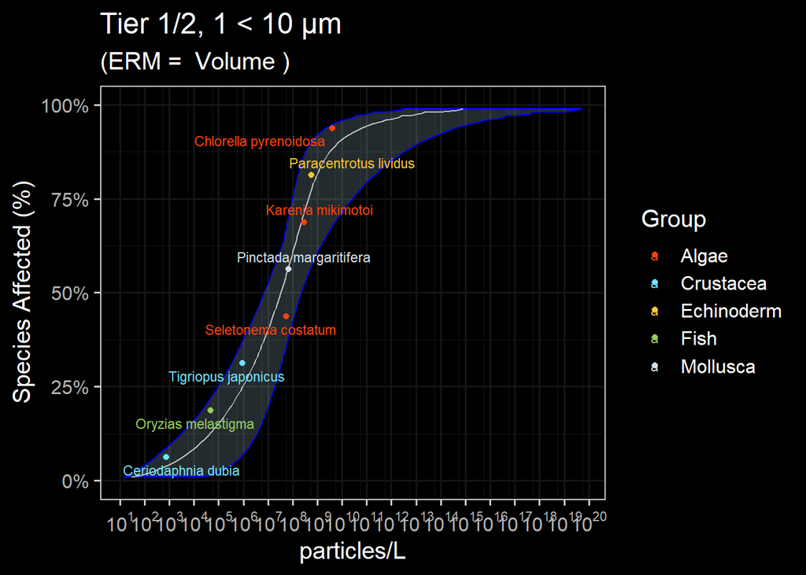

```r
###### --modelling ####
dists_tier1_2_small_1q <- ssd_fit_dists(tier1_2_small_1q, left = "Conc", dists = c("weibull", "llogis", "lnorm", "gamma", "lgumbel"), computable = FALSE, silent = FALSE)

#autoplot(dists_tier1_2_small_1q) #plots the distribution in ggplotier2
#### Goodness of fit ####
gof_tier1_2_small_1q <- as.data.frame(ssd_gof(dists_tier1_2_small_1q)) %>% mutate_if(is.numeric, ~ signif(., 3))

#### Prediction ####
set.seed(99)
pred_tier1_2_small_1q <- predict(dists_tier1_2_small_1q, average = TRUE, ic = "aicc", nboot = 10, ci= TRUE)

#order data
SSD_tier1_2_small_1q <- tier1_2_small_1q[order(tier1_2_small_1q$Conc), ]
SSD_tier1_2_small_1q$frac <- ppoints(tier1_2_small_1q$Conc, 0.5)

tier1_2_small_1q_lcl <- c(pred_tier1_2_small_1q$lcl[5]) #CI95
tier1_2_small_1q_hc5 <- c(pred_tier1_2_small_1q$est[5]) #HC5
pred_tier1_2_small_1q$est_format <-format(pred_tier1_2_small_1q$est, digits = 3, scientific = TRUE)

#ggplot
tier1_2_small_1q_ggplot <- ggplot(pred_tier1_2_small_1q,aes_string(x = "est")) +
      geom_xribbon(aes_string(xmin = "lcl", xmax = "ucl", y = "percent/100"), alpha = 0.2, color = "blue", fill = "lightblue") +
      geom_line(aes_string(y = "percent/100"), color = "gray") +
      geom_point(data = SSD_tier1_2_small_1q,aes(x = Conc, y =frac, color = Group)) +
      geom_text_repel(data = SSD_tier1_2_small_1q, aes(x = Conc, y = frac, label = Species, color = Group), nudge_x = 0.2, size = 3, segment.alpha = 0.5) +
      scale_y_continuous("Species Affected (%)", labels = scales::percent, limits = c(0,1)) +
  labs(title = "Microplastics Species Sensitivity Distribution",
             subtitle = paste("(ERM = ",ERM,")")) +
      coord_trans(x = "log10") +
      scale_x_continuous(breaks = scales::trans_breaks("log10", function(x) 10^x, n = 15),
                         labels = trans_format("log10", scales::math_format(10^.x))) +
  labs(title = "Tier 1/2, 1 < 10 µm", x = "particles/L") +
      fill.type + #user-selected
      color.type + #user-selected
      theme.type #user theme

plot(tier1_2_small_1q_ggplot)
```

#### 2.3.1.4 Tier 1 & 2 Summary Table

Hazard Confidence Level = HC5

Endpoints = All

Levels of Biological Organization = All

HC Metric = 95% CI (Tier 1); Mean (Tier 2)

Data Quality = Pass Technical Quality Red Criteria

```r
#save unique ID for ERM
tier1_large_v <- tier1_2_large_1q_lcl
tier2_large_v <- tier1_2_large_1q_hc5
tier1_small_v <- tier1_2_small_1q_lcl
tier2_small_v <- tier1_2_small_1q_hc5

larges <- list(tier1_2_large_1q_lcl, tier1_2_large_1q_hc5,
              tier1_2_large.obs[[1,1]], #n.obs
              tier1_2_large.obs[[1,2]], #n.studies
              tier1_2_large.obs[[1,3]], #n.taxa
              tier1_2_large.obs[[1,4]]) #n.species

# mediums <- list(tier1_2_medium_1q_lcl, tier1_2_medium_1q_hc5,
#               tier1_2_medium.obs[[1,1]], #n.obs
#               tier1_2_medium.obs[[1,2]], #n.studies
#               tier1_2_medium.obs[[1,3]], #n.taxa
#               tier1_2_medium.obs[[1,4]]) #n.species

smalls <- list(tier1_2_small_1q_lcl, tier1_2_small_1q_hc5,
              tier1_2_small.obs[[1,1]], #n.obs
              tier1_2_small.obs[[1,2]], #n.studies
              tier1_2_small.obs[[1,3]], #n.taxa
              tier1_2_small.obs[[1,4]]) #n.species

# Convert to data frames
largesdf <- data.frame(matrix(unlist(larges), ncol = 6))
# mediumsdf <- data.frame(matrix(unlist(mediums), ncol = 6))
smallsdf <- data.frame(matrix(unlist(smalls), ncol = 6))

# Rename columns
colnames(largesdf) <- c("Tier_1", "Tier_2", "N_Obs.", "N_Doi", "N_Taxa", "N_Species")
# colnames(mediumsdf) <- c("Tier_1", "Tier_2", "N_Obs.", "N_Doi", "N_Taxa", "N_Species")
colnames(smallsdf) <- c("Tier_1", "Tier_2", "N_Obs.", "N_Doi", "N_Taxa", "N_Species")

# Make tables

gt(largesdf) %>%
  tab_header(title = "Tier 1/2, 1µm - 5mm", subtitle = "Thresholds presented in particles/L") %>%
  fmt_number(columns = vars(Tier_1, Tier_2),decimals = 2, use_seps = TRUE)
```

Tier 1/2, 1µm - 5mm

Thresholds presented in particles/L

| Tier_1 | Tier_2 | N_Obs. | N_Doi | N_Taxa | N_Species |
| --- | --- | --- | --- | --- | --- |
| 0.00 | 0.00 | 220 | 8 | 5 | 7 |

```r
# gt(mediumsdf) %>%
#   tab_header(title = "Tier 1/2, 10-100 um", subtitle = "Thresholds presented in particles/L") %>%
#   fmt_number(columns = vars(Tier_1, Tier_2),decimals = 2, use_seps = TRUE)

gt(smallsdf) %>%
  tab_header(title = "Tier 1/2, 1-10µm ", subtitle = paste("Thresholds presented in particles/L; ERM = ",ERM)
             ) %>%
  fmt_number(columns = vars(Tier_1, Tier_2),decimals = 2, use_seps = TRUE)
```

Tier 1/2, 1-10µm

Thresholds presented in particles/L; ERM = Volume

| Tier_1 | Tier_2 | N_Obs. | N_Doi | N_Taxa | N_Species |
| --- | --- | --- | --- | --- | --- |
| 153.53 | 1,636.39 | 194 | 8 | 5 | 8 |

### 2.3.2 Tiers 3 & 4

Hazard Confidence Level = HC5(Tier3)/HC10(Tier4)

Endpoints = All

Levels of Biological Organization = Organism and Population

HC Metric = Mean

Data Quality = Pass Technical & Risk Quality Red Criteria

#### 2.3.2.1 Data Filtering

```r
#### Size filters ####

### 100 - 5000 um
tier3_4_large <-  aoc_final_large %>%
  filter(risk.13 != 1,
         bio_f %in% c("Organism", "Population")) %>%
         mutate(dose_new = EC_poly_v.particles.mL / (af.time * af.noec)) %>%
         drop_na(dose_new) %>%
         mutate(dose_new = dose_new*1000) %>%
  filter(size.length.um.used.for.conversions %in% (1:5000))

# Count observations and studies
tier3_4_large.obs <- tier3_4_large %>% summarize(n.obs = n(), n.studies = n_distinct(doi), n.taxa = n_distinct(org_f), n.species = n_distinct(species_f))

# ### 10 - 100 um
# tier3_4_medium <- tier3_4 %>%
#   filter(size_f %in% c("10µm < 100µm"))
#
# # Count observations and studies
# tier3_4_medium.obs <- tier3_4_medium %>% summarize(n.obs = n(), n.studies = n_distinct(doi), n.taxa = n_distinct(org_f), n.species = n_distinct(species_f))

### 1 - 10 um
tier3_4_small <- aoc_final_small %>%
  filter(risk.13 != 1,
         bio_f %in% c("Organism", "Population")) %>%
         mutate(dose_new = EC_poly_v.particles.mL / (af.time * af.noec)) %>%
         drop_na(dose_new) %>%
         mutate(dose_new = dose_new*1000) %>%
  filter(size.length.um.used.for.conversions %in% (1:10))

# Count observations and studies
tier3_4_small.obs <- tier3_4_small %>% summarize(n.obs = n(), n.studies = n_distinct(doi), n.taxa = n_distinct(org_f), n.species = n_distinct(species_f))
```

#### 2.3.2.2 Endpoint Representation

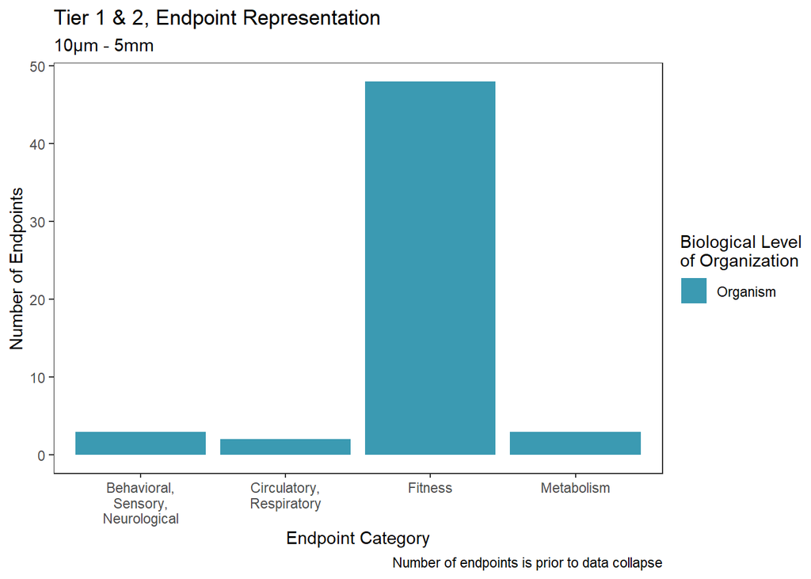

```r
#large
endpoints_tier3_4_large <- tier3_4_large %>%
  group_by(lvl1_f, bio_f) %>%
  mutate(lvl1_count = n()) %>%
  group_by(lvl1_f, lvl1_count, bio_f) %>%
  summarise() %>%
  ggplot(aes(x = lvl1_f, y=lvl1_count, fill = bio_f))+
  geom_bar(stat = "identity") +
  scale_fill_manual(values = wes_palette("Zissou1", 5, type = "continuous")) +
  labs(title = "Tier 1 & 2, Endpoint Representation", subtitle = "10µm - 5mm", x = "Endpoint Category", y = "Number of Endpoints", fill = "Biological Level\nof Organization", caption = "Number of endpoints is prior to data collapse") +
  theme_test() +
  scale_x_discrete(labels = wrap_format(10))


plot(endpoints_tier3_4_large)
```

```r
#medium
# endpoints_tier3_4_medium <- tier3_4_medium %>%
#   group_by(lvl1_f, bio_f) %>%
#   mutate(lvl1_count = n()) %>%
#   group_by(lvl1_f, lvl1_count, bio_f) %>%
#   summarise() %>%
#   ggplot(aes(x = lvl1_f, y=lvl1_count, fill = bio_f))+
#   geom_bar(stat = "identity") +
#   scale_fill_manual(values = wes_palette("Zissou1", 5, type = "continuous")) +
#   labs(title = "Tier 1 & 2, Endpoint Representation", subtitle = "10µm < 100µm", x = "Endpoint Category", y = "Number of Endpoints", fill = "Biological Level\nof Organization", caption = "Number of endpoints is prior to data collapse") +
#   theme_test() +
#   scale_x_discrete(labels = wrap_format(10))
#
#
# plot(endpoints_tier3_4_medium)

#small
endpoints_tier3_4_small <- tier3_4_small %>%
  group_by(lvl1_f, bio_f) %>%
  mutate(lvl1_count = n()) %>%
  group_by(lvl1_f, lvl1_count, bio_f) %>%
  summarise() %>%
  ggplot(aes(x = lvl1_f, y=lvl1_count, fill = bio_f))+
  geom_bar(stat = "identity") +
  scale_fill_manual(values = wes_palette("Zissou1", 5, type = "continuous")) +
  labs(title = "Tier 1 & 2, Endpoint Representation", subtitle = "1µm < 100µm", x = "Endpoint Category", y = "Number of Endpoints", fill = "Biological Level\nof Organization", caption = "Number of endpoints is prior to data collapse") +
  theme_test() +
  scale_x_discrete(labels = wrap_format(10))


plot(endpoints_tier3_4_small)
```

#### 2.3.2.3 SSD Build

##### 2.3.2.3.1 Data Collapse

```r
#First quartile large particles
tier3_4_large_median <- tier3_4_large %>%
  group_by(Species, Group) %>%
  summarize(Conc = median(dose_new))
#First quartile medium particles
# tier3_4_medium_median <- tier3_4_medium %>%
#   group_by(Species, Group) %>%
#   summarize(Conc = median(dose_new))

#First quartile small particles
tier3_4_small_median <- tier3_4_small %>%
  group_by(Species, Group) %>%
  summarize(Conc = median(dose_new))
```

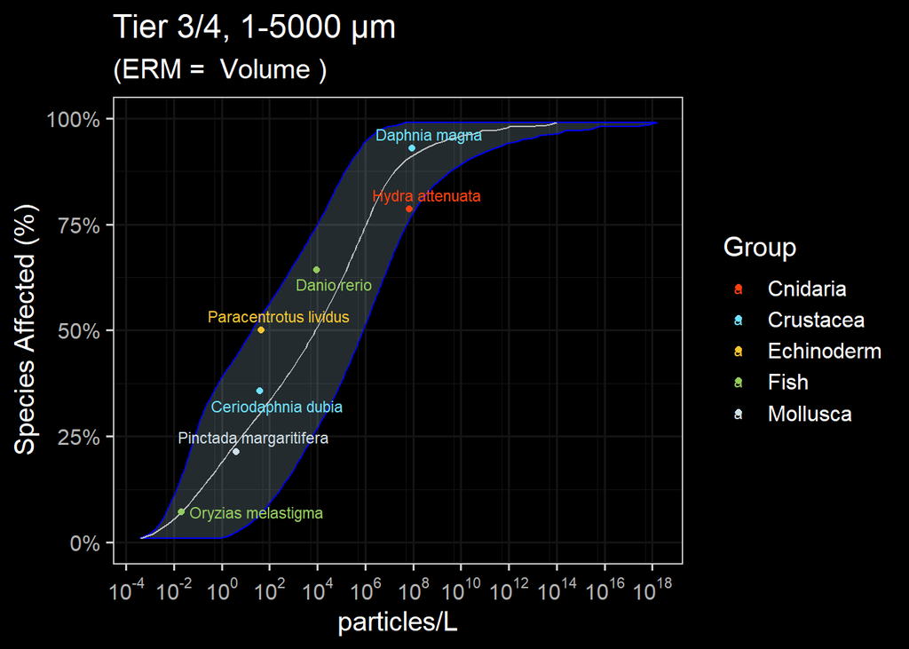

```r
###### --modelling ####
dists_tier3_4_large_median <- ssd_fit_dists(tier3_4_large_median, left = "Conc", dists = c("weibull", "llogis", "lnorm", "gamma", "lgumbel"), computable = FALSE, silent = FALSE)

#autoplot(dists_tier3_4_large_median) #plots the distribution in ggplotier2
#### Goodness of fit ####
gof_tier3_4_large_median <- as.data.frame(ssd_gof(dists_tier3_4_large_median)) %>% mutate_if(is.numeric, ~ signif(., 3))

#### Prediction ####
set.seed(99)
pred_tier3_4_large_median <- predict(dists_tier3_4_large_median, average = TRUE, ic = "aicc", nboot = 10, ci= TRUE)

#order data
SSD_tier3_4_large_median <- tier3_4_large_median[order(tier3_4_large_median$Conc), ]
SSD_tier3_4_large_median$frac <- ppoints(tier3_4_large_median$Conc, 0.5)

tier3_4_large_median_hc5 <- c(pred_tier3_4_large_median$est[5]) #HC5
tier3_4_large_median_hc10 <- c(pred_tier3_4_large_median$est[10]) #HC10
pred_tier3_4_large_median$est_format <-format(pred_tier3_4_large_median$est, digits = 3, scientific = TRUE)

#ggplot
tier3_4_large_median_ggplot <- ggplot(pred_tier3_4_large_median,aes_string(x = "est")) +
      geom_xribbon(aes_string(xmin = "lcl", xmax = "ucl", y = "percent/100"), alpha = 0.2, color = "blue", fill = "lightblue") +
      geom_line(aes_string(y = "percent/100"), color = "gray") +
      geom_point(data = SSD_tier3_4_large_median,aes(x = Conc, y =frac, color = Group)) +
      geom_text_repel(data = SSD_tier3_4_large_median, aes(x = Conc, y = frac, label = Species, color = Group), nudge_x = 0.2, size = 3, segment.alpha = 0.5) +
      scale_y_continuous("Species Affected (%)", labels = scales::percent, limits = c(0,1)) +
  labs(title = "Microplastics Species Sensitivity Distribution",
             subtitle = paste("(ERM = ",ERM,")")) +
      coord_trans(x = "log10") +
      scale_x_continuous(breaks = scales::trans_breaks("log10", function(x) 10^x, n = 15),
                         labels = trans_format("log10", scales::math_format(10^.x))) +
  labs(title = "Tier 3/4, 1-5000 µm", x = "particles/L") +
      fill.type + #user-selected
      color.type + #user-selected
      theme.type #user theme

plot(tier3_4_large_median_ggplot)
```

```r
###### --modelling ####
# dists_tier3_4_medium_median <- ssd_fit_dists(tier3_4_medium_median, left = "Conc", dists = c("weibull", "llogis", "lnorm", "gamma", "lgumbel"), computable = FALSE, silent = FALSE)
#
# #autoplot(dists_tier3_4_medium_median) #plots the distribution in ggplotier2
# #### Goodness of fit ####
# gof_tier3_4_medium_median <- as.data.frame(ssd_gof(dists_tier3_4_medium_median)) %>% mutate_if(is.numeric, ~ signif(., 3))
#
# #### Prediction ####
# set.seed(99)
# pred_tier3_4_medium_median <- predict(dists_tier3_4_medium_median, average = TRUE, ic = "aicc", nboot = 10, ci= TRUE)
#
# #order data
# SSD_tier3_4_medium_median <- tier3_4_medium_median[order(tier3_4_medium_median$Conc), ]
# SSD_tier3_4_medium_median$frac <- ppoints(tier3_4_medium_median$Conc, 0.5)
#
# tier3_4_medium_median_hc5 <- c(pred_tier3_4_medium_median$est[5]) #HC5
# tier3_4_medium_median_hc10 <- c(pred_tier3_4_medium_median$est[10]) #HC10
# pred_tier3_4_medium_median$est_format <-format(pred_tier3_4_medium_median$est, digits = 3, scientific = TRUE)
#
# #ggplot
# tier3_4_medium_median_ggplot <- ggplot(pred_tier3_4_medium_median,aes_string(x = "est")) +
#       geom_xribbon(aes_string(xmin = "lcl", xmax = "ucl", y = "percent/100"), alpha = 0.2, color = "blue", fill = "lightblue") +
#       geom_line(aes_string(y = "percent/100"), color = "gray") +
#       geom_point(data = SSD_tier3_4_medium_median,aes(x = Conc, y =frac, color = Group)) +
#       geom_text_repel(data = SSD_tier3_4_medium_median, aes(x = Conc, y = frac, label = Species, color = Group), nudge_x = 0.2, size = 3, segment.alpha = 0.5) +
#       scale_y_continuous("Species Affected (%)", labels = scales::percent, limits = c(0,1)) +
#       coord_trans(x = "log10") +
#       scale_x_continuous(breaks = scales::trans_breaks("log10", function(x) 10^x, n = 15),
#                          labels = trans_format("log10", scales::math_format(10^.x))) +
#   labs(title = "Tier 3/4, 10-100 µm", x = "particles/L") +
#       fill.type + #user-selected
#       color.type + #user-selected
#       theme.type #user theme
#
# tier3_4_medium_median_ggplot
```

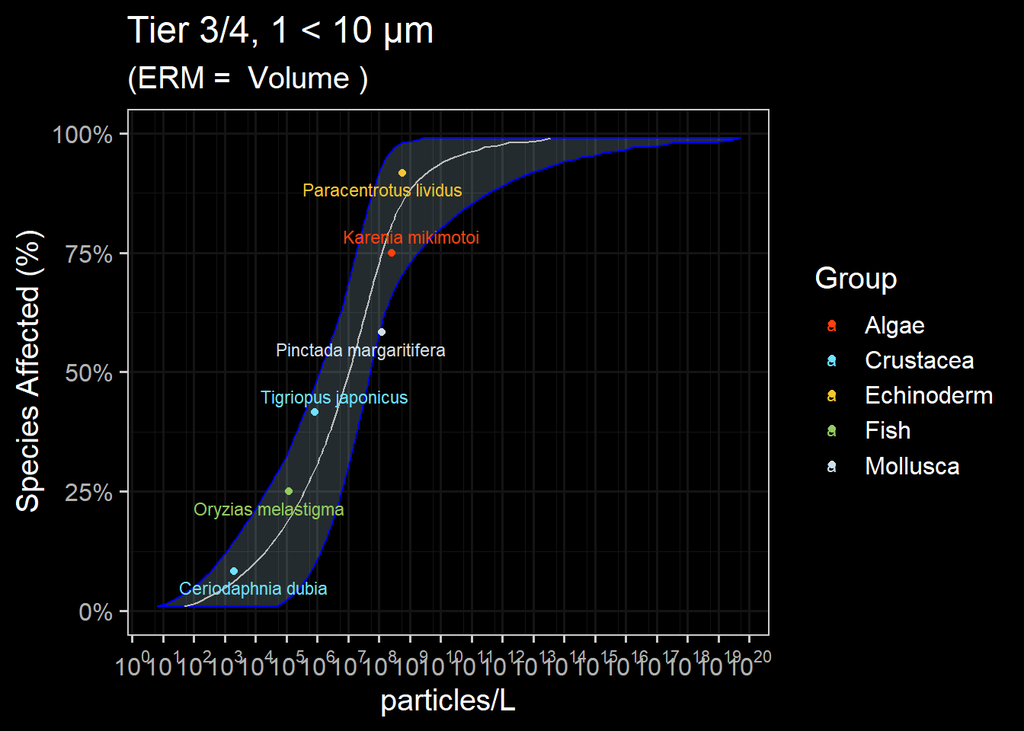

```r
###### --modelling ####
dists_tier3_4_small_median <- ssd_fit_dists(tier3_4_small_median, left = "Conc", dists = c("weibull", "llogis", "lnorm", "gamma", "lgumbel"), computable = FALSE, silent = FALSE)

#autoplot(dists_tier3_4_small_median) #plots the distribution in ggplotier2
#### Goodness of fit ####
gof_tier3_4_small_median <- as.data.frame(ssd_gof(dists_tier3_4_small_median)) %>% mutate_if(is.numeric, ~ signif(., 3))

#### Prediction ####
set.seed(99)
pred_tier3_4_small_median <- predict(dists_tier3_4_small_median, average = TRUE, ic = "aicc", nboot = 10, ci= TRUE)

#order data
SSD_tier3_4_small_median <- tier3_4_small_median[order(tier3_4_small_median$Conc), ]
SSD_tier3_4_small_median$frac <- ppoints(tier3_4_small_median$Conc, 0.5)

tier3_4_small_median_hc5 <- c(pred_tier3_4_small_median$est[5]) #HC5
tier3_4_small_median_hc10 <- c(pred_tier3_4_small_median$est[10]) #HC10
pred_tier3_4_small_median$est_format <-format(pred_tier3_4_small_median$est, digits = 3, scientific = TRUE)

#ggplot
tier3_4_small_median_ggplot <- ggplot(pred_tier3_4_small_median,aes_string(x = "est")) +
      geom_xribbon(aes_string(xmin = "lcl", xmax = "ucl", y = "percent/100"), alpha = 0.2, color = "blue", fill = "lightblue") +
      geom_line(aes_string(y = "percent/100"), color = "gray") +
      geom_point(data = SSD_tier3_4_small_median,aes(x = Conc, y =frac, color = Group)) +
      geom_text_repel(data = SSD_tier3_4_small_median, aes(x = Conc, y = frac, label = Species, color = Group), nudge_x = 0.2, size = 3, segment.alpha = 0.5) +
      scale_y_continuous("Species Affected (%)", labels = scales::percent, limits = c(0,1)) +
  labs(title = "Microplastics Species Sensitivity Distribution",
             subtitle = paste("(ERM = ",ERM,")")) +
      coord_trans(x = "log10") +
      scale_x_continuous(breaks = scales::trans_breaks("log10", function(x) 10^x, n = 15),
                         labels = trans_format("log10", scales::math_format(10^.x))) +
  labs(title = "Tier 3/4, 1 < 10 µm", x = "particles/L") +
      fill.type + #user-selected
      color.type + #user-selected
      theme.type #user theme

plot(tier3_4_small_median_ggplot)
```

##### 2.3.2.3.4 Tier 3 & 4 Summary Table

Hazard Confidence Level = HC5(Tier3)/HC10(Tier4)

Endpoints = All

Levels of Biological Organization = Organism and Population

HC Metric = Mean

Data Quality = Pass Technical & Risk Quality Red Criteria

```r
#save unique ID for ERM
tier3_large_v <- tier3_4_large_median_hc5
tier4_large_v <- tier3_4_large_median_hc10
tier3_small_v <- tier3_4_small_median_hc5
tier4_small_v <- tier3_4_small_median_hc10

larges <- list(tier3_4_large_median_hc5, tier3_4_large_median_hc10,
              tier3_4_large.obs[[1,1]], #n.obs
              tier3_4_large.obs[[1,2]], #n.studies
              tier3_4_large.obs[[1,3]], #n.taxa
              tier3_4_large.obs[[1,4]]) #n.species

# mediums <- list(tier3_4_medium_median_hc5, tier3_4_medium_median_hc10,
#               tier3_4_medium.obs[[1,1]], #n.obs
#               tier3_4_medium.obs[[1,2]], #n.studies
#               tier3_4_medium.obs[[1,3]], #n.taxa
#               tier3_4_medium.obs[[1,4]]) #n.species

smalls <- list(tier3_4_small_median_hc5, tier3_4_small_median_hc10,
              tier3_4_small.obs[[1,1]], #n.obs
              tier3_4_small.obs[[1,2]], #n.studies
              tier3_4_small.obs[[1,3]], #n.taxa
              tier3_4_small.obs[[1,4]]) #n.species

# Convert to data frames
largesdf <- data.frame(matrix(unlist(larges), ncol = 6))
# mediumsdf <- data.frame(matrix(unlist(mediums), ncol = 6))
smallsdf <- data.frame(matrix(unlist(smalls), ncol = 6))

# Rename columns
colnames(largesdf) <- c("Tier_3", "Tier_4", "N_Obs.", "N_Doi", "N_Taxa", "N_Species")
# colnames(mediumsdf) <- c("Tier_1", "Tier_2", "N_Obs.", "N_Doi", "N_Taxa", "N_Species")
colnames(smallsdf) <- c("Tier_3", "Tier_4", "N_Obs.", "N_Doi", "N_Taxa", "N_Species")

# Make tables

gt(largesdf) %>%
  tab_header(title = "Tier 3/4, 1-5000 µm", subtitle = "Thresholds presented in particles/L") %>%
  fmt_number(columns = vars(Tier_3, Tier_4),decimals = 2, use_seps = TRUE)
```

Tier 3/4, 1-5000 µm

Thresholds presented in particles/L

| Tier_3 | Tier_4 | N_Obs. | N_Doi | N_Taxa | N_Species |
| --- | --- | --- | --- | --- | --- |
| 0.01 | 0.06 | 56 | 8 | 5 | 7 |

```r
# gt(mediumsdf) %>%
#   tab_header(title = "Tier 3/4, 10-100 um", subtitle = "Thresholds presented in particles/L") %>%
#   fmt_number(columns = vars(Tier_3, Tier_4),decimals = 2, use_seps = TRUE)

gt(smallsdf) %>%
  tab_header(title = "Tier 3/4, 1-10µm ", subtitle = "Thresholds presented in particles/L") %>%
  fmt_number(columns = vars(Tier_3, Tier_4),decimals = 2, use_seps = TRUE)
```

Tier 3/4, 1-10µm

Thresholds presented in particles/L

| Tier_3 | Tier_4 | N_Obs. | N_Doi | N_Taxa | N_Species |
| --- | --- | --- | --- | --- | --- |
| 1,058.01 | 9,249.57 | 23 | 6 | 5 | 6 |

## 2.4 ERM = Surface Area

```r
ERM <- "Surface Area"
```

### 2.4.1 Tiers 1 & 2

Tier 1 and 2 are the same SSD. A different HC metric is selected to differentiate between the tiers. Specifically, Tier 1 uses the 95% CI whereas Tier 2 uses the Mean. See below for more details of specific parameters.

Hazard Confidence Level = HC5

Endpoints = All

Levels of Biological Organization = All

HC Metric = 95% CI (Tier 1); Mean (Tier 2)

Data Quality = Pass Technical Quality Red Criteria

#### 2.4.1.1 Data Filtering

```r
tier1_2_large <- aoc_final_large %>%
         mutate(dose_new = EC_env_sa.particles.mL / (af.time * af.noec)) %>%
         drop_na(dose_new) %>%
         mutate(dose_new = dose_new * 1000) %>%
  filter(size.length.um.used.for.conversions %in% (1:5000))

# Count observations and studies
tier1_2_large.obs <- tier1_2_large %>% summarize(n.obs = n(), n.studies = n_distinct(doi), n.taxa = n_distinct(org_f), n.species = n_distinct(species_f))

# ### 10 - 100 um
# tier1_2_medium <- tier1_2 %>%
#   filter(size_f %in% c("10µm < 100µm"))
#
# # Count observations and studies
# tier1_2_medium.obs <- tier1_2_medium %>% summarize(n.obs = n(), n.studies = n_distinct(doi), n.taxa = n_distinct(org_f), n.species = n_distinct(species_f))

### 1 - 100 um
tier1_2_small <- aoc_final_small %>%
         mutate(dose_new = EC_env_sa.particles.mL / (af.time * af.noec)) %>%
         drop_na(dose_new) %>%
         mutate(dose_new = dose_new * 1000) %>%
  filter(size.length.um.used.for.conversions %in% (1:10))

# Count observations and studies
tier1_2_small.obs <- tier1_2_small %>% summarize(n.obs = n(), n.studies = n_distinct(doi), n.taxa = n_distinct(org_f), n.species = n_distinct(species_f))
```

#### 2.4.1.2 Endpoint Representation

```r
#large
endpoints_tier1_2_large <- tier1_2_large %>%
  group_by(lvl1_f, bio_f) %>%
  mutate(lvl1_count = n()) %>%
  group_by(lvl1_f, lvl1_count, bio_f) %>%
  summarise() %>%
  ggplot(aes(x = lvl1_f, y=lvl1_count, fill = bio_f))+
  geom_bar(stat = "identity") +
  scale_fill_manual(values = wes_palette("Zissou1", 5, type = "continuous")) +
  labs(title = "Tier 1 & 2, Endpoint Representation", subtitle = "1µm - 5mm", x = "Endpoint Category", y = "Number of Endpoints", fill = "Biological Level\nof Organization", caption = "Number of endpoints is prior to data collapse") +
  theme_test() +
  scale_x_discrete(labels = wrap_format(10))


# plot(endpoints_tier1_2_large)

#medium
# endpoints_tier1_2_medium <- tier1_2_medium %>%
#   group_by(lvl1_f, bio_f) %>%
#   mutate(lvl1_count = n()) %>%
#   group_by(lvl1_f, lvl1_count, bio_f) %>%
#   summarise() %>%
#   ggplot(aes(x = lvl1_f, y=lvl1_count, fill = bio_f))+
#   geom_bar(stat = "identity") +
#   scale_fill_manual(values = wes_palette("Zissou1", 5, type = "continuous")) +
#   labs(title = "Tier 1 & 2, Endpoint Representation", subtitle = "10µm < 100µm", x = "Endpoint Category", y = "Number of Endpoints", fill = "Biological Level\nof Organization", caption = "Number of endpoints is prior to data collapse") +
#   theme_test() +
#   scale_x_discrete(labels = wrap_format(10))
#
#
# plot(endpoints_tier1_2_medium)

#small
endpoints_tier1_2_small <- tier1_2_small %>%
  group_by(lvl1_f, bio_f) %>%
  mutate(lvl1_count = n()) %>%
  group_by(lvl1_f, lvl1_count, bio_f) %>%
  summarise() %>%
  ggplot(aes(x = lvl1_f, y=lvl1_count, fill = bio_f))+
  geom_bar(stat = "identity") +
  scale_fill_manual(values = wes_palette("Zissou1", 5, type = "continuous")) +
  labs(title = "Tier 1 & 2, Endpoint Representation", subtitle = "1µm < 100µm", x = "Endpoint Category", y = "Number of Endpoints", fill = "Biological Level\nof Organization", caption = "Number of endpoints is prior to data collapse") +
  theme_test() +
  scale_x_discrete(labels = wrap_format(10))


# plot(endpoints_tier1_2_small)
```

#### 2.4.1.3 SSD Build

##### 2.4.1.3.1 Data Collapse

```r
#First quartile large particles
tier1_2_large_1q <- tier1_2_large %>%
  group_by(Species, Group) %>%
  summarize(Conc = quantile(dose_new, 0.25))
#First quartile medium particles
# tier1_2_medium_1q <- tier1_2_medium %>%
#   group_by(Species, Group) %>%
#   summarize(Conc = quantile(dose_new, 0.25))

#First quartile small particles
tier1_2_small_1q <- tier1_2_small %>%
  group_by(Species, Group) %>%
  summarize(Conc = quantile(dose_new, 0.25))
```

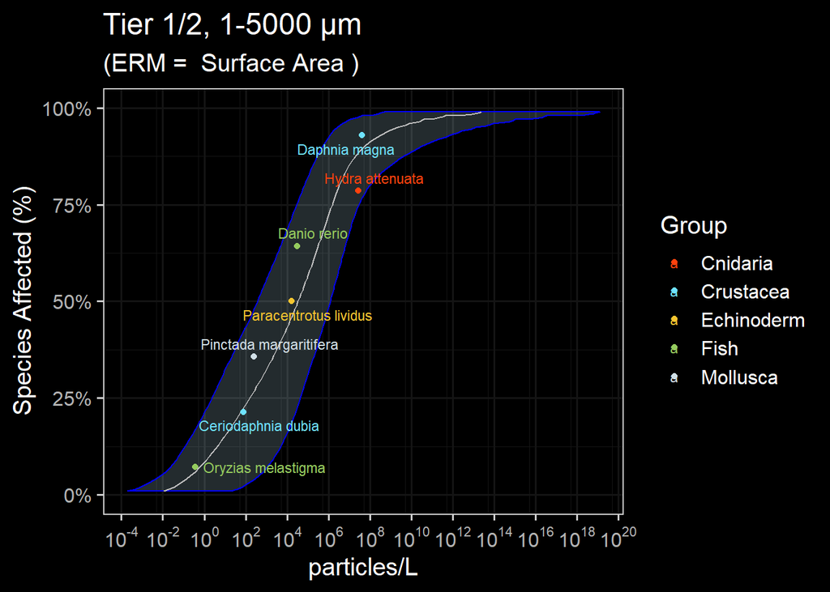

```r
###### --modelling ####
dists_tier1_2_large_1q <- ssd_fit_dists(tier1_2_large_1q, left = "Conc", dists = c("weibull", "llogis", "lnorm", "gamma", "lgumbel"), computable = FALSE, silent = FALSE)

#autoplot(dists_tier1_2_large_1q) #plots the distribution in ggplotier2
#### Goodness of fit ####
gof_tier1_2_large_1q <- as.data.frame(ssd_gof(dists_tier1_2_large_1q)) %>% mutate_if(is.numeric, ~ signif(., 3))

#### Prediction ####
set.seed(99)
pred_tier1_2_large_1q <- predict(dists_tier1_2_large_1q, average = TRUE, ic = "aicc", nboot = 10, ci= TRUE)

#order data
SSD_tier1_2_large_1q <- tier1_2_large_1q[order(tier1_2_large_1q$Conc), ]
SSD_tier1_2_large_1q$frac <- ppoints(tier1_2_large_1q$Conc, 0.5)

tier1_2_large_1q_lcl <- c(pred_tier1_2_large_1q$lcl[5]) #CI95
tier1_2_large_1q_hc5 <- c(pred_tier1_2_large_1q$est[5]) #HC5
pred_tier1_2_large_1q$est_format <-format(pred_tier1_2_large_1q$est, digits = 3, scientific = TRUE)

#add unique ID for multiplot
pred_tier1_2_large_1q_surfacearea <- pred_tier1_2_large_1q
SSD_tier1_2_large_1q_surfacearea <- SSD_tier1_2_large_1q

#ggplot
tier1_2_large_1q_ggplot <- ggplot(pred_tier1_2_large_1q,aes_string(x = "est")) +
      geom_xribbon(aes_string(xmin = "lcl", xmax = "ucl", y = "percent/100"), alpha = 0.2, color = "blue", fill = "lightblue") +
      geom_line(aes_string(y = "percent/100"), color = "gray") +
      geom_point(data = SSD_tier1_2_large_1q,aes(x = Conc, y =frac, color = Group)) +
      geom_text_repel(data = SSD_tier1_2_large_1q, aes(x = Conc, y = frac, label = Species, color = Group), nudge_x = 0.2, size = 3, segment.alpha = 0.5) +
      scale_y_continuous("Species Affected (%)", labels = scales::percent, limits = c(0,1)) +
  labs(title = "Microplastics Species Sensitivity Distribution",
             subtitle = paste("(ERM = ",ERM,")")) +
      coord_trans(x = "log10") +
      scale_x_continuous(breaks = scales::trans_breaks("log10", function(x) 10^x, n = 15),
                         labels = trans_format("log10", scales::math_format(10^.x))) +
  labs(title = "Tier 1/2, 1-5000 µm", x = "particles/L") +
      fill.type + #user-selected
      color.type + #user-selected
      theme.type #user theme

plot(tier1_2_large_1q_ggplot)
```

```r
# ###### --modelling ####
# dists_tier1_2_medium_1q <- ssd_fit_dists(tier1_2_medium_1q, left = "Conc", dists = c("weibull", "llogis", "lnorm", "gamma", "lgumbel"), computable = FALSE, silent = FALSE)
#
# #autoplot(dists_tier1_2_medium_1q) #plots the distribution in ggplotier2
# #### Goodness of fit ####
# gof_tier1_2_medium_1q <- as.data.frame(ssd_gof(dists_tier1_2_medium_1q)) %>% mutate_if(is.numeric, ~ signif(., 3))
#
# #### Prediction ####
# set.seed(99)
# pred_tier1_2_medium_1q <- predict(dists_tier1_2_medium_1q, average = TRUE, ic = "aicc", nboot = 10, ci= TRUE)
#
# #order data
# SSD_tier1_2_medium_1q <- tier1_2_medium_1q[order(tier1_2_medium_1q$Conc), ]
# SSD_tier1_2_medium_1q$frac <- ppoints(tier1_2_medium_1q$Conc, 0.5)
#
# tier1_2_medium_1q_lcl <- c(pred_tier1_2_medium_1q$lcl[5]) #CI95
# tier1_2_medium_1q_hc5 <- c(pred_tier1_2_medium_1q$est[5]) #HC5
# pred_tier1_2_medium_1q$est_format <-format(pred_tier1_2_medium_1q$est, digits = 3, scientific = TRUE)
#
# #ggplot
# tier1_2_medium_1q_ggplot <- ggplot(pred_tier1_2_medium_1q,aes_string(x = "est")) +
#       geom_xribbon(aes_string(xmin = "lcl", xmax = "ucl", y = "percent/100"), alpha = 0.2, color = "blue", fill = "lightblue") +
#       geom_line(aes_string(y = "percent/100"), color = "gray") +
#       geom_point(data = SSD_tier1_2_medium_1q,aes(x = Conc, y =frac, color = Group)) +
#       geom_text_repel(data = SSD_tier1_2_medium_1q, aes(x = Conc, y = frac, label = Species, color = Group), nudge_x = 0.2, size = 3, segment.alpha = 0.5) +
#       scale_y_continuous("Species Affected (%)", labels = scales::percent, limits = c(0,1)) +
#       coord_trans(x = "log10") +
#       scale_x_continuous(breaks = scales::trans_breaks("log10", function(x) 10^x, n = 15),
#                          labels = trans_format("log10", scales::math_format(10^.x))) +
#   labs(title = "Tier 1/2, 10-100 µm", x = "particles/L") +
#       fill.type + #user-selected
#       color.type + #user-selected
#       theme.type #user theme
#
# plot(tier1_2_medium_1q_ggplot)
```

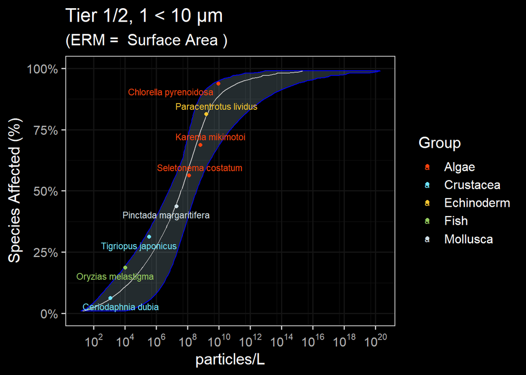

```r
###### --modelling ####
dists_tier1_2_small_1q <- ssd_fit_dists(tier1_2_small_1q, left = "Conc", dists = c("weibull", "llogis", "lnorm", "gamma", "lgumbel"), computable = FALSE, silent = FALSE)

#autoplot(dists_tier1_2_small_1q) #plots the distribution in ggplotier2
#### Goodness of fit ####
gof_tier1_2_small_1q <- as.data.frame(ssd_gof(dists_tier1_2_small_1q)) %>% mutate_if(is.numeric, ~ signif(., 3))

#### Prediction ####
set.seed(99)
pred_tier1_2_small_1q <- predict(dists_tier1_2_small_1q, average = TRUE, ic = "aicc", nboot = 10, ci= TRUE)

#order data
SSD_tier1_2_small_1q <- tier1_2_small_1q[order(tier1_2_small_1q$Conc), ]
SSD_tier1_2_small_1q$frac <- ppoints(tier1_2_small_1q$Conc, 0.5)

tier1_2_small_1q_lcl <- c(pred_tier1_2_small_1q$lcl[5]) #CI95
tier1_2_small_1q_hc5 <- c(pred_tier1_2_small_1q$est[5]) #HC5
pred_tier1_2_small_1q$est_format <-format(pred_tier1_2_small_1q$est, digits = 3, scientific = TRUE)

#ggplot
tier1_2_small_1q_ggplot <- ggplot(pred_tier1_2_small_1q,aes_string(x = "est")) +
      geom_xribbon(aes_string(xmin = "lcl", xmax = "ucl", y = "percent/100"), alpha = 0.2, color = "blue", fill = "lightblue") +
      geom_line(aes_string(y = "percent/100"), color = "gray") +
      geom_point(data = SSD_tier1_2_small_1q,aes(x = Conc, y =frac, color = Group)) +
      geom_text_repel(data = SSD_tier1_2_small_1q, aes(x = Conc, y = frac, label = Species, color = Group), nudge_x = 0.2, size = 3, segment.alpha = 0.5) +
      scale_y_continuous("Species Affected (%)", labels = scales::percent, limits = c(0,1)) +
  labs(title = "Microplastics Species Sensitivity Distribution",
             subtitle = paste("(ERM = ",ERM,")")) +
      coord_trans(x = "log10") +
      scale_x_continuous(breaks = scales::trans_breaks("log10", function(x) 10^x, n = 15),
                         labels = trans_format("log10", scales::math_format(10^.x))) +
  labs(title = "Tier 1/2, 1 < 10 µm", x = "particles/L") +
      fill.type + #user-selected
      color.type + #user-selected
      theme.type #user theme

plot(tier1_2_small_1q_ggplot)
```

#### 2.4.1.4 Tier 1 & 2 Summary Table

Hazard Confidence Level = HC5

Endpoints = All

Levels of Biological Organization = All

HC Metric = 95% CI (Tier 1); Mean (Tier 2)

Data Quality = Pass Technical Quality Red Criteria

```r
#save unique ID for ERM
tier1_large_sa <- tier1_2_large_1q_lcl
tier2_large_sa <- tier1_2_large_1q_hc5
tier1_small_sa <- tier1_2_small_1q_lcl
tier2_small_sa <- tier1_2_small_1q_hc5

larges <- list(tier1_2_large_1q_lcl, tier1_2_large_1q_hc5,
              tier1_2_large.obs[[1,1]], #n.obs
              tier1_2_large.obs[[1,2]], #n.studies
              tier1_2_large.obs[[1,3]], #n.taxa
              tier1_2_large.obs[[1,4]]) #n.species

# mediums <- list(tier1_2_medium_1q_lcl, tier1_2_medium_1q_hc5,
#               tier1_2_medium.obs[[1,1]], #n.obs
#               tier1_2_medium.obs[[1,2]], #n.studies
#               tier1_2_medium.obs[[1,3]], #n.taxa
#               tier1_2_medium.obs[[1,4]]) #n.species

smalls <- list(tier1_2_small_1q_lcl, tier1_2_small_1q_hc5,
              tier1_2_small.obs[[1,1]], #n.obs
              tier1_2_small.obs[[1,2]], #n.studies
              tier1_2_small.obs[[1,3]], #n.taxa
              tier1_2_small.obs[[1,4]]) #n.species

# Convert to data frames
largesdf <- data.frame(matrix(unlist(larges), ncol = 6))
# mediumsdf <- data.frame(matrix(unlist(mediums), ncol = 6))
smallsdf <- data.frame(matrix(unlist(smalls), ncol = 6))

# Rename columns
colnames(largesdf) <- c("Tier_1", "Tier_2", "N_Obs.", "N_Doi", "N_Taxa", "N_Species")
# colnames(mediumsdf) <- c("Tier_1", "Tier_2", "N_Obs.", "N_Doi", "N_Taxa", "N_Species")
colnames(smallsdf) <- c("Tier_1", "Tier_2", "N_Obs.", "N_Doi", "N_Taxa", "N_Species")

# Make tables

gt(largesdf) %>%
  tab_header(title = "Tier 1/2, 1µm - 5mm", subtitle = "Thresholds presented in particles/L") %>%
  fmt_number(columns = vars(Tier_1, Tier_2),decimals = 2, use_seps = TRUE)
```

Tier 1/2, 1µm - 5mm

Thresholds presented in particles/L

| Tier_1 | Tier_2 | N_Obs. | N_Doi | N_Taxa | N_Species |
| --- | --- | --- | --- | --- | --- |
| 0.01 | 0.22 | 220 | 8 | 5 | 7 |

```r
# gt(mediumsdf) %>%
#   tab_header(title = "Tier 1/2, 10-100 um", subtitle = "Thresholds presented in particles/L") %>%
#   fmt_number(columns = vars(Tier_1, Tier_2),decimals = 2, use_seps = TRUE)

gt(smallsdf) %>%
  tab_header(title = "Tier 1/2, 1-10µm ", subtitle = paste("Thresholds presented in particles/L; ERM = ",ERM)
             ) %>%
  fmt_number(columns = vars(Tier_1, Tier_2),decimals = 2, use_seps = TRUE)
```

Tier 1/2, 1-10µm

Thresholds presented in particles/L; ERM = Surface Area

| Tier_1 | Tier_2 | N_Obs. | N_Doi | N_Taxa | N_Species |
| --- | --- | --- | --- | --- | --- |
| 120.33 | 629.00 | 194 | 8 | 5 | 8 |

### 2.4.2 Tiers 3 & 4

Hazard Confidence Level = HC5(Tier3)/HC10(Tier4)

Endpoints = All

Levels of Biological Organization = Organism and Population

HC Metric = Mean

Data Quality = Pass Technical & Risk Quality Red Criteria

#### 2.4.2.1 Data Filtering

```r
#### Size filters ####

### 100 - 5000 um
tier3_4_large <-  aoc_final_large %>%
  filter(risk.13 != 1,
         bio_f %in% c("Organism", "Population")) %>%
         mutate(dose_new = EC_poly_sa.particles.mL / (af.time * af.noec)) %>%
         drop_na(dose_new) %>%
         mutate(dose_new = dose_new*1000) %>%
  filter(size.length.um.used.for.conversions %in% (1:5000))

# Count observations and studies
tier3_4_large.obs <- tier3_4_large %>% summarize(n.obs = n(), n.studies = n_distinct(doi), n.taxa = n_distinct(org_f), n.species = n_distinct(species_f))

# ### 10 - 100 um
# tier3_4_medium <- tier3_4 %>%
#   filter(size_f %in% c("10µm < 100µm"))
#
# # Count observations and studies
# tier3_4_medium.obs <- tier3_4_medium %>% summarize(n.obs = n(), n.studies = n_distinct(doi), n.taxa = n_distinct(org_f), n.species = n_distinct(species_f))

### 1 - 10 um
tier3_4_small <- aoc_final_small %>%
  filter(risk.13 != 1,
         bio_f %in% c("Organism", "Population")) %>%
         mutate(dose_new = EC_poly_sa.particles.mL / (af.time * af.noec)) %>%
         drop_na(dose_new) %>%
         mutate(dose_new = dose_new*1000) %>%
  filter(size.length.um.used.for.conversions %in% (1:10))

# Count observations and studies
tier3_4_small.obs <- tier3_4_small %>% summarize(n.obs = n(), n.studies = n_distinct(doi), n.taxa = n_distinct(org_f), n.species = n_distinct(species_f))
```

#### 2.4.2.2 Endpoint Representation

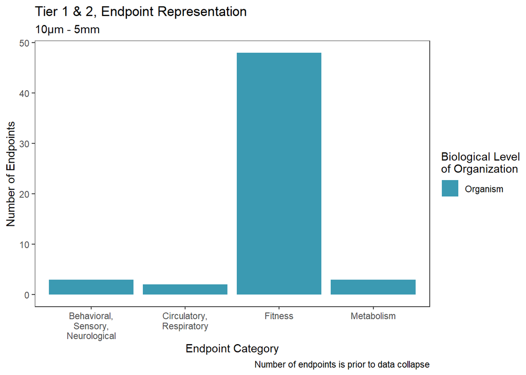

```r
#large
endpoints_tier3_4_large <- tier3_4_large %>%
  group_by(lvl1_f, bio_f) %>%
  mutate(lvl1_count = n()) %>%
  group_by(lvl1_f, lvl1_count, bio_f) %>%
  summarise() %>%
  ggplot(aes(x = lvl1_f, y=lvl1_count, fill = bio_f))+
  geom_bar(stat = "identity") +
  scale_fill_manual(values = wes_palette("Zissou1", 5, type = "continuous")) +
  labs(title = "Tier 1 & 2, Endpoint Representation", subtitle = "10µm - 5mm", x = "Endpoint Category", y = "Number of Endpoints", fill = "Biological Level\nof Organization", caption = "Number of endpoints is prior to data collapse") +
  theme_test() +
  scale_x_discrete(labels = wrap_format(10))


plot(endpoints_tier3_4_large)
```

```r
#medium
# endpoints_tier3_4_medium <- tier3_4_medium %>%
#   group_by(lvl1_f, bio_f) %>%
#   mutate(lvl1_count = n()) %>%
#   group_by(lvl1_f, lvl1_count, bio_f) %>%
#   summarise() %>%
#   ggplot(aes(x = lvl1_f, y=lvl1_count, fill = bio_f))+
#   geom_bar(stat = "identity") +
#   scale_fill_manual(values = wes_palette("Zissou1", 5, type = "continuous")) +
#   labs(title = "Tier 1 & 2, Endpoint Representation", subtitle = "10µm < 100µm", x = "Endpoint Category", y = "Number of Endpoints", fill = "Biological Level\nof Organization", caption = "Number of endpoints is prior to data collapse") +
#   theme_test() +
#   scale_x_discrete(labels = wrap_format(10))
#
#
# plot(endpoints_tier3_4_medium)

#small
endpoints_tier3_4_small <- tier3_4_small %>%
  group_by(lvl1_f, bio_f) %>%
  mutate(lvl1_count = n()) %>%
  group_by(lvl1_f, lvl1_count, bio_f) %>%
  summarise() %>%
  ggplot(aes(x = lvl1_f, y=lvl1_count, fill = bio_f))+
  geom_bar(stat = "identity") +
  scale_fill_manual(values = wes_palette("Zissou1", 5, type = "continuous")) +
  labs(title = "Tier 1 & 2, Endpoint Representation", subtitle = "1µm < 100µm", x = "Endpoint Category", y = "Number of Endpoints", fill = "Biological Level\nof Organization", caption = "Number of endpoints is prior to data collapse") +
  theme_test() +
  scale_x_discrete(labels = wrap_format(10))


plot(endpoints_tier3_4_small)
```

#### 2.4.2.3 Data Collapse

```r
#First quartile large particles
tier3_4_large_median <- tier3_4_large %>%
  group_by(Species, Group) %>%
  summarize(Conc = median(dose_new))
#First quartile medium particles
# tier3_4_medium_median <- tier3_4_medium %>%
#   group_by(Species, Group) %>%
#   summarize(Conc = median(dose_new))

#First quartile small particles
tier3_4_small_median <- tier3_4_small %>%
  group_by(Species, Group) %>%
  summarize(Conc = median(dose_new))
```

#### 2.4.2.4 SSD Build

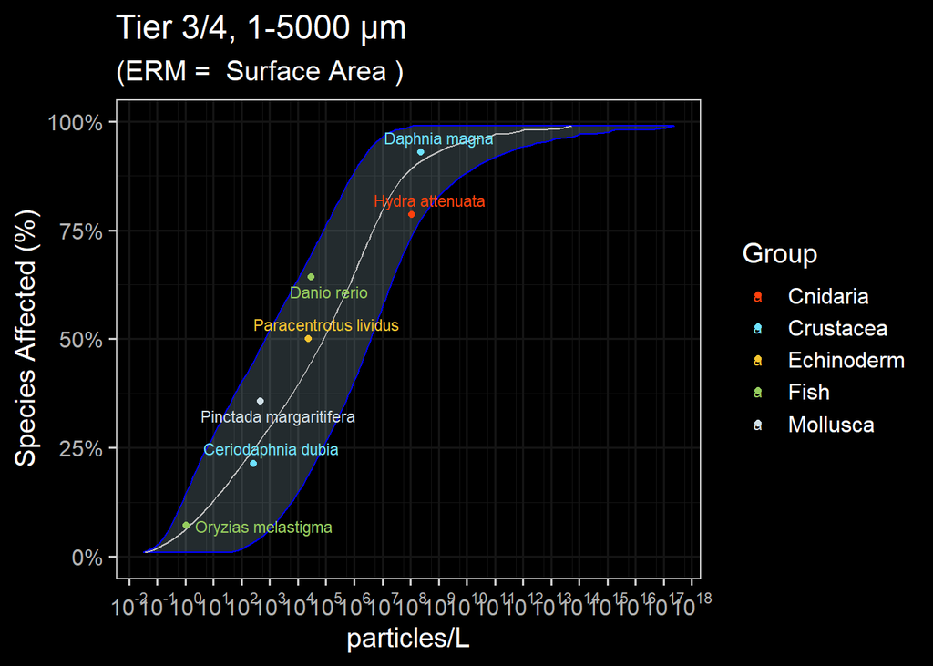

```r
###### --modelling ####
dists_tier3_4_large_median <- ssd_fit_dists(tier3_4_large_median, left = "Conc", dists = c("weibull", "llogis", "lnorm", "gamma", "lgumbel"), computable = FALSE, silent = FALSE)

#autoplot(dists_tier3_4_large_median) #plots the distribution in ggplotier2
#### Goodness of fit ####
gof_tier3_4_large_median <- as.data.frame(ssd_gof(dists_tier3_4_large_median)) %>% mutate_if(is.numeric, ~ signif(., 3))

#### Prediction ####
set.seed(99)
pred_tier3_4_large_median <- predict(dists_tier3_4_large_median, average = TRUE, ic = "aicc", nboot = 10, ci= TRUE)

#order data
SSD_tier3_4_large_median <- tier3_4_large_median[order(tier3_4_large_median$Conc), ]
SSD_tier3_4_large_median$frac <- ppoints(tier3_4_large_median$Conc, 0.5)

tier3_4_large_median_hc5 <- c(pred_tier3_4_large_median$est[5]) #HC5
tier3_4_large_median_hc10 <- c(pred_tier3_4_large_median$est[10]) #HC10
pred_tier3_4_large_median$est_format <-format(pred_tier3_4_large_median$est, digits = 3, scientific = TRUE)

#ggplot
tier3_4_large_median_ggplot <- ggplot(pred_tier3_4_large_median,aes_string(x = "est")) +
      geom_xribbon(aes_string(xmin = "lcl", xmax = "ucl", y = "percent/100"), alpha = 0.2, color = "blue", fill = "lightblue") +
      geom_line(aes_string(y = "percent/100"), color = "gray") +
      geom_point(data = SSD_tier3_4_large_median,aes(x = Conc, y =frac, color = Group)) +
      geom_text_repel(data = SSD_tier3_4_large_median, aes(x = Conc, y = frac, label = Species, color = Group), nudge_x = 0.2, size = 3, segment.alpha = 0.5) +
      scale_y_continuous("Species Affected (%)", labels = scales::percent, limits = c(0,1)) +
  labs(title = "Microplastics Species Sensitivity Distribution",
             subtitle = paste("(ERM = ",ERM,")")) +
      coord_trans(x = "log10") +
      scale_x_continuous(breaks = scales::trans_breaks("log10", function(x) 10^x, n = 15),
                         labels = trans_format("log10", scales::math_format(10^.x))) +
  labs(title = "Tier 3/4, 1-5000 µm", x = "particles/L") +
      fill.type + #user-selected
      color.type + #user-selected
      theme.type #user theme

plot(tier3_4_large_median_ggplot)
```

```r
###### --modelling ####
# dists_tier3_4_medium_median <- ssd_fit_dists(tier3_4_medium_median, left = "Conc", dists = c("weibull", "llogis", "lnorm", "gamma", "lgumbel"), computable = FALSE, silent = FALSE)
#
# #autoplot(dists_tier3_4_medium_median) #plots the distribution in ggplotier2
# #### Goodness of fit ####
# gof_tier3_4_medium_median <- as.data.frame(ssd_gof(dists_tier3_4_medium_median)) %>% mutate_if(is.numeric, ~ signif(., 3))
#
# #### Prediction ####
# set.seed(99)
# pred_tier3_4_medium_median <- predict(dists_tier3_4_medium_median, average = TRUE, ic = "aicc", nboot = 10, ci= TRUE)
#
# #order data
# SSD_tier3_4_medium_median <- tier3_4_medium_median[order(tier3_4_medium_median$Conc), ]
# SSD_tier3_4_medium_median$frac <- ppoints(tier3_4_medium_median$Conc, 0.5)
#
# tier3_4_medium_median_hc5 <- c(pred_tier3_4_medium_median$est[5]) #HC5
# tier3_4_medium_median_hc10 <- c(pred_tier3_4_medium_median$est[10]) #HC10
# pred_tier3_4_medium_median$est_format <-format(pred_tier3_4_medium_median$est, digits = 3, scientific = TRUE)
#
# #ggplot
# tier3_4_medium_median_ggplot <- ggplot(pred_tier3_4_medium_median,aes_string(x = "est")) +
#       geom_xribbon(aes_string(xmin = "lcl", xmax = "ucl", y = "percent/100"), alpha = 0.2, color = "blue", fill = "lightblue") +
#       geom_line(aes_string(y = "percent/100"), color = "gray") +
#       geom_point(data = SSD_tier3_4_medium_median,aes(x = Conc, y =frac, color = Group)) +
#       geom_text_repel(data = SSD_tier3_4_medium_median, aes(x = Conc, y = frac, label = Species, color = Group), nudge_x = 0.2, size = 3, segment.alpha = 0.5) +
#       scale_y_continuous("Species Affected (%)", labels = scales::percent, limits = c(0,1)) +
#       coord_trans(x = "log10") +
#       scale_x_continuous(breaks = scales::trans_breaks("log10", function(x) 10^x, n = 15),
#                          labels = trans_format("log10", scales::math_format(10^.x))) +
#   labs(title = "Tier 3/4, 10-100 µm", x = "particles/L") +
#       fill.type + #user-selected
#       color.type + #user-selected
#       theme.type #user theme
#
# tier3_4_medium_median_ggplot
```

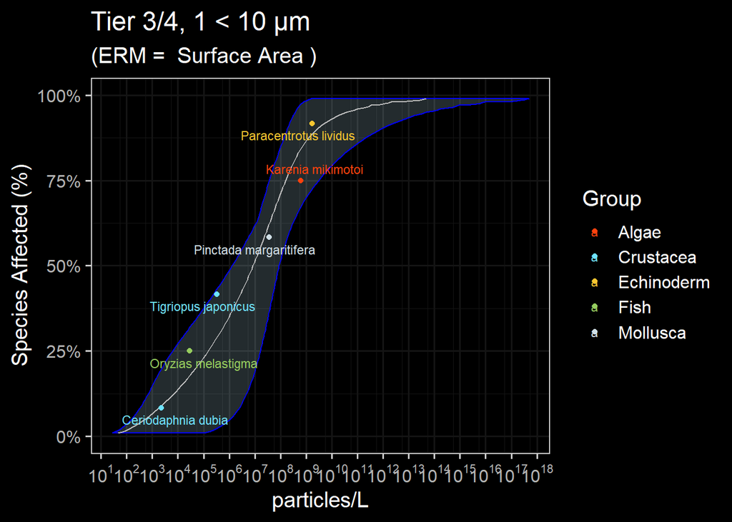

```r
###### --modelling ####
dists_tier3_4_small_median <- ssd_fit_dists(tier3_4_small_median, left = "Conc", dists = c("weibull", "llogis", "lnorm", "gamma", "lgumbel"), computable = FALSE, silent = FALSE)

#autoplot(dists_tier3_4_small_median) #plots the distribution in ggplotier2
#### Goodness of fit ####
gof_tier3_4_small_median <- as.data.frame(ssd_gof(dists_tier3_4_small_median)) %>% mutate_if(is.numeric, ~ signif(., 3))

#### Prediction ####
set.seed(99)
pred_tier3_4_small_median <- predict(dists_tier3_4_small_median, average = TRUE, ic = "aicc", nboot = 10, ci= TRUE)

#order data
SSD_tier3_4_small_median <- tier3_4_small_median[order(tier3_4_small_median$Conc), ]
SSD_tier3_4_small_median$frac <- ppoints(tier3_4_small_median$Conc, 0.5)

tier3_4_small_median_hc5 <- c(pred_tier3_4_small_median$est[5]) #HC5
tier3_4_small_median_hc10 <- c(pred_tier3_4_small_median$est[10]) #HC10
pred_tier3_4_small_median$est_format <-format(pred_tier3_4_small_median$est, digits = 3, scientific = TRUE)

#ggplot
tier3_4_small_median_ggplot <- ggplot(pred_tier3_4_small_median,aes_string(x = "est")) +
      geom_xribbon(aes_string(xmin = "lcl", xmax = "ucl", y = "percent/100"), alpha = 0.2, color = "blue", fill = "lightblue") +
      geom_line(aes_string(y = "percent/100"), color = "gray") +
      geom_point(data = SSD_tier3_4_small_median,aes(x = Conc, y =frac, color = Group)) +
      geom_text_repel(data = SSD_tier3_4_small_median, aes(x = Conc, y = frac, label = Species, color = Group), nudge_x = 0.2, size = 3, segment.alpha = 0.5) +
      scale_y_continuous("Species Affected (%)", labels = scales::percent, limits = c(0,1)) +
  labs(title = "Microplastics Species Sensitivity Distribution",
             subtitle = paste("(ERM = ",ERM,")")) +
      coord_trans(x = "log10") +
      scale_x_continuous(breaks = scales::trans_breaks("log10", function(x) 10^x, n = 15),
                         labels = trans_format("log10", scales::math_format(10^.x))) +
  labs(title = "Tier 3/4, 1 < 10 µm", x = "particles/L") +
      fill.type + #user-selected
      color.type + #user-selected
      theme.type #user theme

plot(tier3_4_small_median_ggplot)
```

##### 2.4.2.4.3 Tier 3 & 4 Summary Table

Hazard Confidence Level = HC5(Tier3)/HC10(Tier4)

Endpoints = All

Levels of Biological Organization = Organism and Population

HC Metric = Mean

Data Quality = Pass Technical & Risk Quality Red Criteria

```r
#save unique ID for ERM
tier3_large_sa <- tier3_4_large_median_hc5
tier4_large_sa <- tier3_4_large_median_hc10
tier3_small_sa <- tier3_4_small_median_hc5
tier4_small_sa <- tier3_4_small_median_hc10

larges <- list(tier3_4_large_median_hc5, tier3_4_large_median_hc10,
              tier3_4_large.obs[[1,1]], #n.obs
              tier3_4_large.obs[[1,2]], #n.studies
              tier3_4_large.obs[[1,3]], #n.taxa
              tier3_4_large.obs[[1,4]]) #n.species

# mediums <- list(tier3_4_medium_median_hc5, tier3_4_medium_median_hc10,
#               tier3_4_medium.obs[[1,1]], #n.obs
#               tier3_4_medium.obs[[1,2]], #n.studies
#               tier3_4_medium.obs[[1,3]], #n.taxa
#               tier3_4_medium.obs[[1,4]]) #n.species

smalls <- list(tier3_4_small_median_hc5, tier3_4_small_median_hc10,
              tier3_4_small.obs[[1,1]], #n.obs
              tier3_4_small.obs[[1,2]], #n.studies
              tier3_4_small.obs[[1,3]], #n.taxa
              tier3_4_small.obs[[1,4]]) #n.species

# Convert to data frames
largesdf <- data.frame(matrix(unlist(larges), ncol = 6))
# mediumsdf <- data.frame(matrix(unlist(mediums), ncol = 6))
smallsdf <- data.frame(matrix(unlist(smalls), ncol = 6))

# Rename columns
colnames(largesdf) <- c("Tier_3", "Tier_4", "N_Obs.", "N_Doi", "N_Taxa", "N_Species")
# colnames(mediumsdf) <- c("Tier_1", "Tier_2", "N_Obs.", "N_Doi", "N_Taxa", "N_Species")
colnames(smallsdf) <- c("Tier_3", "Tier_4", "N_Obs.", "N_Doi", "N_Taxa", "N_Species")

# Make tables

gt(largesdf) %>%
  tab_header(title = "Tier 3/4, 1-5000 µm", subtitle = "Thresholds presented in particles/L") %>%
  fmt_number(columns = vars(Tier_3, Tier_4),decimals = 2, use_seps = TRUE)
```

Tier 3/4, 1-5000 µm

Thresholds presented in particles/L

| Tier_3 | Tier_4 | N_Obs. | N_Doi | N_Taxa | N_Species |
| --- | --- | --- | --- | --- | --- |
| 0.59 | 4.08 | 56 | 8 | 5 | 7 |

```r
# gt(mediumsdf) %>%
#   tab_header(title = "Tier 3/4, 10-100 um", subtitle = "Thresholds presented in particles/L") %>%
#   fmt_number(columns = vars(Tier_3, Tier_4),decimals = 2, use_seps = TRUE)

gt(smallsdf) %>%
  tab_header(title = "Tier 3/4, 1-10µm ", subtitle = "Thresholds presented in particles/L") %>%
  fmt_number(columns = vars(Tier_3, Tier_4),decimals = 2, use_seps = TRUE)
```

Tier 3/4, 1-10µm

Thresholds presented in particles/L

| Tier_3 | Tier_4 | N_Obs. | N_Doi | N_Taxa | N_Species |
| --- | --- | --- | --- | --- | --- |
| 524.11 | 3,186.72 | 23 | 6 | 5 | 6 |

## 2.5 ERM = Mass

```r
ERM <- "Mass"
```

### 2.5.1 Tiers 1 & 2

Tier 1 and 2 are the same SSD. A different HC metric is selected to differentiate between the tiers. Specifically, Tier 1 uses the 95% CI whereas Tier 2 uses the Mean. See below for more details of specific parameters.

Hazard Confidence Level = HC5

Endpoints = All

Levels of Biological Organization = All

HC Metric = 95% CI (Tier 1); Mean (Tier 2)

Data Quality = Pass Technical Quality Red Criteria

#### 2.5.1.1 Data Filtering

```r
tier1_2_large <- aoc_final_large %>%
         mutate(dose_new = EC_env_m.particles.mL / (af.time * af.noec)) %>%
         drop_na(dose_new) %>%
         mutate(dose_new = dose_new * 1000) %>%
  filter(size.length.um.used.for.conversions %in% (1:5000))

# Count observations and studies
tier1_2_large.obs <- tier1_2_large %>% summarize(n.obs = n(), n.studies = n_distinct(doi), n.taxa = n_distinct(org_f), n.species = n_distinct(species_f))

# ### 10 - 100 um
# tier1_2_medium <- tier1_2 %>%
#   filter(size_f %in% c("10µm < 100µm"))
#
# # Count observations and studies
# tier1_2_medium.obs <- tier1_2_medium %>% summarize(n.obs = n(), n.studies = n_distinct(doi), n.taxa = n_distinct(org_f), n.species = n_distinct(species_f))

### 1 - 100 um
tier1_2_small <- aoc_final_small %>%
         mutate(dose_new = EC_env_m.particles.mL / (af.time * af.noec)) %>%
         drop_na(dose_new) %>%
         mutate(dose_new = dose_new * 1000) %>%
  filter(size.length.um.used.for.conversions %in% (1:10))

# Count observations and studies
tier1_2_small.obs <- tier1_2_small %>% summarize(n.obs = n(), n.studies = n_distinct(doi), n.taxa = n_distinct(org_f), n.species = n_distinct(species_f))
```

#### 2.5.1.2 Endpoint Representation

```r
#large
endpoints_tier1_2_large <- tier1_2_large %>%
  group_by(lvl1_f, bio_f) %>%
  mutate(lvl1_count = n()) %>%
  group_by(lvl1_f, lvl1_count, bio_f) %>%
  summarise() %>%
  ggplot(aes(x = lvl1_f, y=lvl1_count, fill = bio_f))+
  geom_bar(stat = "identity") +
  scale_fill_manual(values = wes_palette("Zissou1", 5, type = "continuous")) +
  labs(title = "Tier 1 & 2, Endpoint Representation", subtitle = "1µm - 5mm", x = "Endpoint Category", y = "Number of Endpoints", fill = "Biological Level\nof Organization", caption = "Number of endpoints is prior to data collapse") +
  theme_test() +
  scale_x_discrete(labels = wrap_format(10))


# plot(endpoints_tier1_2_large)

#medium
# endpoints_tier1_2_medium <- tier1_2_medium %>%
#   group_by(lvl1_f, bio_f) %>%
#   mutate(lvl1_count = n()) %>%
#   group_by(lvl1_f, lvl1_count, bio_f) %>%
#   summarise() %>%
#   ggplot(aes(x = lvl1_f, y=lvl1_count, fill = bio_f))+
#   geom_bar(stat = "identity") +
#   scale_fill_manual(values = wes_palette("Zissou1", 5, type = "continuous")) +
#   labs(title = "Tier 1 & 2, Endpoint Representation", subtitle = "10µm < 100µm", x = "Endpoint Category", y = "Number of Endpoints", fill = "Biological Level\nof Organization", caption = "Number of endpoints is prior to data collapse") +
#   theme_test() +
#   scale_x_discrete(labels = wrap_format(10))
#
#
# plot(endpoints_tier1_2_medium)

#small
endpoints_tier1_2_small <- tier1_2_small %>%
  group_by(lvl1_f, bio_f) %>%
  mutate(lvl1_count = n()) %>%
  group_by(lvl1_f, lvl1_count, bio_f) %>%
  summarise() %>%
  ggplot(aes(x = lvl1_f, y=lvl1_count, fill = bio_f))+
  geom_bar(stat = "identity") +
  scale_fill_manual(values = wes_palette("Zissou1", 5, type = "continuous")) +
  labs(title = "Tier 1 & 2, Endpoint Representation", subtitle = "1µm < 100µm", x = "Endpoint Category", y = "Number of Endpoints", fill = "Biological Level\nof Organization", caption = "Number of endpoints is prior to data collapse") +
  theme_test() +
  scale_x_discrete(labels = wrap_format(10))


# plot(endpoints_tier1_2_small)
```

#### 2.5.1.3 SSD Build

##### 2.5.1.3.1 Data Collapse

```r
#First quartile large particles
tier1_2_large_1q <- tier1_2_large %>%
  group_by(Species, Group) %>%
  summarize(Conc = quantile(dose_new, 0.25))
#First quartile medium particles
# tier1_2_medium_1q <- tier1_2_medium %>%
#   group_by(Species, Group) %>%
#   summarize(Conc = quantile(dose_new, 0.25))

#First quartile small particles
tier1_2_small_1q <- tier1_2_small %>%
  group_by(Species, Group) %>%
  summarize(Conc = quantile(dose_new, 0.25))
```

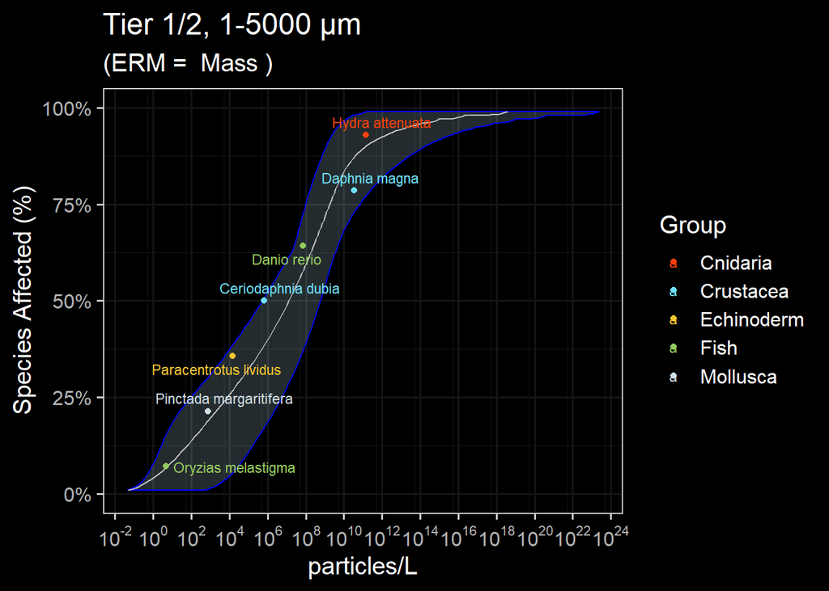

```r
###### --modelling ####
dists_tier1_2_large_1q <- ssd_fit_dists(tier1_2_large_1q, left = "Conc", dists = c("weibull", "llogis", "lnorm", "gamma", "lgumbel"), computable = FALSE, silent = FALSE)

#autoplot(dists_tier1_2_large_1q) #plots the distribution in ggplotier2
#### Goodness of fit ####
gof_tier1_2_large_1q <- as.data.frame(ssd_gof(dists_tier1_2_large_1q)) %>% mutate_if(is.numeric, ~ signif(., 3))

#### Prediction ####
set.seed(99)
pred_tier1_2_large_1q <- predict(dists_tier1_2_large_1q, average = TRUE, ic = "aicc", nboot = 10, ci= TRUE)

#order data
SSD_tier1_2_large_1q <- tier1_2_large_1q[order(tier1_2_large_1q$Conc), ]
SSD_tier1_2_large_1q$frac <- ppoints(tier1_2_large_1q$Conc, 0.5)

tier1_2_large_1q_lcl <- c(pred_tier1_2_large_1q$lcl[5]) #CI95
tier1_2_large_1q_hc5 <- c(pred_tier1_2_large_1q$est[5]) #HC5
pred_tier1_2_large_1q$est_format <-format(pred_tier1_2_large_1q$est, digits = 3, scientific = TRUE)

#add unique ID for multiplot
pred_tier1_2_large_1q_mass <- pred_tier1_2_large_1q
SSD_tier1_2_large_1q_mass <- SSD_tier1_2_large_1q

#ggplot
tier1_2_large_1q_ggplot <- ggplot(pred_tier1_2_large_1q,aes_string(x = "est")) +
      geom_xribbon(aes_string(xmin = "lcl", xmax = "ucl", y = "percent/100"), alpha = 0.2, color = "blue", fill = "lightblue") +
      geom_line(aes_string(y = "percent/100"), color = "gray") +
      geom_point(data = SSD_tier1_2_large_1q,aes(x = Conc, y =frac, color = Group)) +
      geom_text_repel(data = SSD_tier1_2_large_1q, aes(x = Conc, y = frac, label = Species, color = Group), nudge_x = 0.2, size = 3, segment.alpha = 0.5) +
      scale_y_continuous("Species Affected (%)", labels = scales::percent, limits = c(0,1)) +
  labs(title = "Microplastics Species Sensitivity Distribution",
             subtitle = paste("(ERM = ",ERM,")")) +
      coord_trans(x = "log10") +
      scale_x_continuous(breaks = scales::trans_breaks("log10", function(x) 10^x, n = 15),
                         labels = trans_format("log10", scales::math_format(10^.x))) +
  labs(title = "Tier 1/2, 1-5000 µm", x = "particles/L") +
      fill.type + #user-selected
      color.type + #user-selected
      theme.type #user theme

plot(tier1_2_large_1q_ggplot)
```

```r
# ###### --modelling ####
# dists_tier1_2_medium_1q <- ssd_fit_dists(tier1_2_medium_1q, left = "Conc", dists = c("weibull", "llogis", "lnorm", "gamma", "lgumbel"), computable = FALSE, silent = FALSE)
#
# #autoplot(dists_tier1_2_medium_1q) #plots the distribution in ggplotier2
# #### Goodness of fit ####
# gof_tier1_2_medium_1q <- as.data.frame(ssd_gof(dists_tier1_2_medium_1q)) %>% mutate_if(is.numeric, ~ signif(., 3))
#
# #### Prediction ####
# set.seed(99)
# pred_tier1_2_medium_1q <- predict(dists_tier1_2_medium_1q, average = TRUE, ic = "aicc", nboot = 10, ci= TRUE)
#
# #order data
# SSD_tier1_2_medium_1q <- tier1_2_medium_1q[order(tier1_2_medium_1q$Conc), ]
# SSD_tier1_2_medium_1q$frac <- ppoints(tier1_2_medium_1q$Conc, 0.5)
#
# tier1_2_medium_1q_lcl <- c(pred_tier1_2_medium_1q$lcl[5]) #CI95
# tier1_2_medium_1q_hc5 <- c(pred_tier1_2_medium_1q$est[5]) #HC5
# pred_tier1_2_medium_1q$est_format <-format(pred_tier1_2_medium_1q$est, digits = 3, scientific = TRUE)
#
# #ggplot
# tier1_2_medium_1q_ggplot <- ggplot(pred_tier1_2_medium_1q,aes_string(x = "est")) +
#       geom_xribbon(aes_string(xmin = "lcl", xmax = "ucl", y = "percent/100"), alpha = 0.2, color = "blue", fill = "lightblue") +
#       geom_line(aes_string(y = "percent/100"), color = "gray") +
#       geom_point(data = SSD_tier1_2_medium_1q,aes(x = Conc, y =frac, color = Group)) +
#       geom_text_repel(data = SSD_tier1_2_medium_1q, aes(x = Conc, y = frac, label = Species, color = Group), nudge_x = 0.2, size = 3, segment.alpha = 0.5) +
#       scale_y_continuous("Species Affected (%)", labels = scales::percent, limits = c(0,1)) +
#       coord_trans(x = "log10") +
#       scale_x_continuous(breaks = scales::trans_breaks("log10", function(x) 10^x, n = 15),
#                          labels = trans_format("log10", scales::math_format(10^.x))) +
#   labs(title = "Tier 1/2, 10-100 µm", x = "particles/L") +
#       fill.type + #user-selected
#       color.type + #user-selected
#       theme.type #user theme
#
# plot(tier1_2_medium_1q_ggplot)
```

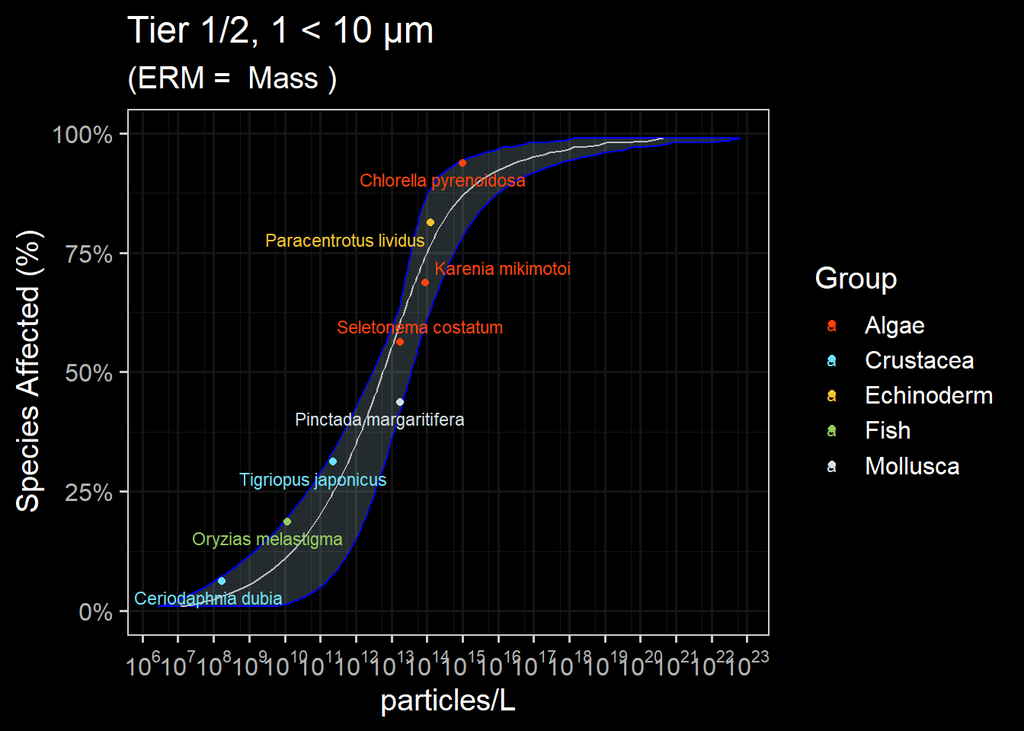

```r
###### --modelling ####
dists_tier1_2_small_1q <- ssd_fit_dists(tier1_2_small_1q, left = "Conc", dists = c("weibull", "llogis", "lnorm", "lgumbel"), computable = FALSE, silent = FALSE)

#autoplot(dists_tier1_2_small_1q) #plots the distribution in ggplotier2
#### Goodness of fit ####
gof_tier1_2_small_1q <- as.data.frame(ssd_gof(dists_tier1_2_small_1q)) %>% mutate_if(is.numeric, ~ signif(., 3))

#### Prediction ####
set.seed(99)
pred_tier1_2_small_1q <- predict(dists_tier1_2_small_1q, average = TRUE, ic = "aicc", nboot = 10, ci= TRUE)

#order data
SSD_tier1_2_small_1q <- tier1_2_small_1q[order(tier1_2_small_1q$Conc), ]
SSD_tier1_2_small_1q$frac <- ppoints(tier1_2_small_1q$Conc, 0.5)

tier1_2_small_1q_lcl <- c(pred_tier1_2_small_1q$lcl[5]) #CI95
tier1_2_small_1q_hc5 <- c(pred_tier1_2_small_1q$est[5]) #HC5
pred_tier1_2_small_1q$est_format <-format(pred_tier1_2_small_1q$est, digits = 3, scientific = TRUE)

#ggplot
tier1_2_small_1q_ggplot <- ggplot(pred_tier1_2_small_1q,aes_string(x = "est")) +
      geom_xribbon(aes_string(xmin = "lcl", xmax = "ucl", y = "percent/100"), alpha = 0.2, color = "blue", fill = "lightblue") +
      geom_line(aes_string(y = "percent/100"), color = "gray") +
      geom_point(data = SSD_tier1_2_small_1q,aes(x = Conc, y =frac, color = Group)) +
      geom_text_repel(data = SSD_tier1_2_small_1q, aes(x = Conc, y = frac, label = Species, color = Group), nudge_x = 0.2, size = 3, segment.alpha = 0.5) +
      scale_y_continuous("Species Affected (%)", labels = scales::percent, limits = c(0,1)) +
  labs(title = "Microplastics Species Sensitivity Distribution",
             subtitle = paste("(ERM = ",ERM,")")) +
      coord_trans(x = "log10") +
      scale_x_continuous(breaks = scales::trans_breaks("log10", function(x) 10^x, n = 15),
                         labels = trans_format("log10", scales::math_format(10^.x))) +
  labs(title = "Tier 1/2, 1 < 10 µm", x = "particles/L") +
      fill.type + #user-selected
      color.type + #user-selected
      theme.type #user theme

plot(tier1_2_small_1q_ggplot)
```

#### 2.5.1.4 Tier 1 & 2 Summary Table

Hazard Confidence Level = HC5

Endpoints = All

Levels of Biological Organization = All

HC Metric = 95% CI (Tier 1); Mean (Tier 2)

Data Quality = Pass Technical Quality Red Criteria

```r
#save unique ID for ERM
tier1_large_m <- tier1_2_large_1q_lcl
tier2_large_m <- tier1_2_large_1q_hc5
tier1_small_m <- tier1_2_small_1q_lcl
tier2_small_m <- tier1_2_small_1q_hc5

larges <- list(tier1_2_large_1q_lcl, tier1_2_large_1q_hc5,
              tier1_2_large.obs[[1,1]], #n.obs
              tier1_2_large.obs[[1,2]], #n.studies
              tier1_2_large.obs[[1,3]], #n.taxa
              tier1_2_large.obs[[1,4]]) #n.species

# mediums <- list(tier1_2_medium_1q_lcl, tier1_2_medium_1q_hc5,
#               tier1_2_medium.obs[[1,1]], #n.obs
#               tier1_2_medium.obs[[1,2]], #n.studies
#               tier1_2_medium.obs[[1,3]], #n.taxa
#               tier1_2_medium.obs[[1,4]]) #n.species

smalls <- list(tier1_2_small_1q_lcl, tier1_2_small_1q_hc5,
              tier1_2_small.obs[[1,1]], #n.obs
              tier1_2_small.obs[[1,2]], #n.studies
              tier1_2_small.obs[[1,3]], #n.taxa
              tier1_2_small.obs[[1,4]]) #n.species

# Convert to data frames
largesdf <- data.frame(matrix(unlist(larges), ncol = 6))
# mediumsdf <- data.frame(matrix(unlist(mediums), ncol = 6))
smallsdf <- data.frame(matrix(unlist(smalls), ncol = 6))

# Rename columns
colnames(largesdf) <- c("Tier_1", "Tier_2", "N_Obs.", "N_Doi", "N_Taxa", "N_Species")
# colnames(mediumsdf) <- c("Tier_1", "Tier_2", "N_Obs.", "N_Doi", "N_Taxa", "N_Species")
colnames(smallsdf) <- c("Tier_1", "Tier_2", "N_Obs.", "N_Doi", "N_Taxa", "N_Species")

# Make tables

gt(largesdf) %>%
  tab_header(title = "Tier 1/2, 1µm - 5mm", subtitle = "Thresholds presented in particles/L") %>%
  fmt_number(columns = vars(Tier_1, Tier_2),decimals = 2, use_seps = TRUE)
```

Tier 1/2, 1µm - 5mm

Thresholds presented in particles/L

| Tier_1 | Tier_2 | N_Obs. | N_Doi | N_Taxa | N_Species |
| --- | --- | --- | --- | --- | --- |
| 0.48 | 1.66 | 210 | 8 | 5 | 7 |

```r
# gt(mediumsdf) %>%
#   tab_header(title = "Tier 1/2, 10-100 um", subtitle = "Thresholds presented in particles/L") %>%
#   fmt_number(columns = vars(Tier_1, Tier_2),decimals = 2, use_seps = TRUE)

gt(smallsdf) %>%
  tab_header(title = "Tier 1/2, 1-10µm ", subtitle = paste("Thresholds presented in particles/L; ERM = ",ERM)
             ) %>%
  fmt_number(columns = vars(Tier_1, Tier_2),decimals = 2, use_seps = TRUE)
```

Tier 1/2, 1-10µm

Thresholds presented in particles/L; ERM = Mass

| Tier_1 | Tier_2 | N_Obs. | N_Doi | N_Taxa | N_Species |
| --- | --- | --- | --- | --- | --- |
| 54,056,817.40 | 703,519,385.45 | 194 | 8 | 5 | 8 |

### 2.5.2 Tiers 3 & 4

Hazard Confidence Level = HC5(Tier3)/HC10(Tier4)

Endpoints = All

Levels of Biological Organization = Organism and Population

HC Metric = Mean

Data Quality = Pass Technical & Risk Quality Red Criteria

#### 2.5.2.1 Data Filtering

```r
#### Size filters ####

### 100 - 5000 um
tier3_4_large <-  aoc_final_large %>%
  filter(risk.13 != 1,
         bio_f %in% c("Organism", "Population")) %>%
         mutate(dose_new = EC_poly_m.particles.mL / (af.time * af.noec)) %>%
         drop_na(dose_new) %>%
         mutate(dose_new = dose_new*1000) %>%
  filter(size.length.um.used.for.conversions %in% (1:5000))

# Count observations and studies
tier3_4_large.obs <- tier3_4_large %>% summarize(n.obs = n(), n.studies = n_distinct(doi), n.taxa = n_distinct(org_f), n.species = n_distinct(species_f))

# ### 10 - 100 um
# tier3_4_medium <- tier3_4 %>%
#   filter(size_f %in% c("10µm < 100µm"))
#
# # Count observations and studies
# tier3_4_medium.obs <- tier3_4_medium %>% summarize(n.obs = n(), n.studies = n_distinct(doi), n.taxa = n_distinct(org_f), n.species = n_distinct(species_f))

### 1 - 100 um
tier3_4_small <- aoc_final_small %>%
  filter(risk.13 != 1,
         bio_f %in% c("Organism", "Population")) %>%
         mutate(dose_new = EC_poly_m.particles.mL / (af.time * af.noec)) %>%
         drop_na(dose_new) %>%
         mutate(dose_new = dose_new*1000) %>%
  filter(size.length.um.used.for.conversions %in% (1:10))

# Count observations and studies
tier3_4_small.obs <- tier3_4_small %>% summarize(n.obs = n(), n.studies = n_distinct(doi), n.taxa = n_distinct(org_f), n.species = n_distinct(species_f))
```

#### 2.5.2.2 Endpoint Representation

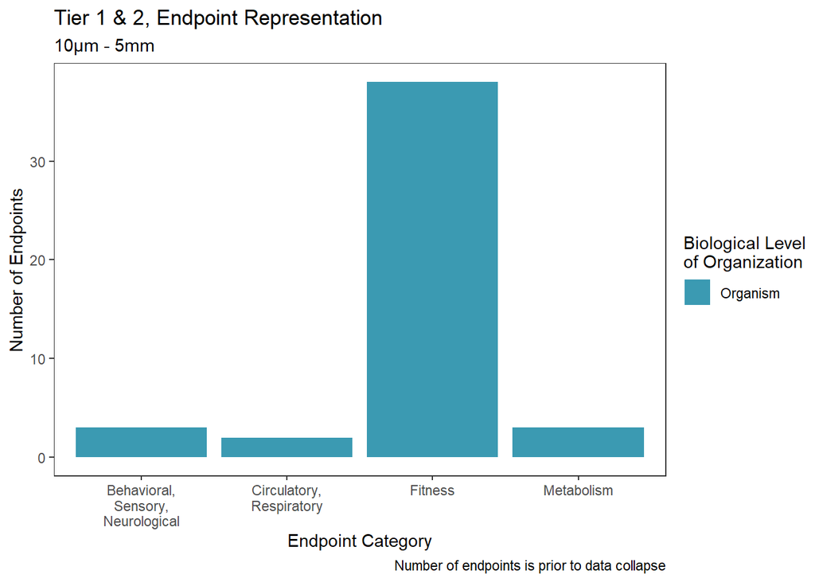

```r
#large
endpoints_tier3_4_large <- tier3_4_large %>%
  group_by(lvl1_f, bio_f) %>%
  mutate(lvl1_count = n()) %>%
  group_by(lvl1_f, lvl1_count, bio_f) %>%
  summarise() %>%
  ggplot(aes(x = lvl1_f, y=lvl1_count, fill = bio_f))+
  geom_bar(stat = "identity") +
  scale_fill_manual(values = wes_palette("Zissou1", 5, type = "continuous")) +
  labs(title = "Tier 1 & 2, Endpoint Representation", subtitle = "10µm - 5mm", x = "Endpoint Category", y = "Number of Endpoints", fill = "Biological Level\nof Organization", caption = "Number of endpoints is prior to data collapse") +
  theme_test() +
  scale_x_discrete(labels = wrap_format(10))


plot(endpoints_tier3_4_large)
```

```r
#medium
# endpoints_tier3_4_medium <- tier3_4_medium %>%
#   group_by(lvl1_f, bio_f) %>%
#   mutate(lvl1_count = n()) %>%
#   group_by(lvl1_f, lvl1_count, bio_f) %>%
#   summarise() %>%
#   ggplot(aes(x = lvl1_f, y=lvl1_count, fill = bio_f))+
#   geom_bar(stat = "identity") +
#   scale_fill_manual(values = wes_palette("Zissou1", 5, type = "continuous")) +
#   labs(title = "Tier 1 & 2, Endpoint Representation", subtitle = "10µm < 100µm", x = "Endpoint Category", y = "Number of Endpoints", fill = "Biological Level\nof Organization", caption = "Number of endpoints is prior to data collapse") +
#   theme_test() +
#   scale_x_discrete(labels = wrap_format(10))
#
#
# plot(endpoints_tier3_4_medium)

#small
endpoints_tier3_4_small <- tier3_4_small %>%
  group_by(lvl1_f, bio_f) %>%
  mutate(lvl1_count = n()) %>%
  group_by(lvl1_f, lvl1_count, bio_f) %>%
  summarise() %>%
  ggplot(aes(x = lvl1_f, y=lvl1_count, fill = bio_f))+
  geom_bar(stat = "identity") +
  scale_fill_manual(values = wes_palette("Zissou1", 5, type = "continuous")) +
  labs(title = "Tier 1 & 2, Endpoint Representation", subtitle = "1µm < 100µm", x = "Endpoint Category", y = "Number of Endpoints", fill = "Biological Level\nof Organization", caption = "Number of endpoints is prior to data collapse") +
  theme_test() +
  scale_x_discrete(labels = wrap_format(10))


plot(endpoints_tier3_4_small)
```

[output not shown]

#### 2.5.2.3 SSD Build

##### 2.5.2.3.1 Data Collapse

```r
#First quartile large particles
tier3_4_large_median <- tier3_4_large %>%
  group_by(Species, Group) %>%
  summarize(Conc = median(dose_new))
#First quartile medium particles
# tier3_4_medium_median <- tier3_4_medium %>%
#   group_by(Species, Group) %>%
#   summarize(Conc = median(dose_new))

#First quartile small particles
tier3_4_small_median <- tier3_4_small %>%
  group_by(Species, Group) %>%
  summarize(Conc = median(dose_new))
```

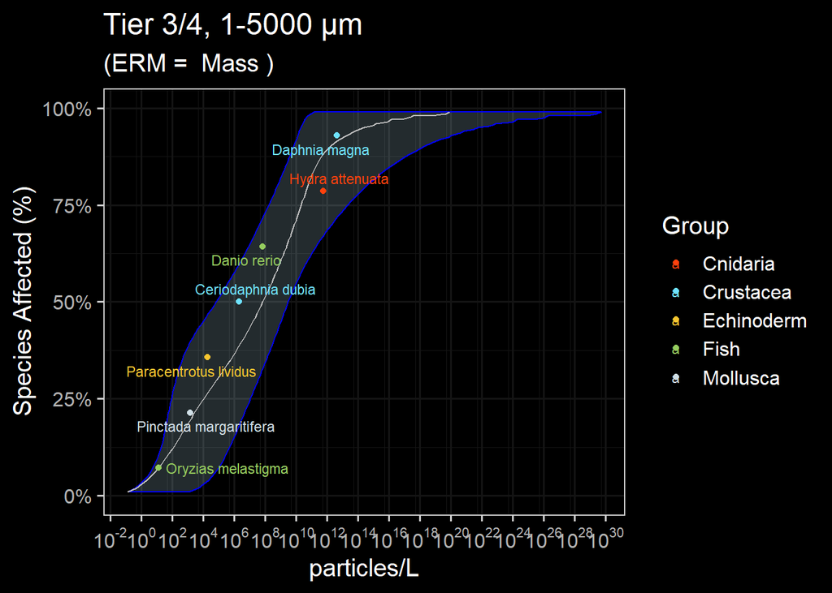

```r
###### --modelling ####
dists_tier3_4_large_median <- ssd_fit_dists(tier3_4_large_median, left = "Conc", dists = c("llogis", "lnorm", "gamma", "lgumbel"), computable = FALSE, silent = FALSE)

#autoplot(dists_tier3_4_large_median) #plots the distribution in ggplotier2
#### Goodness of fit ####
gof_tier3_4_large_median <- as.data.frame(ssd_gof(dists_tier3_4_large_median)) %>% mutate_if(is.numeric, ~ signif(., 3))

#### Prediction ####
set.seed(99)
pred_tier3_4_large_median <- predict(dists_tier3_4_large_median, average = TRUE, ic = "aicc", nboot = 10, ci= TRUE)

#order data
SSD_tier3_4_large_median <- tier3_4_large_median[order(tier3_4_large_median$Conc), ]
SSD_tier3_4_large_median$frac <- ppoints(tier3_4_large_median$Conc, 0.5)

tier3_4_large_median_hc5 <- c(pred_tier3_4_large_median$est[5]) #HC5
tier3_4_large_median_hc10 <- c(pred_tier3_4_large_median$est[10]) #HC10
pred_tier3_4_large_median$est_format <-format(pred_tier3_4_large_median$est, digits = 3, scientific = TRUE)

#ggplot
tier3_4_large_median_ggplot <- ggplot(pred_tier3_4_large_median,aes_string(x = "est")) +
      geom_xribbon(aes_string(xmin = "lcl", xmax = "ucl", y = "percent/100"), alpha = 0.2, color = "blue", fill = "lightblue") +
      geom_line(aes_string(y = "percent/100"), color = "gray") +
      geom_point(data = SSD_tier3_4_large_median,aes(x = Conc, y =frac, color = Group)) +
      geom_text_repel(data = SSD_tier3_4_large_median, aes(x = Conc, y = frac, label = Species, color = Group), nudge_x = 0.2, size = 3, segment.alpha = 0.5) +
      scale_y_continuous("Species Affected (%)", labels = scales::percent, limits = c(0,1)) +
  labs(title = "Microplastics Species Sensitivity Distribution",
             subtitle = paste("(ERM = ",ERM,")")) +
      coord_trans(x = "log10") +
      scale_x_continuous(breaks = scales::trans_breaks("log10", function(x) 10^x, n = 15),
                         labels = trans_format("log10", scales::math_format(10^.x))) +
  labs(title = "Tier 3/4, 1-5000 µm", x = "particles/L") +
      fill.type + #user-selected
      color.type + #user-selected
      theme.type #user theme

plot(tier3_4_large_median_ggplot)
```

```r
###### --modelling ####
# dists_tier3_4_medium_median <- ssd_fit_dists(tier3_4_medium_median, left = "Conc", dists = c("weibull", "llogis", "lnorm", "gamma", "lgumbel"), computable = FALSE, silent = FALSE)
#
# #autoplot(dists_tier3_4_medium_median) #plots the distribution in ggplotier2
# #### Goodness of fit ####
# gof_tier3_4_medium_median <- as.data.frame(ssd_gof(dists_tier3_4_medium_median)) %>% mutate_if(is.numeric, ~ signif(., 3))
#
# #### Prediction ####
# set.seed(99)
# pred_tier3_4_medium_median <- predict(dists_tier3_4_medium_median, average = TRUE, ic = "aicc", nboot = 10, ci= TRUE)
#
# #order data
# SSD_tier3_4_medium_median <- tier3_4_medium_median[order(tier3_4_medium_median$Conc), ]
# SSD_tier3_4_medium_median$frac <- ppoints(tier3_4_medium_median$Conc, 0.5)
#
# tier3_4_medium_median_hc5 <- c(pred_tier3_4_medium_median$est[5]) #HC5
# tier3_4_medium_median_hc10 <- c(pred_tier3_4_medium_median$est[10]) #HC10
# pred_tier3_4_medium_median$est_format <-format(pred_tier3_4_medium_median$est, digits = 3, scientific = TRUE)
#
# #ggplot
# tier3_4_medium_median_ggplot <- ggplot(pred_tier3_4_medium_median,aes_string(x = "est")) +
#       geom_xribbon(aes_string(xmin = "lcl", xmax = "ucl", y = "percent/100"), alpha = 0.2, color = "blue", fill = "lightblue") +
#       geom_line(aes_string(y = "percent/100"), color = "gray") +
#       geom_point(data = SSD_tier3_4_medium_median,aes(x = Conc, y =frac, color = Group)) +
#       geom_text_repel(data = SSD_tier3_4_medium_median, aes(x = Conc, y = frac, label = Species, color = Group), nudge_x = 0.2, size = 3, segment.alpha = 0.5) +
#       scale_y_continuous("Species Affected (%)", labels = scales::percent, limits = c(0,1)) +
#       coord_trans(x = "log10") +
#       scale_x_continuous(breaks = scales::trans_breaks("log10", function(x) 10^x, n = 15),
#                          labels = trans_format("log10", scales::math_format(10^.x))) +
#   labs(title = "Tier 3/4, 10-100 µm", x = "particles/L") +
#       fill.type + #user-selected
#       color.type + #user-selected
#       theme.type #user theme
#
# tier3_4_medium_median_ggplot
```

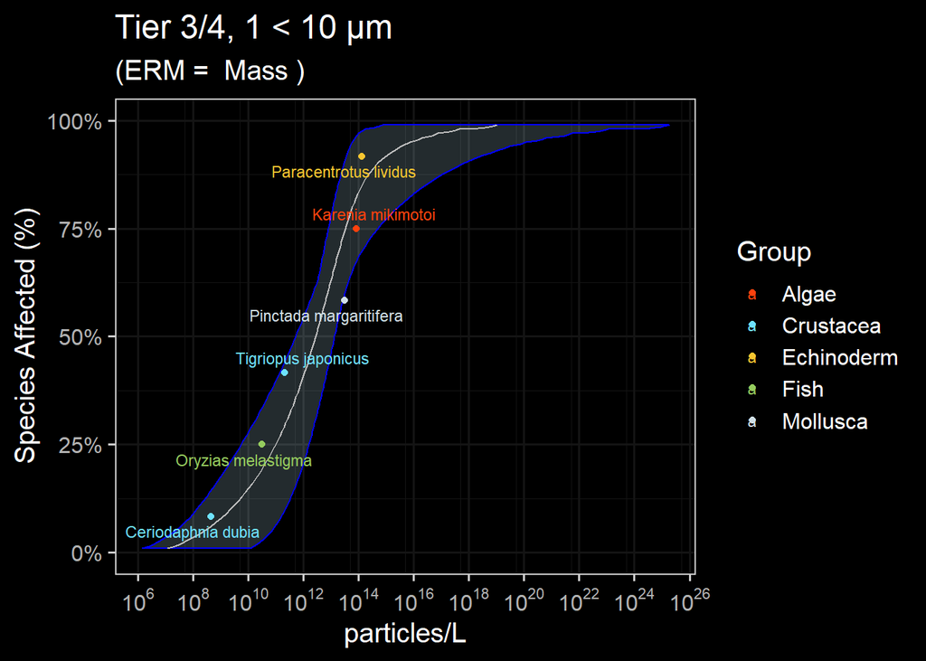

```r
###### --modelling ####
dists_tier3_4_small_median <- ssd_fit_dists(tier3_4_small_median, left = "Conc", dists = c("weibull", "llogis", "lnorm", "gamma", "lgumbel"), computable = FALSE, silent = FALSE)

#autoplot(dists_tier3_4_small_median) #plots the distribution in ggplotier2
#### Goodness of fit ####
gof_tier3_4_small_median <- as.data.frame(ssd_gof(dists_tier3_4_small_median)) %>% mutate_if(is.numeric, ~ signif(., 3))

#### Prediction ####
set.seed(99)
pred_tier3_4_small_median <- predict(dists_tier3_4_small_median, average = TRUE, ic = "aicc", nboot = 10, ci= TRUE)

#order data
SSD_tier3_4_small_median <- tier3_4_small_median[order(tier3_4_small_median$Conc), ]
SSD_tier3_4_small_median$frac <- ppoints(tier3_4_small_median$Conc, 0.5)

tier3_4_small_median_hc5 <- c(pred_tier3_4_small_median$est[5]) #HC5
tier3_4_small_median_hc10 <- c(pred_tier3_4_small_median$est[10]) #HC10
pred_tier3_4_small_median$est_format <-format(pred_tier3_4_small_median$est, digits = 3, scientific = TRUE)

#ggplot
tier3_4_small_median_ggplot <- ggplot(pred_tier3_4_small_median,aes_string(x = "est")) +
      geom_xribbon(aes_string(xmin = "lcl", xmax = "ucl", y = "percent/100"), alpha = 0.2, color = "blue", fill = "lightblue") +
      geom_line(aes_string(y = "percent/100"), color = "gray") +
      geom_point(data = SSD_tier3_4_small_median,aes(x = Conc, y =frac, color = Group)) +
      geom_text_repel(data = SSD_tier3_4_small_median, aes(x = Conc, y = frac, label = Species, color = Group), nudge_x = 0.2, size = 3, segment.alpha = 0.5) +
      scale_y_continuous("Species Affected (%)", labels = scales::percent, limits = c(0,1)) +
  labs(title = "Microplastics Species Sensitivity Distribution",
             subtitle = paste("(ERM = ",ERM,")")) +
      coord_trans(x = "log10") +
      scale_x_continuous(breaks = scales::trans_breaks("log10", function(x) 10^x, n = 15),
                         labels = trans_format("log10", scales::math_format(10^.x))) +
  labs(title = "Tier 3/4, 1 < 10 µm", x = "particles/L") +
      fill.type + #user-selected
      color.type + #user-selected
      theme.type #user theme

plot(tier3_4_small_median_ggplot)
```

##### 2.5.2.3.4 Tier 3 & 4 Summary Table

Hazard Confidence Level = HC5(Tier3)/HC10(Tier4)

Endpoints = All

Levels of Biological Organization = Organism and Population

HC Metric = Mean

Data Quality = Pass Technical & Risk Quality Red Criteria

```r
#save unique ID for ERM
tier3_large_m <- tier3_4_large_median_hc5
tier4_large_m <- tier3_4_large_median_hc10
tier3_small_m <- tier3_4_small_median_hc5
tier4_small_m <- tier3_4_small_median_hc10

larges <- list(tier3_4_large_median_hc5, tier3_4_large_median_hc10,
              tier3_4_large.obs[[1,1]], #n.obs
              tier3_4_large.obs[[1,2]], #n.studies
              tier3_4_large.obs[[1,3]], #n.taxa
              tier3_4_large.obs[[1,4]]) #n.species

# mediums <- list(tier3_4_medium_median_hc5, tier3_4_medium_median_hc10,
#               tier3_4_medium.obs[[1,1]], #n.obs
#               tier3_4_medium.obs[[1,2]], #n.studies
#               tier3_4_medium.obs[[1,3]], #n.taxa
#               tier3_4_medium.obs[[1,4]]) #n.species

smalls <- list(tier3_4_small_median_hc5, tier3_4_small_median_hc10,
              tier3_4_small.obs[[1,1]], #n.obs
              tier3_4_small.obs[[1,2]], #n.studies
              tier3_4_small.obs[[1,3]], #n.taxa
              tier3_4_small.obs[[1,4]]) #n.species

# Convert to data frames
largesdf <- data.frame(matrix(unlist(larges), ncol = 6))
# mediumsdf <- data.frame(matrix(unlist(mediums), ncol = 6))
smallsdf <- data.frame(matrix(unlist(smalls), ncol = 6))

# Rename columns
colnames(largesdf) <- c("Tier_3", "Tier_4", "N_Obs.", "N_Doi", "N_Taxa", "N_Species")
# colnames(mediumsdf) <- c("Tier_1", "Tier_2", "N_Obs.", "N_Doi", "N_Taxa", "N_Species")
colnames(smallsdf) <- c("Tier_3", "Tier_4", "N_Obs.", "N_Doi", "N_Taxa", "N_Species")

# Make tables

gt(largesdf) %>%
  tab_header(title = "Tier 3/4, 1-5000 µm", subtitle = "Thresholds presented in particles/L") %>%
  fmt_number(columns = vars(Tier_3, Tier_4),decimals = 2, use_seps = TRUE)
```

Tier 3/4, 1-5000 µm

Thresholds presented in particles/L

| Tier_3 | Tier_4 | N_Obs. | N_Doi | N_Taxa | N_Species |
| --- | --- | --- | --- | --- | --- |
| 4.26 | 45.33 | 46 | 8 | 5 | 7 |

```r
# gt(mediumsdf) %>%
#   tab_header(title = "Tier 3/4, 10-100 um", subtitle = "Thresholds presented in particles/L") %>%
#   fmt_number(columns = vars(Tier_3, Tier_4),decimals = 2, use_seps = TRUE)

gt(smallsdf) %>%
  tab_header(title = "Tier 3/4, 1-10µm ", subtitle = "Thresholds presented in particles/L") %>%
  fmt_number(columns = vars(Tier_3, Tier_4),decimals = 2, use_seps = TRUE)
```

Tier 3/4, 1-10µm

Thresholds presented in particles/L

| Tier_3 | Tier_4 | N_Obs. | N_Doi | N_Taxa | N_Species |
| --- | --- | --- | --- | --- | --- |
| 248,101,055.90 | 2,246,396,139.12 | 23 | 6 | 5 | 6 |

## 2.6 ERM = Specific Surface Area

```r
ERM <- "Specific Surface Area"
```

### 2.6.1 Tiers 1 & 2

Tier 1 and 2 are the same SSD. A different HC metric is selected to differentiate between the tiers. Specifically, Tier 1 uses the 95% CI whereas Tier 2 uses the Mean. See below for more details of specific parameters.

Hazard Confidence Level = HC5

Endpoints = All

Levels of Biological Organization = All

HC Metric = 95% CI (Tier 1); Mean (Tier 2)

Data Quality = Pass Technical Quality Red Criteria

#### 2.6.1.1 Data Filtering

```r
tier1_2_large <- aoc_final_large %>%
         mutate(dose_new = EC_env_ssa.particles.mL / (af.time * af.noec)) %>%
         drop_na(dose_new) %>%
         mutate(dose_new = dose_new * 1000) %>%
  filter(size.length.um.used.for.conversions %in% (1:5000))

# Count observations and studies
tier1_2_large.obs <- tier1_2_large %>% summarize(n.obs = n(), n.studies = n_distinct(doi), n.taxa = n_distinct(org_f), n.species = n_distinct(species_f))

# ### 10 - 100 um
# tier1_2_medium <- tier1_2 %>%
#   filter(size_f %in% c("10µm < 100µm"))
#
# # Count observations and studies
# tier1_2_medium.obs <- tier1_2_medium %>% summarize(n.obs = n(), n.studies = n_distinct(doi), n.taxa = n_distinct(org_f), n.species = n_distinct(species_f))

### 1 - 100 um
tier1_2_small <- aoc_final_small %>%
         mutate(dose_new = EC_env_ssa.particles.mL / (af.time * af.noec)) %>%
         drop_na(dose_new) %>%
         mutate(dose_new = dose_new * 1000) %>%
  filter(size.length.um.used.for.conversions %in% (1:10))

# Count observations and studies
tier1_2_small.obs <- tier1_2_small %>% summarize(n.obs = n(), n.studies = n_distinct(doi), n.taxa = n_distinct(org_f), n.species = n_distinct(species_f))
```

#### 2.6.1.2 Endpoint Representation

```r
#large
endpoints_tier1_2_large <- tier1_2_large %>%
  group_by(lvl1_f, bio_f) %>%
  mutate(lvl1_count = n()) %>%
  group_by(lvl1_f, lvl1_count, bio_f) %>%
  summarise() %>%
  ggplot(aes(x = lvl1_f, y=lvl1_count, fill = bio_f))+
  geom_bar(stat = "identity") +
  scale_fill_manual(values = wes_palette("Zissou1", 5, type = "continuous")) +
  labs(title = "Tier 1 & 2, Endpoint Representation", subtitle = "1µm - 5mm", x = "Endpoint Category", y = "Number of Endpoints", fill = "Biological Level\nof Organization", caption = "Number of endpoints is prior to data collapse") +
  theme_test() +
  scale_x_discrete(labels = wrap_format(10))


# plot(endpoints_tier1_2_large)

#medium
# endpoints_tier1_2_medium <- tier1_2_medium %>%
#   group_by(lvl1_f, bio_f) %>%
#   mutate(lvl1_count = n()) %>%
#   group_by(lvl1_f, lvl1_count, bio_f) %>%
#   summarise() %>%
#   ggplot(aes(x = lvl1_f, y=lvl1_count, fill = bio_f))+
#   geom_bar(stat = "identity") +
#   scale_fill_manual(values = wes_palette("Zissou1", 5, type = "continuous")) +
#   labs(title = "Tier 1 & 2, Endpoint Representation", subtitle = "10µm < 100µm", x = "Endpoint Category", y = "Number of Endpoints", fill = "Biological Level\nof Organization", caption = "Number of endpoints is prior to data collapse") +
#   theme_test() +
#   scale_x_discrete(labels = wrap_format(10))
#
#
# plot(endpoints_tier1_2_medium)

#small
endpoints_tier1_2_small <- tier1_2_small %>%
  group_by(lvl1_f, bio_f) %>%
  mutate(lvl1_count = n()) %>%
  group_by(lvl1_f, lvl1_count, bio_f) %>%
  summarise() %>%
  ggplot(aes(x = lvl1_f, y=lvl1_count, fill = bio_f))+
  geom_bar(stat = "identity") +
  scale_fill_manual(values = wes_palette("Zissou1", 5, type = "continuous")) +
  labs(title = "Tier 1 & 2, Endpoint Representation", subtitle = "1µm < 100µm", x = "Endpoint Category", y = "Number of Endpoints", fill = "Biological Level\nof Organization", caption = "Number of endpoints is prior to data collapse") +
  theme_test() +
  scale_x_discrete(labels = wrap_format(10))


# plot(endpoints_tier1_2_small)
```

#### 2.6.1.3 SSD Build

##### 2.6.1.3.1 Data Collapse

```r
#First quartile large particles
tier1_2_large_1q <- tier1_2_large %>%
  group_by(Species, Group) %>%
  summarize(Conc = quantile(dose_new, 0.25))
#First quartile medium particles
# tier1_2_medium_1q <- tier1_2_medium %>%
#   group_by(Species, Group) %>%
#   summarize(Conc = quantile(dose_new, 0.25))

#First quartile small particles
tier1_2_small_1q <- tier1_2_small %>%
  group_by(Species, Group) %>%
  summarize(Conc = quantile(dose_new, 0.25))
```

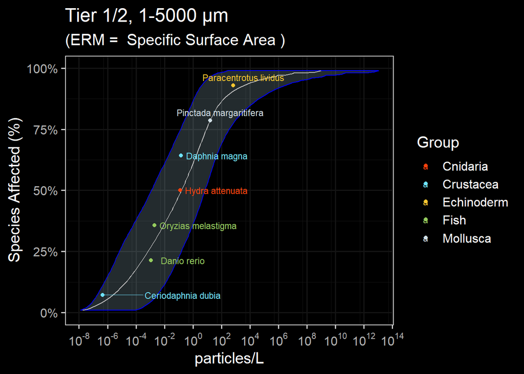

```r
###### --modelling ####
dists_tier1_2_large_1q <- ssd_fit_dists(tier1_2_large_1q, left = "Conc", dists = c("weibull", "llogis", "lnorm", "gamma", "lgumbel"), computable = FALSE, silent = FALSE)

#autoplot(dists_tier1_2_large_1q) #plots the distribution in ggplotier2
#### Goodness of fit ####
gof_tier1_2_large_1q <- as.data.frame(ssd_gof(dists_tier1_2_large_1q)) %>% mutate_if(is.numeric, ~ signif(., 3))

#### Prediction ####
set.seed(99)
pred_tier1_2_large_1q <- predict(dists_tier1_2_large_1q, average = TRUE, ic = "aicc", nboot = 10, ci= TRUE)

#order data
SSD_tier1_2_large_1q <- tier1_2_large_1q[order(tier1_2_large_1q$Conc), ]
SSD_tier1_2_large_1q$frac <- ppoints(tier1_2_large_1q$Conc, 0.5)

tier1_2_large_1q_lcl <- c(pred_tier1_2_large_1q$lcl[5]) #CI95
tier1_2_large_1q_hc5 <- c(pred_tier1_2_large_1q$est[5]) #HC5
pred_tier1_2_large_1q$est_format <-format(pred_tier1_2_large_1q$est, digits = 3, scientific = TRUE)

#ggplot
tier1_2_large_1q_ggplot <- ggplot(pred_tier1_2_large_1q,aes_string(x = "est")) +
      geom_xribbon(aes_string(xmin = "lcl", xmax = "ucl", y = "percent/100"), alpha = 0.2, color = "blue", fill = "lightblue") +
      geom_line(aes_string(y = "percent/100"), color = "gray") +
      geom_point(data = SSD_tier1_2_large_1q,aes(x = Conc, y =frac, color = Group)) +
      geom_text_repel(data = SSD_tier1_2_large_1q, aes(x = Conc, y = frac, label = Species, color = Group), nudge_x = 0.2, size = 3, segment.alpha = 0.5) +
      scale_y_continuous("Species Affected (%)", labels = scales::percent, limits = c(0,1)) +
  labs(title = "Microplastics Species Sensitivity Distribution",
             subtitle = paste("(ERM = ",ERM,")")) +
      coord_trans(x = "log10") +
      scale_x_continuous(breaks = scales::trans_breaks("log10", function(x) 10^x, n = 15),
                         labels = trans_format("log10", scales::math_format(10^.x))) +
  labs(title = "Tier 1/2, 1-5000 µm", x = "particles/L") +
      fill.type + #user-selected
      color.type + #user-selected
      theme.type #user theme

plot(tier1_2_large_1q_ggplot)
```

```r
# ###### --modelling ####
# dists_tier1_2_medium_1q <- ssd_fit_dists(tier1_2_medium_1q, left = "Conc", dists = c("weibull", "llogis", "lnorm", "gamma", "lgumbel"), computable = FALSE, silent = FALSE)
#
# #autoplot(dists_tier1_2_medium_1q) #plots the distribution in ggplotier2
# #### Goodness of fit ####
# gof_tier1_2_medium_1q <- as.data.frame(ssd_gof(dists_tier1_2_medium_1q)) %>% mutate_if(is.numeric, ~ signif(., 3))
#
# #### Prediction ####
# set.seed(99)
# pred_tier1_2_medium_1q <- predict(dists_tier1_2_medium_1q, average = TRUE, ic = "aicc", nboot = 10, ci= TRUE)
#
# #order data
# SSD_tier1_2_medium_1q <- tier1_2_medium_1q[order(tier1_2_medium_1q$Conc), ]
# SSD_tier1_2_medium_1q$frac <- ppoints(tier1_2_medium_1q$Conc, 0.5)
#
# tier1_2_medium_1q_lcl <- c(pred_tier1_2_medium_1q$lcl[5]) #CI95
# tier1_2_medium_1q_hc5 <- c(pred_tier1_2_medium_1q$est[5]) #HC5
# pred_tier1_2_medium_1q$est_format <-format(pred_tier1_2_medium_1q$est, digits = 3, scientific = TRUE)
#
# #ggplot
# tier1_2_medium_1q_ggplot <- ggplot(pred_tier1_2_medium_1q,aes_string(x = "est")) +
#       geom_xribbon(aes_string(xmin = "lcl", xmax = "ucl", y = "percent/100"), alpha = 0.2, color = "blue", fill = "lightblue") +
#       geom_line(aes_string(y = "percent/100"), color = "gray") +
#       geom_point(data = SSD_tier1_2_medium_1q,aes(x = Conc, y =frac, color = Group)) +
#       geom_text_repel(data = SSD_tier1_2_medium_1q, aes(x = Conc, y = frac, label = Species, color = Group), nudge_x = 0.2, size = 3, segment.alpha = 0.5) +
#       scale_y_continuous("Species Affected (%)", labels = scales::percent, limits = c(0,1)) +
#       coord_trans(x = "log10") +
#       scale_x_continuous(breaks = scales::trans_breaks("log10", function(x) 10^x, n = 15),
#                          labels = trans_format("log10", scales::math_format(10^.x))) +
#   labs(title = "Tier 1/2, 10-100 µm", x = "particles/L") +
#       fill.type + #user-selected
#       color.type + #user-selected
#       theme.type #user theme
#
# plot(tier1_2_medium_1q_ggplot)
```